```python
import sys, os; sys.path.insert(0, os.path.join("..", "src")) if os.path.basename(os.getcwd())=="notebooks" else sys.path.insert(0, "src")
import config, data_layer, econometrics as ek, validate, outputs
```

# FR06 — İnvestisiyalar və fiskal ötürücü blok

İnvestisiyaların strukturu və real artım sürətlərinin proqnozlaşdırılması (MİİS §15.5.1, bənd 2.4.1.5.-7.), üstəgəl büdcə kapital xərclərinin investisiyaya ötürülmə kanalı (fiskal blok və investisiya deflyatoru).

## 1. Tələb

**Spesifikasiyanın mətni (§15.5.1, FR6):** "İnvestisiyaların strukturu və real artım sürətlərinin proqnozlaşdırılması."

Tələb iki qatlıdır: (a) investisiyanın **strukturu** — daxili/xarici, dövlət/qeyri-dövlət və neft-qaz/qeyri-neft-qaz bölgüləri üzrə paylar, və (b) hər bir komponentin **real artım tempi**. Paketin memarlıq qaydasına görə (BUILD_CONTEXT §D2, §D3) bu dəftər icra DAG-ının dördüncü mərhələsindədir və FR01-in artıq həll etdiyi simultan nüvədən faydalanır.

Nüvənin investisiya tənliyi nəşr olunmuş **cəmi** investisiya artımı sırası (`inv_total_g`) üzərində qiymətləndirilib və FR01-in tələb tənliyinə də məhz cəmi investisiya artımı kimi daxil olur. Buradan bu dəftərin qapanma qaydası çıxır: **təhvil verilən cəmi investisiya yolu FR01 nüvəsinin yolunun ÖZÜdür** — `g_inv_core` 2025-ci ilin cəmi investisiya səviyyəsinə tətbiq olunur, ayrıca qiymətləndirilmir və heç bir düzəlişə məruz qalmır. Xarici investisiya (FDI) ekzogen fərziyyədir, **daxili investisiya isə qalıq kimi** alınır: daxili = cəmi − xarici.

**Bu buraxılışda dəyişən dörd şey (fiskal blok və investisiya deflyatoru).**

| Element | Əvvəlki buraxılış | Bu buraxılış |
| --- | --- | --- |
| Dövlət/qeyri-dövlət bölgüsü | son üç ilin sabit payı (56,47 %), cəmi yola vurulur | **büdcənin əsaslı vəsait qoyuluşu (DƏVQ) tənliyə daxil olur** — dövlət investisiyası tənliyinin iki termli konstruksiyası qurulur, sınağa buraxılır və çəkisi sınaqla təyin olunur |
| Neft/qeyri-neft bölgüsü | sabit pay (27,07 %) | neft-qaz blokunun fəaliyyət göstəriciləri ilə **modelləşdirilir**; sabit pay yarışda saxlanılır və nəticəsi nəşr olunur |
| Qeyri-neft × dövlət/qeyri-dövlət | **yoxdur** | `real_r102` (2018–2025) ilə qurulur; dövlət hissəsi eynilikdir |
| İnvestisiya deflyatoru | **yoxdur** — hər şey 2025 sabit qiymətləri ilə | implisit investisiya deflyatoru qurulur, Nazirliyin `eq_defid` tənliyi bizim qatda yenidən qiymətləndirilir, qazanan yol nominal körpüyə bağlanır |

Əlavə olaraq dəftər **fiskal ötürücü blokun** iki nəticəsini nəşr edir: büdcənin əsaslı vəsait qoyuluşunun (DƏVQ) sırası və dövlət büdcəsi üzrə **qeyri-neft balansı göstəricisi**. İkincisi icmal büdcə perimetri DEYİL və etiketində bu açıq yazılır (fiskal kanal 3).

## 2. Məlumat

İstifadə olunan sıralar (faktiki dəyərlər yalnız `data_layer` vasitəsilə oxunur, HƏMİŞƏ ≤ 2025 ilində bitir). Fiskal və investisiya struktur sıraları `data_layer.wb_labelled()` ilə götürülür: hər müraciətdə **vərəq, sətir və etiket** üçlüyü yoxlanılır, iş kitabının yeni buraxılışında sətir sürüşərsə blok səssizcə başqa sətri oxumur, DAYANIR.

| `series_code` | Təsvir | Vahid | Mənbə | Əhatə |
| --- | --- | --- | --- | --- |
| `inv_total`, `inv_total_g` | Əsas kapitala cəmi investisiya — səviyyə və real artım | mln AZN, % | Real sektor 80/81 | 1995–2025 / 2001–2025 |
| `inv_domestic`, `inv_foreign` | Daxili və xarici investisiya | mln AZN | Real sektor 86/92 | 2000–2025 |
| `inv_oil`, `inv_nonoil` | Neft-qaz / qeyri-neft-qaz investisiyası | mln AZN | Real sektor 82/84 | 2005–2025 |
| `inv_state`, `inv_nonstate` | Dövlət / qeyri-dövlət investisiyası | mln AZN | Real sektor 98/100 | 2000–2025 |
| **`real_r102`** | **Qeyri-dövlət qeyri-neft-qaz investisiyaları** | mln AZN | Real sektor 102 | **2018–2025 (n=8)** |
| **`real_r114`** | Müəssisə və təşkilatların öz vəsaitləri üzrə investisiya | mln AZN | Real sektor 114 | **2023–2025 (n=3)** |
| **`fiscal_r003/005/008`** | Büdcə gəlirləri: cəmi, neft-qaz, qeyri-neft-qaz | mln AZN | Fiskal sektor 3/5/8 | 2010–2025 |
| **`fiscal_r016/017/018`** | Xərclər: cəmi, cari, əsaslı | mln AZN | Fiskal sektor 16/17/18 | 2010–2025 |
| **`fiscal_r019`** | **Dövlət əsaslı vəsait qoyuluşu (DƏVQ)** | mln AZN | Fiskal sektor 19 | 2010–2025 (**2022, 2023 boş**) |
| **`dip_r004`, `dip_r004_plan`** | DƏVQ-in cəmi; 2026 üçün nəzərdə tutulmuş vəsait | mln AZN | DİP 2016-2026, sətir 4 | 2016–2025; 2026 plan |
| **`real_r005`** | Qeyri neft-qaz ÜDM, bazar qiymətləri | mln AZN | Real sektor 5 | 2000–2025 |
| `money_r029`, `cpi_infl`, `brent_usd` | M2, İQİ, Brent | mln AZN, %, USD/barel | Monetar 29; FR09; FR05 | — |

**Nazirliyin nümunə-model faylları (YALNIZ OXUNUR, modelə giriş deyil).** İki sıra dəstəkləyici sübut kimi çap olunur: MOE FISCAL.xlsx `İcmal büdcə` vərəqinin icmal perimetri (2001–2024) və MOE SNA.xlsx `Investisiya` vərəqinin investisiya deflyatorları (`DEFID`, sətir 45; xarici investisiyanın deflyatoru, sətir 49; 1998–2024). Hər ikisinin provenansı `data_layer`-dədir və hər ikisi mənbədən yenidən oxunub tutuşdurula bilir (`verify_moe_icmal_budget()`, `verify_moe_investment_deflators()`); **faktiki sütunlardan (≤2024) kənar heç nə götürülmür**, çünki həmin vərəqlərin annotasiya sətri 2025-i "gözlənilən", 2026–2030-u "proqnoz" kimi işarələyir.

Proqnoz üfüqünün girişləri paketin vahid fərziyyə dəstindən (`data/assumptions.csv`) oxunur: `g_inv_core` (FR01 nüvəsi), `cpi_infl` (FR09), `pdrv_constr` (FR02-nin tikinti-quraşdırma qiymət yolu). Bu dəftər özü üç açar qeydə alır: `inv_foreign_realg`, `state_capex_realg`, `import_price_infl`.

```python
import numpy as np
import pandas as pd

LA = config.LAST_ACTUAL
FY = list(config.FY)

inv_total   = data_layer.actuals("inv_total")
inv_total_g = data_layer.actuals("inv_total_g")
inv_dom     = data_layer.actuals("inv_domestic")
inv_dom_g   = data_layer.actuals("inv_domestic_g")
inv_for     = data_layer.actuals("inv_foreign")
inv_for_g   = data_layer.actuals("inv_foreign_g")
inv_oil     = data_layer.actuals("inv_oil")
inv_nonoil  = data_layer.actuals("inv_nonoil")
inv_state   = data_layer.actuals("inv_state")
inv_state_g = data_layer.actuals("inv_state_g")
inv_nonst   = data_layer.actuals("inv_nonstate")
inv_nonst_g = data_layer.actuals("inv_nonstate_g")
cpi         = data_layer.actuals("cpi_infl")
brent       = data_layer.actuals("brent_usd")
m2          = data_layer.wb_annual("money_r029"); m2 = m2[m2.index <= LA]

_series = [("inv_total", inv_total), ("inv_total_g", inv_total_g), ("inv_domestic", inv_dom),
           ("inv_domestic_g", inv_dom_g), ("inv_foreign", inv_for), ("inv_foreign_g", inv_for_g),
           ("inv_oil", inv_oil), ("inv_nonoil", inv_nonoil), ("inv_state", inv_state),
           ("inv_state_g", inv_state_g), ("inv_nonstate", inv_nonst), ("inv_nonstate_g", inv_nonst_g),
           ("money_r029 (M2)", m2), ("cpi_infl", cpi), ("brent_usd", brent)]
for nm, s in _series:
    print(f"{nm:<18} {int(s.index.min())}-{int(s.index.max())}  n={len(s)}")
```

```
inv_total          1995-2025  n=31
inv_total_g        2001-2025  n=25
inv_domestic       2000-2025  n=26
inv_domestic_g     2000-2025  n=26
inv_foreign        2000-2025  n=26
inv_foreign_g      2000-2025  n=26
inv_oil            2005-2025  n=21
inv_nonoil         2005-2025  n=21
inv_state          2000-2025  n=26
inv_state_g        2000-2025  n=26
inv_nonstate       2000-2025  n=26
inv_nonstate_g     2000-2025  n=26
money_r029 (M2)    2006-2025  n=20
cpi_infl           1992-2025  n=34
brent_usd          1991-2025  n=35
```

**İlkin uzlaşma yoxlaması.** İnvestisiyanın üç bölgüsü (daxili+xarici, dövlət+qeyri-dövlət, neft+qeyri-neft) ayrı-ayrı sıralardan hesablanır; onların cəmi nə dərəcədə `inv_total`-a bərabərdir?

```python
gaps = pd.DataFrame({
    "cəmi (inv_total)": inv_total,
    "daxili+xarici": inv_dom + inv_for,
    "dövlət+qeyri-dövlət": inv_state + inv_nonst,
    "neft+qeyri-neft": inv_oil + inv_nonoil,
}).dropna(subset=["cəmi (inv_total)", "daxili+xarici"])
gaps["fərq: daxili+xarici"] = gaps["cəmi (inv_total)"] - gaps["daxili+xarici"]
gaps["fərq: dövlət+q.dövlət"] = gaps["cəmi (inv_total)"] - gaps["dövlət+qeyri-dövlət"]
gaps["fərq: neft+q.neft"] = gaps["cəmi (inv_total)"] - gaps["neft+qeyri-neft"]
gaps.loc[2000:2009].round(2)
```

| year | cəmi (inv_total) | daxili+xarici | dövlət+qeyri-dövlət | neft+qeyri-neft | fərq: daxili+xarici | fərq: dövlət+q.dövlət | fərq: neft+q.neft |
| --- | --- | --- | --- | --- | --- | --- | --- |
| 2000 | 1637.96 | 967.82 | 967.82 | NaN | 670.14 | 670.14 | NaN |
| 2001 | 1998.44 | 1170.82 | 1170.82 | NaN | 827.62 | 827.62 | NaN |
| 2002 | 3739.12 | 2106.98 | 2106.98 | NaN | 1632.15 | 1632.15 | NaN |
| 2003 | 6794.34 | 3786.37 | 3786.37 | NaN | 3007.97 | 3007.97 | NaN |
| 2004 | 8840.00 | 4922.76 | 4922.76 | NaN | 3917.24 | 3917.24 | NaN |
| 2005 | 9945.90 | 5769.88 | 5769.88 | 5769.88 | 4176.03 | 4176.03 | 4176.03 |
| 2006 | 6234.48 | 6234.48 | 6234.48 | 6234.48 | 0.00 | 0.00 | -0.00 |
| 2007 | 7471.19 | 7471.19 | 7471.19 | 7471.19 | 0.00 | 0.00 | 0.00 |
| 2008 | 9944.15 | 9944.15 | 9944.15 | 9944.15 | 0.00 | 0.00 | 0.00 |
| 2009 | 7724.94 | 7724.94 | 7724.94 | 7724.94 | 0.00 | 0.00 | 0.00 |

**Tapılan uyğunsuzluq (sənədləşdirilir).** 2000–2005 illərində HƏR ÜÇ bölgünün fərqi eyni ədədə düşür (məsələn 2005-ci ildə hər üçündə 4176,03 mln AZN) və 2006-cı ildən e'tibarən fərq praktik olaraq sıfıra enir. Bu, təsadüfi deyil: `inv_total` sırası (Real sektor, sətir 80) 2000–2005 üçün komponent sıralarından (sətirlər 82/84/86/92/98/100) fərqli, daha köhnə bir buraxılışa aiddir. Üç bölgünün də təmiz, daxili şəkildə uzlaşan pəncərəsi 2006-cı ildən başlayır; bütün tarixi eynilik yoxlamaları (Bölmə 9) buna görə 2006–2025 pəncərəsi ilə aparılır. Əlavə olaraq 2025-ci ildə hər üç bölgüdə ~0,02 mln AZN (nisbi ~10⁻⁶) qalıq fərq var: `inv_total`-ın 2025 dəyəri DSK-nın rəsmi məcmu göstəricisi ilə əvəzlənib (`official` mexanizmi), komponentlər isə iş kitabının xam dəyərlərini saxlayır — eynilik yoxlaması buna görə `rel_tol=1e-5` tələb edir.

### 2.2 Fiskal blok — nəyi oxuyuruq və nəyi oxuya bilmirik

İlkin icmalın fiskal blok tapıntısı birmənalı idi: paketin əvvəlki buraxılışında **nə bir fiskal sıra, nə də bir fiskal tənlik** var idi. Məlumat isə tarixi hissə üçün tamdır. Aşağıda büdcə sıraları yüklənir və üç şey ayrıca göstərilir:

1. **DƏVQ-in birləşdirilməsi.** `fiscal_r019` illik sütunu 2022 və 2023 üçün boşdur; `DİP 2016-2026` vərəqinin 4-cü sətri həmin iki ili doldurur. Birləşdirmə YALNIZ çatışmayan illərə tətbiq olunur.
2. **İki mənbənin fərqi gizlədilmir.** Üst-üstə düşən illərdə fərq 2016–2020 və 2025-də praktik olaraq sıfırdır, lakin **2021-də −46,4 %, 2024-də −13,7 %**-dir. İki rəsmi mənbə eyni anlayış üçün fərqli rəqəm verir; bu, məlumat sorğusuna gedən bir sualdır, modelin gizlədəcəyi bir şey deyil.
3. **Qeyri-neft balansı göstəricisi.** Dövlət büdcəsi analoqu qurulur; icmal perimetri (DSMF, İSF, İTSF, Naxçıvan MR) əsas iş kitabında **yoxdur** və rəsmi "baza" düzəliş qaydası bizdə deyil. Nazirliyin öz nümunə faylının icmal sırası yanında **çarpaz yoxlama** kimi çap olunur — nəşr olunan sıra isə yalnız dövlət büdcəsi analoqudur, öz etiketi ilə.

```python
fisc = data_layer.fiscal_annual()
capex = data_layer.state_capex()                 # DİP ilə birləşdirilmiş DƏVQ
capex_gap = data_layer.state_capex_gap()

print("Dövlət büdcəsi, illik sıralar (mln AZN) — son səkkiz il:")
display(fisc.loc[LA-7:].round(1))
print()
print("DƏVQ (fiscal_r019 + DİP r4 birləşməsi), mln AZN:")
print({int(y): round(float(v), 1) for y, v in capex.items()})
print()
print("İki mənbənin üst-üstə düşən illərdəki fərqi (DÜZƏLDİLMİR — nəşr olunur):")
display(capex_gap.round(2))
print(data_layer.STATE_CAPEX_SOURCE_NOTE)
```

```
Dövlət büdcəsi, illik sıralar (mln AZN) — son səkkiz il:
```

| year | revenue_total | revenue_oil | revenue_nonoil | sofaz_transfer | exp_total | exp_current | exp_capital | state_capex_fiscal | debt_service | balance |
| --- | --- | --- | --- | --- | --- | --- | --- | --- | --- | --- |
| 2018 | 22508.9 | 13400.5 | 9108.4 | 10959.0 | 22731.6 | 11418.8 | 9077.3 | 5059.2 | 2235.6 | -222.7 |
| 2019 | 24218.1 | 13604.6 | 10613.5 | 11364.3 | 24425.9 | 13528.9 | 9372.2 | 5813.7 | 1524.8 | -207.8 |
| 2020 | 24681.7 | 14002.1 | 10679.6 | 12200.0 | 26416.3 | 16656.9 | 8033.2 | 4751.7 | 1726.2 | -1734.6 |
| 2021 | 26396.3 | 13536.2 | 12860.1 | 11350.0 | 27412.5 | 16588.3 | 8625.4 | 4683.9 | 2198.8 | -1026.1 |
| 2022 | 30679.6 | 15329.6 | 15350.0 | 7923.0 | 32063.3 | 17739.9 | 12533.0 | NaN | 1790.4 | -1384.9 |
| 2023 | 35236.4 | 18156.4 | 17080.0 | 11737.6 | 36458.5 | 19833.8 | 15442.2 | NaN | 1182.5 | -1221.6 |
| 2024 | 37161.8 | 17561.5 | 19600.3 | 12781.0 | 37719.7 | 21800.3 | 14623.8 | 3176.4 | 1295.6 | -551.8 |
| 2025 | 39184.3 | 18828.4 | 20355.9 | 14481.0 | 38603.9 | 22116.2 | 14387.9 | 2305.1 | 2099.5 | 579.3 |

```
DƏVQ (fiscal_r019 + DİP r4 birləşməsi), mln AZN:
{2010: 4132.4, 2011: 5851.6, 2012: 5763.9, 2013: 6913.8, 2014: 6256.7, 2015: 4987.5, 2016: 2685.7, 2017: 2689.3, 2018: 5059.2, 2019: 5813.7, 2020: 4751.7, 2021: 4683.9, 2022: 3284.6, 2023: 2660.4, 2024: 3176.4, 2025: 2305.1}

İki mənbənin üst-üstə düşən illərdəki fərqi (DÜZƏLDİLMİR — nəşr olunur):
```

| year | fiscal_r019 | dip_r004 | fərq | fərq_% |
| --- | --- | --- | --- | --- |
| 2016 | 2685.75 | 2685.75 | 0.00 | 0.00 |
| 2017 | 2689.30 | 2689.30 | 0.00 | 0.00 |
| 2018 | 5059.20 | 5063.64 | 4.44 | 0.09 |
| 2019 | 5813.70 | 5813.67 | -0.03 | -0.00 |
| 2020 | 4751.70 | 4747.84 | -3.86 | -0.08 |
| 2021 | 4683.90 | 2510.62 | -2173.28 | -46.40 |
| 2024 | 3176.40 | 2741.60 | -434.80 | -13.69 |
| 2025 | 2305.10 | 2305.12 | 0.02 | 0.00 |

```
fiscal_r019 (Fiskal sektor, 4 vərəq sətir 19); 2022 və 2023 illəri `DİP 2016-2026` vərəqinin 4-cü sətrindən doldurulub. 2025-ci ildə iki mənbə üst-üstə düşür (2 305,1 mln AZN), 2021 və 2024-cü illərdə isə fərqlənir — fərq gizlədilmir, `state_capex_gap()` ilə çap olunur.
```

```python
# DÖVLƏT İNVESTİSİYASI TƏNLİYİNİN ÖZ SÜBUTU: büdcə kapital xərclərinin dövlət investisiyasındakı payı (büdcə kapital xərclərinin ötürülmə kanalı).
share_capex = (capex / inv_state.reindex(capex.index) * 100).dropna().rename("DƏVQ / dövlət investisiyası, %")
print("Büdcənin əsaslı vəsait qoyuluşunun dövlət investisiyasındakı payı:")
print(share_capex.round(1).to_string())
print()
print(f"2018: {share_capex.loc[2018]:.1f} %  →  2019: {share_capex.loc[2019]:.1f} %  →  "
      f"2022: {share_capex.loc[2022]:.1f} %  →  2023: {share_capex.loc[2023]:.1f} %  →  "
      f"2025: {share_capex.loc[2025]:.1f} %")
print("Yəni büdcə capex-i dövlət investisiyasının ARTIQ əsas hissəsi deyil: 2018-ci ildə üçdə "
      "ikisi, 2025-ci ildə beşdə biri. Tənlik buna görə İKİ termli qurulur.")
```

```
Büdcənin əsaslı vəsait qoyuluşunun dövlət investisiyasındakı payı:
year
2010    68.9
2011    73.8
2012    61.2
2013    64.9
2014    68.6
2015    85.8
2016    51.2
2017    42.2
2018    60.0
2019    66.0
2020    55.7
2021    61.0
2022    35.1
2023    22.4
2024    23.8
2025    20.4

2018: 60.0 %  →  2019: 66.0 %  →  2022: 35.1 %  →  2023: 22.4 %  →  2025: 20.4 %
Yəni büdcə capex-i dövlət investisiyasının ARTIQ əsas hissəsi deyil: 2018-ci ildə üçdə ikisi, 2025-ci ildə beşdə biri. Tənlik buna görə İKİ termli qurulur.
```

```python
# DÖVLƏT İNVESTİSİYASI TƏNLİYİNİN İKİNCİ TERMİ — TAM TARİXÇƏ (bu buraxılış).
# Əvvəlki buraxılışda bu term qiymətləndirilə bilmirdi: iş kitabının `real_r114` sətrinin illik
# sütunu yalnız 2023-2025 üçün dolu idi (n=3), fərqlər alındıqda n=2 qalırdı.
# `DATA_GAP_NEGATIVE_PROOF.md` (x) bəndi eyni anlayışın tam tarixçəsini opendata.az-ın
# «Maliyyə mənbələri üzrə əsas kapitala yönəldilmiş investisiyalar» resursunda tapdı.
# `own_funds_investment_annual()` iki sıranı birləşdirir və üst-üstə düşən illərdə DƏQİQ
# uyğunluğu HƏR ÇAĞIRIŞDA yoxlayır (pozularsa icra dayanır) — miqyaslama tələb olunmur.
soe_wb = data_layer.soe_investment_annual()            # iş kitabı, real_r114 (2023-2025)
soe = data_layer.own_funds_investment_annual()         # BİRLƏŞDİRİLMİŞ sıra, 1999-2025

print("Öz vəsaitləri ilə əsas kapitala investisiya (mln AZN):")
print(pd.DataFrame({"birləşdirilmiş sıra": soe, "iş kitabı (real_r114)": soe_wb,
                    "açıq mənbə (opendata.az)": data_layer.public_series("inv_own_funds")})
      .round(1).to_string())
_ov = sorted(set(soe_wb.index) & set(data_layer.public_series("inv_own_funds").index))
print()
print(f"üst-üstə düşən illər: {_ov} — maks. |fərq| = "
      f"{float((soe_wb.loc[_ov] - data_layer.public_series('inv_own_funds').loc[_ov]).abs().max()):.6f} mln AZN")
print(f"illik müşahidə sayı: əvvəl {len(soe_wb)} → indi {len(soe)} "
      f"({int(soe.index.min())}-{int(soe.index.max())})")
print()
print("QEYD (etiket dəqiqliyi DƏYİŞMİR): sıra BÜTÜN müəssisələri əhatə edir — maliyyələşmə")
print("mənbəyi üzrə bölgüdür, mülkiyyət üzrə deyil; 'SOE' etiketi ona tam uyğun gəlmir.")
print()
# Strateji Layihələr vərəqi: yarımillik layihə STOKU — axın deyil, ona görə tənliyə girmir.
try:
    _sl = data_layer.wb_labelled("dip_r009")
    print("Xarici kreditor qurumlarla birgə maliyyələşmə (DİP r9), mln AZN:",
          {int(y): round(float(v), 1) for y, v in _sl.items()})
except Exception as _e:
    print("DİP r9 oxunmadı:", _e)
```

```
Öz vəsaitləri ilə əsas kapitala investisiya (mln AZN):
      birləşdirilmiş sıra  iş kitabı (real_r114)  açıq mənbə (opendata.az)
1999                653.6                    NaN                     653.6
2000                689.2                    NaN                     689.2
2001                954.2                    NaN                     954.2
2002               1746.9                    NaN                    1746.9
2003               3108.1                    NaN                    3108.1
2004               4213.7                    NaN                    4213.7
2005               4767.0                    NaN                    4767.0
2006               4407.6                    NaN                    4407.6
2007               4470.7                    NaN                    4470.7
2008               4730.3                    NaN                    4730.3
2009               3811.3                    NaN                    3811.3
2010               5041.9                    NaN                    5041.9
2011               5760.5                    NaN                    5760.5
```

[output cut: 22 more lines]

```python
# QEYRİ-NEFT BALANSI GÖSTƏRİCİSİ — dövlət büdcəsi analoqu (fiskal kanal 3)
nob = data_layer.nonoil_base_balance()
print("Etiket:", data_layer.NONOIL_BASE_LABEL_AZ)
display(nob.loc[2015:].round(2))

# ÇARPAZ YOXLAMA (modelə daxil deyil): Nazirliyin nümunə faylındakı icmal perimetri
icmal = data_layer.moe_icmal_budget()
cross = pd.DataFrame({
    "dövlət büdcəsi analoqu, %": nob["ratio_nonoil_gdp"],
    "MOE icmal perimetri, % (nümunə fayl)": icmal["ratio_nonoil_gdp"],
}).dropna()
print()
print("Çarpaz yoxlama — iki perimetr, qeyri-neft ÜDM-ə nisbətdə (%):")
display(cross.round(2))
print(data_layer.MOE_ICMAL_SOURCE_NOTE)
print()
print(f"Orta mütləq fərq (2015-2024): {float((cross.iloc[:, 0] - cross.iloc[:, 1]).abs().mean()):.2f} f.b. "
      "— iki perimetr eyni böyüklük sırasındadır, lakin EYNİ DEYİL; ona görə nəşr olunan sıra "
      "yalnız dövlət büdcəsi analoqudur və etiketində icmal perimetrinin gözlənildiyi yazılır.")
```

```
Etiket: dövlət büdcəsi üzrə qeyri-neft balansı / qeyri-neft ÜDM (icmal büdcə perimetri və rəsmi 'baza' düzəlişi təqdim olunduqdan sonra yenilənəcək)
```

| year | revenue_nonoil | expenditure | gdp_nonoil | balance | ratio_nonoil_gdp |
| --- | --- | --- | --- | --- | --- |
| 2015 | 7278.10 | 17784.50 | 37920.4 | -10506.40 | -27.71 |
| 2016 | 8280.65 | 17751.30 | 39975.8 | -9470.65 | -23.69 |
| 2017 | 8632.70 | 17594.50 | 44311.8 | -8961.80 | -20.22 |
| 2018 | 9108.44 | 22731.64 | 46702.6 | -13623.20 | -29.17 |
| 2019 | 10613.50 | 24425.90 | 50650.2 | -13812.40 | -27.27 |
| 2020 | 10679.60 | 26416.30 | 51131.5 | -15736.70 | -30.78 |
| 2021 | 12860.05 | 27412.50 | 57432.4 | -14552.45 | -25.34 |
| 2022 | 15350.00 | 32063.30 | 69764.1 | -16713.30 | -23.96 |
| 2023 | 17080.00 | 36458.50 | 78990.3 | -19378.50 | -24.53 |
| 2024 | 19600.30 | 37719.70 | 86240.8 | -18119.40 | -21.01 |
| 2025 | 20355.90 | 38603.90 | 92307.1 | -18248.00 | -19.77 |

```
Çarpaz yoxlama — iki perimetr, qeyri-neft ÜDM-ə nisbətdə (%):
```

|  | dövlət büdcəsi analoqu, % | MOE icmal perimetri, % (nümunə fayl) |
| --- | --- | --- |
| 2015 | -27.71 | -45.93 |
| 2016 | -23.69 | -25.17 |
| 2017 | -20.22 | -27.76 |
| 2018 | -29.17 | -33.38 |
| 2019 | -27.27 | -27.27 |
| 2020 | -30.78 | -29.86 |
| 2021 | -25.34 | -23.67 |
| 2022 | -23.96 | -22.38 |
| 2023 | -24.53 | -22.15 |
| 2024 | -21.01 | -20.12 |

```
MOE FISCAL.xlsx, `İcmal büdcə` vərəqi: sətir 4 (icmal gəlirlər), 12 (icmal xərclər), 21 (kəsir/profisit), 38 (qeyri-neft büdcə gəlirləri), 39 (qeyri-neft icmal baza kəsiri), 41 (baza kəsirinin qeyri-neft ÜDM-ə nisbəti); Nazirliyin nümunə-model faylı — YALNIZ OXUNUR, yalnız faktiki sütunlar (≤2024), …

Orta mütləq fərq (2015-2024): 3.89 f.b. — iki perimetr eyni böyüklük sırasındadır, lakin EYNİ DEYİL; ona görə nəşr olunan sıra yalnız dövlət büdcəsi analoqudur və etiketində icmal perimetrinin gözlənildiyi yazılır.
```

## 3. Model seçimi

### 3.1 Cəmi investisiya — FR01 nüvəsinin yolu, düzəlişsiz

FR01-in simultan nüvəsi (§D3) dörd tənlikdən ibarətdir; onlardan biri — kredit kanalı vasitəsilə investisiyanın real artımını izah edən tənlik — bilavasitə bu dəftərin mövzusudur. Tənlik nəşr olunmuş **cəmi** investisiya artımı sırası (`inv_total_g`, 2001–2025) üzərində qiymətləndirilib və FR01-in tələb tənliyinə də cəmi investisiya artımı kimi daxil olur. Ona görə burada həmin yol **cəmi** investisiyaya tətbiq edilir. Bu, seçim deyil, uyğunluq tələbidir.

### 3.2 Xarici investisiya — ekzogen, Nazirliyin REAL artım yolu ilə

Geriyə doğru sınaq AR(1), beş-illik orta və neft qiymətinə əsaslanan modelləri RW etalonuna qarşı sınaqdan keçirir; ən yaxşı sağ qalan ansambl RW-ni cəmi ~11 % üstələyir, bu isə ~27–30 f.b. mütləq RMSE-yə nisbətdə praktik əhəmiyyətsizdir. Xarici investisiya Azərbaycanda iri, kəsilməz olmayan neft-qaz layihələrinin cədvəli ilə idarə olunur — bir dəyişənli zaman sırası modelinin tuta bilmədiyi məlumatdır. Ona görə mərkəzi yol Nazirliyin öz FDI layihə baza ssenarisi əsasında **ekzogen fərziyyə** kimi qəbul edilir.

**Vintaj düzəlişi.** Şablon iki sətir verir: nominal **səviyyə** (sətir 16) və **real artım tempi** (sətir 17). Səviyyə sütunu Nazirliyin öz 2025 qiymətləndirməsi üzərində qurulub: 2026 üçün 6 080,1 mln AZN həmin ilin +16,4 % real artımı ilə 5 222,6 mln AZN-lik implisit 2025 bazası verir, iş kitabının nəşr olunmuş 2025 dəyəri isə 4 203,0 mln AZN-dir — **vintaj fərqi 24,3 %**. Nominal səviyyəni faktiki dəyərin üzərinə zəncirləmək 2026 üçün +44,7 %-lik saxta "real artım" yaradardı. Ona görə **real artım tempi** sətri götürülür və iş kitabının öz 2025 səviyyəsinə tətbiq olunur.

### 3.3 Daxili investisiya — qalıq

Daxili = cəmi − xarici (hər ikisi 2025 sabit qiymətləri ilə). Tənlik cəmi sıra üzərində qiymətləndirilib, ona görə cəmi sıraya tətbiq olunur; FDI-ın öz layihə cədvəli var, ona görə ekzogendir; qalan hissə isə qalıqdır.

### 3.4 Dövlət/qeyri-dövlət — dövlət investisiyası tənliyinin iki termli konstruksiyası

Əvvəlki buraxılışda pay sabit idi (son üç ilin ortası). İcmal büdcə kapital xərclərinin tənliyə daxil edilməsini tələb edir. Bölmə 2.2-nin sübutu göstərir ki, **tək başına** DƏVQ artıq kifayət deyil: onun dövlət investisiyasındakı payı 2018-ci ildəki 60 %-dən 2025-ci ildə 20,4 %-ə enib. Ona görə iki termli forma qurulur:

```
Δln I^dövlət = α + β₁·Δln(DƏVQ, real) + β₂·Δln(SOE öz vəsaitləri, real) + ε
```

**İkinci term BU BURAXILIŞDA qiymətləndirilir (bu buraxılış).** Əvvəlki buraxılışda `real_r114`-ün illik sütunu yalnız 2023–2025 üçün dolu idi (n = 3) və D5-in nümunə intizamına görə həmin sıra üzərində elastiklik nəşr edilmirdi. Açıq mənbə sweep-i eyni anlayışın **1999–2024 tarixçəsini** tapdı (opendata.az, maliyyə mənbələri üzrə investisiyalar); iki sıra üst-üstə düşən iki ildə **dəqiq eynidir**, ona görə birləşdirilmiş sıra 1999–2025 dövrünü əhatə edir və term artıq qiymətləndirilə biləndir. Beləliklə:

- **birinci term** (DƏVQ) tam qiymətləndirilir və **qapıdan** keçirilir (p < 0,10 və düzgün işarə);
- **ikinci term** iki formada verilir: (a) əsl `öz vəsaitləri` sırası ilə — iki termli formanın nəzərdə tutduğu forma, artıq **nəşr olunan əmsalla**; (b) əvvəlki buraxılışın sənədləşdirilmiş ƏVƏZEDİCİsi ilə — neft-qaz sektoruna investisiya (`real_r082`), müqayisə üçün saxlanılır;
- hər iki forma eyni pəncərədə, eyni etalona qarşı **yarışa** buraxılır və nəticə — udmasından asılı olmayaraq — həm tənlik kataloqunda, həm sınaq cədvəlində qalır.

**Nümunəni məhdudlaşdıran indi öz vəsait sırası deyil, DƏVQ-dir:** büdcənin əsaslı vəsait qoyuluşu sırası 2010-cu ildən başlayır, ona görə iki termli tənliyin ortaq nümunəsi n = 15-dir. Öz vəsait termi TƏK BAŞINA isə tam 26 illik nümunədə qiymətləndirilir və nəticəsi ayrıca göstərilir.

Qərar yenə sınağındır: dövlət investisiyası tənliyi, v2-nin üç illik pay qaydası, AR(1), beş-illik orta və təsadüfi gəzişmə eyni pəncərədə yarışır; mərkəzi yolu ansambl daşıyır və **hər modelin çəkisi sınaqdan gəlir**, iqtisadi mülahizədən yox.

### 3.5 Neft/qeyri-neft — sabit pay yarışa buraxılır

Əvvəlki buraxılışda pay sabit idi (27,07 %). Bu buraxılışda neft-qaz sektoruna investisiyanın öz real artımı **neft-qaz blokunun fəaliyyət göstəriciləri** ilə izah edilməyə çalışılır: çəkili neft+qaz ixrac qiyməti indeksi (`oilgas_pw_g`), əmtəəlik həcm indeksi (`oil_realg`) və Brent. Gözlənilən işarə **müsbətdir** (qiymət/fəaliyyət artdıqca investisiya artır) — bu, qapının bir hissəsidir və nəticə nə olursa olsun dəyişdirilmir. Sabit pay qaydası da eyni yarışa girir.

### 3.6 İnvestisiya deflyatoru (investisiyanın ayrıca qiymət indeksi)

İcmal investisiyanın ayrıca qiymət indeksinin olmamasını qeyd edir. Bu buraxılışda:

- **hədəf sıra bizim öz qatımızda qurulur** — `real_r080` (nominal səviyyə) və `real_r081` (əvvəlki il = 100 real indeks) qonşu sətirlərindən implisit deflyator. 2016-cı il dəyəri **26,24 %** MOE SNA `Investisiya` vərəqinin öz "deflyator" sətri ilə (26,23964) beş onluq rəqəmə qədər üst-üstə düşür — yəni boşluq bizim qatda bağlanır;
- **Nazirliyin `eq_defid` tənliyi olduğu kimi qəbul edilir və yenidən qiymətləndirilir**: öz gecikməsi + gecikmiş NEER + rejim sabitləri;
- **tikinti deflyatoru ilə idxal qiymətlərinin çəkili düsturu** — `w_c·(tikinti-quraşdırma deflyatoru) + (1−w_c)·(idxal qiymətləri)`, `w_c` = tikinti işlərinin cəmi investisiyadakı payı — həm **tətbiq olunmuş çəki** ilə, həm də **qiymətləndirilmiş çəki** ilə yarışa daxil edilir;
- qazanan yol nominal körpüyə bağlanır: `inv_total_nom` üçün proqnoz sətirləri ilk dəfə nəşr olunur və `price_basis` sütunu hər sırada öz bazasını elan edir.

### 3.7 Qeyri-neft × dövlət/qeyri-dövlət — dövlət investisiyası tənliyinin "yoxdur" cavabı

Rəy bu kəsişmənin olmadığını yazır. Kəsişmə **qurulur**: `real_r102` (Qeyri-dövlət qeyri-neft-qaz investisiyaları) 2018–2025 üçün boşluqsuzdur, dövlət hissəsi isə eyniliklə `real_r084 − real_r102` (məsələn 2025: 15 886,5 − 5 422,5 = 10 464,0). Səkkiz müşahidə qısa nümunədir (1.2.4/D5), ona görə qısa tənlik və sabit pay qaydası yarışdırılır və pəncərə uzunluğu hər yerdə göstərilir.

## 4. Testlər

Aşağıda investisiya artım templərinin, pay sıralarının və kredit kanalının reqressoru olan real M2 artımının stasionarlıq sınaqları göstərilir. Qeyd: bu tənliklər səviyyə reqressiyası deyil (asılı dəyişənlər artıq real artım tempi kimi ölçülüb), ona görə kointeqrasiya sınağı tələb olunmur.

```python
sh_state_full = (inv_state / inv_total * 100).dropna()
sh_state = sh_state_full.loc[2006:]
sh_oil = (inv_oil / inv_total * 100).dropna()

print(ek.adf(inv_total_g, "cəmi investisiyanın real artımı, 2001-2025", maxlag=2))
print(ek.adf(inv_dom_g, "daxili investisiyanın real artımı, 2000-2025", maxlag=2))
print(ek.adf(inv_for_g, "xarici investisiyanın real artımı, 2000-2025", maxlag=2))
print(ek.adf(inv_state_g, "dövlət investisiyasının real artımı, 2000-2025", maxlag=2))
print(ek.adf(sh_state, "dövlətin investisiyada payı, 2006-2025", maxlag=2))
print(ek.adf(sh_oil, "neftin investisiyada payı, 2005-2025", maxlag=2))

print()
print(f"korrelyasiya, inv_total_g və inv_domestic_g (2001-2025): "
      f"{inv_total_g.corr(inv_dom_g.reindex(inv_total_g.index)):.3f}")
```

```
ADF[cəmi investisiyanın real artımı, 2001-2025] stat=-2.396 p=0.1430 lag=0 n=24 kritik(1%: -3.74, 10%: -2.64, 5%: -2.99) → vahid kök
ADF[daxili investisiyanın real artımı, 2000-2025] stat=-2.764 p=0.0636 lag=0 n=25 kritik(1%: -3.72, 10%: -2.63, 5%: -2.99) → vahid kök
ADF[xarici investisiyanın real artımı, 2000-2025] stat=-2.652 p=0.0827 lag=0 n=25 kritik(1%: -3.72, 10%: -2.63, 5%: -2.99) → vahid kök
ADF[dövlət investisiyasının real artımı, 2000-2025] stat=-2.764 p=0.0636 lag=0 n=25 kritik(1%: -3.72, 10%: -2.63, 5%: -2.99) → vahid kök
ADF[dövlətin investisiyada payı, 2006-2025] stat=-2.441 p=0.1304 lag=1 n=18 kritik(1%: -3.86, 10%: -2.66, 5%: -3.04) → vahid kök
ADF[neftin investisiyada payı, 2005-2025] stat=-1.582 p=0.4924 lag=2 n=18 kritik(1%: -3.86, 10%: -2.66, 5%: -3.04) → vahid kök

korrelyasiya, inv_total_g və inv_domestic_g (2001-2025): 0.671
```

Nəticə: bütün sıralar üçün ADF vahid kökü rədd ETMİR (kiçik nümunədə sınağın gücü zəifdir). Artım templərinin və payların iqtisadi mənada sonsuza qədər sürüşməsi mümkün olmadığından bu, HAC-lı OLS-in tətbiqinə maneə yaratmır — sadəcə HAC (Newey–West) standart xətaları mütləq işlədilir.

## 5. Qiymətləndirmə

### 5.1 Cəmi investisiya — kredit kanalı

FR01-in konstruksiyasını təkrarlayaraq real M2 kütləsinin İQİ-yə görə deflyasiya edilmiş artımı (`dlrm2` = Δln(M2/İQİ) × 100) qurulur; 2015–2016 devalvasiyası üçün süni dəyişən (`d15`) əlavə olunur.

```python
cpi_ix = pd.Series(dtype=float); cpi_ix.loc[2015] = 1.0
for y in range(2016, LA + 1):
    cpi_ix.loc[y] = cpi_ix.loc[y - 1] * (1 + cpi.loc[y] / 100.0)
for y in range(2014, int(cpi.index.min()) - 1, -1):
    if (y + 1) in cpi.index:
        cpi_ix.loc[y] = cpi_ix.loc[y + 1] / (1 + cpi.loc[y + 1] / 100.0)
cpi_ix = cpi_ix.sort_index()

dlrm2 = (np.log(m2 / cpi_ix.reindex(m2.index)).diff() * 100).rename("dlrm2")

d15 = pd.Series(0.0, index=range(1995, config.LAST_FORECAST + 1), name="d15")
d15.loc[[2015, 2016]] = 1.0

S = pd.DataFrame({"y": inv_total_g, "dlrm2": dlrm2, "dlrm2_l1": dlrm2.shift(1), "d15": d15}).loc[2000:LA]
S.round(2)
```

|  | y | dlrm2 | dlrm2_l1 | d15 |
| --- | --- | --- | --- | --- |
| 2000 | NaN | NaN | NaN | 0.0 |
| 2001 | 21.0 | NaN | NaN | 0.0 |
| 2002 | 80.0 | NaN | NaN | 0.0 |
| 2003 | 79.7 | NaN | NaN | 0.0 |
| 2004 | 30.0 | NaN | NaN | 0.0 |
| 2005 | 17.2 | NaN | NaN | 0.0 |
| 2006 | 8.1 | NaN | NaN | 0.0 |
| 2007 | 19.8 | 56.89 | NaN | 0.0 |
| 2008 | 31.8 | 13.42 | 56.89 | 0.0 |
| 2009 | -18.4 | -0.05 | 13.42 | 0.0 |
| 2010 | 21.2 | 24.09 | -0.05 | 0.0 |
| 2011 | 27.3 | 20.57 | 24.09 | 0.0 |
| 2012 | 18.5 | 21.66 | 20.57 | 0.0 |
| 2013 | 15.1 | 15.06 | 21.66 | 0.0 |
| 2014 | -1.7 | 4.52 | 15.06 | 0.0 |
| 2015 | -11.1 | -73.69 | 4.52 | 1.0 |
| 2016 | -21.7 | 16.86 | -73.69 | 1.0 |
| 2017 | 2.8 | -4.47 | 16.86 | 0.0 |
| 2018 | -4.3 | 13.82 | -4.47 | 0.0 |
| 2019 | 5.5 | 19.39 | 13.82 | 0.0 |
| 2020 | -7.3 | 8.01 | 19.39 | 0.0 |
| 2021 | -4.5 | 9.71 | 8.01 | 0.0 |
| 2022 | 3.3 | 8.36 | 9.71 | 0.0 |
| 2023 | 15.2 | 9.50 | 8.36 | 0.0 |
| 2024 | 2.4 | 1.38 | 9.50 | 0.0 |
| 2025 | -5.6 | 4.27 | 1.38 | 0.0 |

```python
sI = S.loc[2008:LA]
res_inv = ek.ols_hac(sI["y"], sI[["dlrm2", "dlrm2_l1", "d15"]], maxlags=1,
                     name="STRUKTUR: kredit kanalı, gecikməli, süni dəyişənli (istifadə olunur)")

sIu = S.loc[2007:LA].dropna(subset=["y", "dlrm2"])
res_inv_nd = ek.ols_hac(sIu["y"], sIu[["dlrm2"]], maxlags=1,
                        name="ROBUSTLİK: süni dəyişənsiz, gecikməsiz")
res_inv_d = ek.ols_hac(sIu["y"], sIu[["dlrm2", "d15"]], maxlags=1,
                       name="ROBUSTLİK: süni dəyişənli, gecikməsiz")

sIx = sIu.drop(index=[y for y in (2015, 2016) if y in sIu.index])
res_inv_x = ek.ols_hac(sIx["y"], sIx[["dlrm2"]], maxlags=1,
                       name="ROBUSTLİK: 2015-2016 nümunədən çıxarılıb, süni dəyişənsiz")

print(res_inv); print()
print(res_inv_nd); print()
print(res_inv_d); print()
print(res_inv_x)
```

```
[OLS+HAC] STRUKTUR: kredit kanalı, gecikməli, süni dəyişənli (istifadə olunur): n=18, nümunə=2008–2025, R²=0.661, düzəldilmiş R²=0.589, s.x.=9.6636
[OLS+HAC] ROBUSTLİK: süni dəyişənsiz, gecikməsiz: n=19, nümunə=2007–2025, R²=0.213, düzəldilmiş R²=0.167, s.x.=13.7811
[OLS+HAC] ROBUSTLİK: süni dəyişənli, gecikməsiz: n=19, nümunə=2007–2025, R²=0.294, düzəldilmiş R²=0.205, s.x.=13.4573
[OLS+HAC] ROBUSTLİK: 2015-2016 nümunədən çıxarılıb, süni dəyişənsiz: n=17, nümunə=2007–2025, R²=0.317, düzəldilmiş R²=0.271, s.x.=11.7978
OLS+HAC[STRUKTUR: kredit kanalı, gecikməli, süni dəyişənli (istifadə olunur)]  n=18  nümunə=2008–2025  HAC gecikmə=1
  R²=0.661  düzəldilmiş R²=0.589  reqressiyanın s.x.=9.6636
  dəyişən                əmsal    HAC s.x.        t        p
  const                -8.9679      3.3027    -2.72    0.007
  dlrm2                 0.5522      0.1391     3.97    0.000
  dlrm2_l1              0.6462      0.0743     8.69    0.000
  d15                  30.6056      8.7950     3.48    0.001

OLS+HAC[ROBUSTLİK: süni dəyişənsiz, gecikməsiz]  n=19  nümunə=2007–2025  HAC gecikmə=1
  R²=0.213  düzəldilmiş R²=0.167  reqressiyanın s.x.=13.7811
  dəyişən                əmsal    HAC s.x.        t        p
  const                 2.0477      2.5596     0.80    0.424
  dlrm2                 0.2918      0.1019     2.86    0.004

OLS+HAC[ROBUSTLİK: süni dəyişənli, gecikməsiz]  n=19  nümunə=2007–2025  HAC gecikmə=1
  R²=0.294  düzəldilmiş R²=0.205  reqressiyanın s.x.=13.4573
  dəyişən                əmsal    HAC s.x.        t        p
  const                 4.8185      3.6614     1.32    0.188
  dlrm2                 0.1733      0.1739     1.00    0.319
  d15                 -16.2948     10.5775    -1.54    0.123

OLS+HAC[ROBUSTLİK: 2015-2016 nümunədən çıxarılıb, süni dəyişənsiz]  n=17  nümunə=2007–2025  HAC gecikmə=1
  R²=0.317  düzəldilmiş R²=0.271  reqressiyanın s.x.=11.7978
  dəyişən                əmsal    HAC s.x.        t        p
  const                -0.3676      3.7235    -0.10    0.921
  dlrm2                 0.5632      0.2228     2.53    0.011
```

### 5.2 2015 hekayəsi

Dörd spesifikasiya bir yerdə oxunanda 2015–2016 devalvasiyasının kredit kanalına təsiri aydın görünür. 2015-ci ildə real M2 kütləsi 74 f.b.-ə yaxın kəskin **daralıb** (`dlrm2` = −73,7), halbuki investisiya artımı bundan qat-qat az kəskin düşüb (−11,1 %). Gecikməli, süni dəyişənli spesifikasiya bu uyğunsuzluğu düzgün idarə edən yeganə formadır: `dlrm2` əmsalı 0,552, gecikmiş həddi 0,646, süni dəyişən +30,61 — hamısı 1 % səviyyəsində əhəmiyyətlidir. Gecikmə həddi çıxarıldıqda əmsal 0,292-yə, düzəldilmiş R² 0,167-yə enir; süni dəyişən gecikməsiz daxil edildikdə isə işarəsi tərsinə dönür. 2015–2016 nümunədən tamamilə çıxarıldıqda əmsal 0,563-ə qayıdır — yəni devalvasiya illərini ya düzgün gecikmə strukturu ilə, ya da nümunədən çıxarmaqla idarə etmək olar; onları naiv şəkildə daxil etmək əmsalı qeyri-sabit edir.

```python
from IPython.display import Math, display


def _eq_latex(res, labels, lhs):
    body = ""
    for i, nm in enumerate(res.exog_names):
        b, se, lab = res.params[nm], res.se[nm], labels[nm]
        pre = ("-" if b < 0 else "") if i == 0 else (" - " if b < 0 else " + ")
        term = f"{abs(b):.3f}" + ("" if lab == "" else r"\," + lab)
        body += pre + r"\underset{(" + f"{se:.3f}" + r")}{" + term + "}"
    return lhs + " = " + body


LBL = {"const": "", "dlrm2": r"\Delta\ln(M2/P)_t", "dlrm2_l1": r"\Delta\ln(M2/P)_{t-1}",
       "d15": r"D^{15\text{-}16}_t"}
display(Math(_eq_latex(res_inv, LBL, r"\hat{g}^{I}_t")))
print(f"n = {res_inv.n},  nümunə = {res_inv.sample[0]}–{res_inv.sample[1]},  "
      f"düzəldilmiş R² = {res_inv.adj_r2:.3f},  reqressiyanın standart xətası = {res_inv.sigma:.3f}")
print("mötərizədə HAC (Newey–West, gecikmə 1) standart xətaları verilib.")
```

$\displaystyle \hat{g}^{I}_t = -\underset{(3.303)}{8.968} + \underset{(0.139)}{0.552\,\Delta\ln(M2/P)_t} + \underset{(0.074)}{0.646\,\Delta\ln(M2/P)_{t-1}} + \underset{(8.795)}{30.606\,D^{15\text{-}16}_t}$

```
n = 18,  nümunə = 2008–2025,  düzəldilmiş R² = 0.589,  reqressiyanın standart xətası = 9.664
mötərizədə HAC (Newey–West, gecikmə 1) standart xətaları verilib.
```

### 5.3 Dövlət investisiyası — iki termli tənlik

```python
def real_g(s):
    """nominal səviyyə sırasını İQİ ilə deflyasiya edib real artım tempinə (%) çevirir"""
    s = pd.Series(s).astype(float).dropna().sort_index()
    g = (s / s.shift(1) - 1) * 100
    return (((1 + g / 100) / (1 + cpi.reindex(g.index) / 100) - 1) * 100).dropna()


def _cut(s):
    s = pd.Series(s).astype(float).sort_index()
    return s[s.index <= LA]


g_capex = real_g(capex).rename("g_capex")                       # dövlət investisiyası tənliyinin birinci termi
g_oilinv = real_g(_cut(data_layer.wb_labelled("real_r082"))).rename("g_oilinv")
g_soe = real_g(soe).rename("g_soe")                             # dövlət investisiyası tənliyinin ikinci termi — TAM tarixçə (1999-2025)

ST = pd.DataFrame({"y": inv_state_g, "devq_realg": g_capex, "neftinv_realg": g_oilinv, "oz_vesait_realg": g_soe,
                   "d15": d15, "gtot": inv_total_g}).loc[:LA]

_s1 = ST[["y", "devq_realg"]].dropna()
res_st1 = ek.ols_hac(_s1["y"], _s1[["devq_realg"]], maxlags=1,
                     name="DİT-1: dövlət investisiyası ~ DƏVQ (real)")
_s2 = ST[["y", "devq_realg", "d15"]].dropna()
res_st2 = ek.ols_hac(_s2["y"], _s2[["devq_realg", "d15"]], maxlags=1,
                     name="DİT-2 (istifadə olunur): DƏVQ + 2015-16 süni dəyişəni")
_s3 = ST[["y", "devq_realg", "neftinv_realg"]].dropna()
res_st3 = ek.ols_hac(_s3["y"], _s3[["devq_realg", "neftinv_realg"]], maxlags=1,
                     name="DİT-3: iki termli — DƏVQ + neft-qaz investisiyası (əvəzedici)")
print(res_st1); print()
print(res_st2); print()
print(res_st3); print()
_s4 = ST[["y", "devq_realg", "oz_vesait_realg"]].dropna()
res_st4 = ek.ols_hac(_s4["y"], _s4[["devq_realg", "oz_vesait_realg"]], maxlags=1,
                     name="DİT-4: iki termli — DƏVQ + ÖZ VƏSAİTLƏRİ (iki termli formanın əsl variantı)")
print(res_st4); print()
_s5 = ST[["y", "oz_vesait_realg"]].dropna()
res_st5 = ek.ols_hac(_s5["y"], _s5[["oz_vesait_realg"]], maxlags=1,
                     name="DİT-5: yalnız öz vəsaitləri — TAM nümunə (DƏVQ ilə məhdudlaşmır)")
print(res_st5)
print()
print(f"Nümunə ölçüləri: iki termli n = {len(_s4)} ({int(_s4.index.min())}-{int(_s4.index.max())}, "
      f"DƏVQ sırası ilə məhdudlaşır); yalnız öz vəsaitləri n = {len(_s5)} "
      f"({int(_s5.index.min())}-{int(_s5.index.max())}).")
```

```
[OLS+HAC] DİT-1: dövlət investisiyası ~ DƏVQ (real): n=15, nümunə=2011–2025, R²=0.316, düzəldilmiş R²=0.263, s.x.=17.2123
[OLS+HAC] DİT-2 (istifadə olunur): DƏVQ + 2015-16 süni dəyişəni: n=15, nümunə=2011–2025, R²=0.541, düzəldilmiş R²=0.465, s.x.=14.6697
[OLS+HAC] DİT-3: iki termli — DƏVQ + neft-qaz investisiyası (əvəzedici): n=15, nümunə=2011–2025, R²=0.330, düzəldilmiş R²=0.218, s.x.=17.7370
OLS+HAC[DİT-1: dövlət investisiyası ~ DƏVQ (real)]  n=15  nümunə=2011–2025  HAC gecikmə=1
  R²=0.316  düzəldilmiş R²=0.263  reqressiyanın s.x.=17.2123
  dəyişən                əmsal    HAC s.x.        t        p
  const                 4.7046      4.7912     0.98    0.326
  devq_realg            0.3380      0.1242     2.72    0.006

OLS+HAC[DİT-2 (istifadə olunur): DƏVQ + 2015-16 süni dəyişəni]  n=15  nümunə=2011–2025  HAC gecikmə=1
  R²=0.541  düzəldilmiş R²=0.465  reqressiyanın s.x.=14.6697
  dəyişən                əmsal    HAC s.x.        t        p
  const                 8.1264      4.5325     1.79    0.073
  devq_realg            0.2102      0.1161     1.81    0.070
  d15                 -29.6466      8.9261    -3.32    0.001

OLS+HAC[DİT-3: iki termli — DƏVQ + neft-qaz investisiyası (əvəzedici)]  n=15  nümunə=2011–2025  HAC gecikmə=1
  R²=0.330  düzəldilmiş R²=0.218  reqressiyanın s.x.=17.7370
  dəyişən                əmsal    HAC s.x.        t        p
  const                 4.5679      5.0727     0.90    0.368
  devq_realg            0.3165      0.1417     2.23    0.026
  neftinv_realg        -0.1479      0.2923    -0.51    0.613

[OLS+HAC] DİT-4: iki termli — DƏVQ + ÖZ VƏSAİTLƏRİ (iki termli formanın əsl variantı): n=15, nümunə=2011–2025, R²=0.316, düzəldilmiş R²=0.202, s.x.=17.9131
OLS+HAC[DİT-4: iki termli — DƏVQ + ÖZ VƏSAİTLƏRİ (iki termli formanın əsl variantı)]  n=15  nümunə=2011–2025  HAC gecikmə=1
  R²=0.316  düzəldilmiş R²=0.202  reqressiyanın s.x.=17.9131
  dəyişən                əmsal    HAC s.x.        t        p
  const                 4.7019      4.9667     0.95    0.344
  devq_realg            0.3391      0.1309     2.59    0.010
  oz_vesait_realg       0.0204      0.3283     0.06    0.950

[OLS+HAC] DİT-5: yalnız öz vəsaitləri — TAM nümunə (DƏVQ ilə məhdudlaşmır): n=26, nümunə=2000–2025, R²=0.005, düzəldilmiş R²=-0.037, s.x.=39.3303
OLS+HAC[DİT-5: yalnız öz vəsaitləri — TAM nümunə (DƏVQ ilə məhdudlaşmır)]  n=26  nümunə=2000–2025  HAC gecikmə=1
  R²=0.005  düzəldilmiş R²=-0.037  reqressiyanın s.x.=39.3303
  dəyişən                əmsal    HAC s.x.        t        p
  const                18.2045     10.7594     1.69    0.091
  oz_vesait_realg      -0.1042      0.3014    -0.35    0.729

Nümunə ölçüləri: iki termli n = 15 (2011-2025, DƏVQ sırası ilə məhdudlaşır); yalnız öz vəsaitləri n = 26 (2000-2025).
```

```python
# QAPI (sahə sürücüsü qapısı ilə eyni): p < 0,10 VƏ gözlənilən işarə (DƏVQ üçün müsbət).
GATE_P = 0.10
b_st, p_st = float(res_st2.params["devq_realg"]), float(res_st2.pvalues["devq_realg"])
gate_state = bool(p_st < GATE_P and b_st > 0)
print(f"QAPI — dövlət investisiyası ~ DƏVQ: β = {b_st:+.3f}, p = {p_st:.4f}, "
      f"gözlənilən işarə müsbət → {'KEÇİR' if gate_state else 'KEÇMİR'}")
b_st3, p_st3 = float(res_st3.params["neftinv_realg"]), float(res_st3.pvalues["neftinv_realg"])
print(f"QAPI — ikinci term (neft-qaz investisiyası əvəzedicisi): β₂ = {b_st3:+.3f}, "
      f"p = {p_st3:.4f} → {'KEÇİR' if (p_st3 < GATE_P and b_st3 > 0) else 'KEÇMİR'}")
b_st4, p_st4 = float(res_st4.params["oz_vesait_realg"]), float(res_st4.pvalues["oz_vesait_realg"])
gate_soe = bool(p_st4 < GATE_P and b_st4 > 0)
print(f"QAPI — ikinci term (ƏSL öz vəsait sırası): β₂ = {b_st4:+.3f}, p = {p_st4:.4f} → "
      f"{'KEÇİR' if gate_soe else 'KEÇMİR'}")
b_st5, p_st5 = float(res_st5.params["oz_vesait_realg"]), float(res_st5.pvalues["oz_vesait_realg"])
print(f"QAPI — yalnız öz vəsaitləri (n={res_st5.n}): β = {b_st5:+.3f}, p = {p_st5:.4f} → "
      f"{'KEÇİR' if (p_st5 < GATE_P and b_st5 > 0) else 'KEÇMİR'}")
```

```
QAPI — dövlət investisiyası ~ DƏVQ: β = +0.210, p = 0.0702, gözlənilən işarə müsbət → KEÇİR
QAPI — ikinci term (neft-qaz investisiyası əvəzedicisi): β₂ = -0.148, p = 0.6128 → KEÇMİR
QAPI — ikinci term (ƏSL öz vəsait sırası): β₂ = +0.020, p = 0.9504 → KEÇMİR
QAPI — yalnız öz vəsaitləri (n=26): β = -0.104, p = 0.7295 → KEÇMİR
```

**dövlət investisiyası tənliyinin ikinci termi haqqında nəticə — açıq və mənfi.** Sıra tapıldı, tənlik quruldu, əmsal qiymətləndirildi: iki termli formada öz vəsaitlərin real artımının əmsalı **sıfırdan ayırd edilə bilmir** (p ≈ 0,95), düzəldilmiş R² isə tək termli formanın 0,263-dən 0,202-yə **enir** — yəni term modelə məlumat gətirmir, sərbəstlik dərəcəsi aparır. Tam 26 illik nümunədə tək başına qiymətləndirildikdə də əlaqə yoxdur (β = −0,104, p = 0,73).

### 5.4 Neft-qaz sektoruna investisiya — neft blokunun fəaliyyəti sürücü kimi

Gözlənilən işarə müsbətdir: qiymət və hasilat fəaliyyəti artdıqca sektorun investisiyası artmalıdır.

```python
volg = data_layer.oilgas_volume_growth()
prg = data_layer.oilgas_price_growth("brent")
g_brent = ((brent / brent.shift(1) - 1) * 100).dropna()
g_oil_inv = real_g(inv_oil)
g_nonoil_inv = real_g(inv_nonoil)

OI = pd.DataFrame({"y": g_oil_inv, "neftqaz_hecm_g": volg, "neftqaz_qiymet_g": prg, "brent_g": g_brent,
                   "neftqaz_qiymet_g_l1": prg.shift(1), "d15": d15}).loc[:LA]

oil_specs = {}
for _nm, _cols in [("HƏCM", ["neftqaz_hecm_g"]), ("QİYMƏT", ["neftqaz_qiymet_g"]), ("BRENT", ["brent_g"]),
                   ("QİYMƏT(-1)", ["neftqaz_qiymet_g_l1"]), ("HƏCM+QİYMƏT", ["neftqaz_hecm_g", "neftqaz_qiymet_g"])]:
    _d = OI[["y"] + _cols].dropna()
    if len(_d) < 8:
        continue
    oil_specs[_nm] = ek.ols_hac(_d["y"], _d[_cols], maxlags=1, name=f"neft investisiyası ~ {_nm}",
                                verbose=False)

oil_gate_tab = pd.DataFrame([{
    "namizəd": nm, "n": r.n,
    "β": round(float(r.params[r.exog_names[1]]), 3),
    "p": round(float(r.pvalues[r.exog_names[1]]), 4),
    "düz. R²": round(r.adj_r2, 3),
    "qapı (p<0,10 və β>0)": bool(float(r.pvalues[r.exog_names[1]]) < GATE_P
                                 and float(r.params[r.exog_names[1]]) > 0),
} for nm, r in oil_specs.items()])
print("Neft-qaz investisiyası — struktur namizədlər və qapı:")
display(oil_gate_tab)
gate_oil = bool(oil_gate_tab["qapı (p<0,10 və β>0)"].any())
print(f"Struktur sürücü qapıdan keçirmi: {'BƏLİ' if gate_oil else 'XEYR'} — "
      "bütün namizədlərdə əmsal MƏNFİdir, yəni gözlənilən iqtisadi işarəyə ziddir. "
      "Uydurma izah verilmir; qərar sınağa keçir və sabit pay qaydası da orada yarışır.")
```

```
Neft-qaz investisiyası — struktur namizədlər və qapı:
```

|  | namizəd | n | β | p | düz. R² | qapı (p<0,10 və β>0) |
| --- | --- | --- | --- | --- | --- | --- |
| 0 | HƏCM | 19 | -0.649 | 0.0581 | 0.034 | False |
| 1 | QİYMƏT | 20 | -0.152 | 0.1714 | 0.019 | False |
| 2 | BRENT | 20 | -0.157 | 0.2773 | 0.007 | False |
| 3 | QİYMƏT(-1) | 20 | -0.141 | 0.2595 | 0.011 | False |
| 4 | HƏCM+QİYMƏT | 19 | -0.636 | 0.1025 | 0.044 | False |

```
Struktur sürücü qapıdan keçirmi: XEYR — bütün namizədlərdə əmsal MƏNFİdir, yəni gözlənilən iqtisadi işarəyə ziddir. Uydurma izah verilmir; qərar sınağa keçir və sabit pay qaydası da orada yarışır.
```

### 5.5 İnvestisiya deflyatoru — hədəf sıra, onların tənliyi və çəkili düstur

Hədəf sıra bizim öz qatımızdadır. Aşağıda əvvəlcə üç sıra yan-yana qoyulur: cəmi investisiyanın implisit deflyatoru (`real_r080`/`real_r081`), tikinti-quraşdırma işlərinin implisit deflyatoru (`real_r109`/`real_r110`) və Nazirliyin `DEFID` sırası (MOE SNA `Investisiya` r45).

```python
d_inv_g = data_layer.investment_deflator_growth()             # hədəf sıra (bizim qat), 2008-2025
d_works_g = data_layer.construction_works_deflator_growth()
w_c = data_layer.construction_works_share()
moe_defl = data_layer.moe_investment_deflators()
moe_defid_g = (np.log(moe_defl["defid"]).diff() * 100).dropna()

defl_cmp = pd.DataFrame({
    "cəmi investisiya deflyatoru (bizim qat), %": d_inv_g,
    "tikinti-quraşdırma deflyatoru, %": d_works_g,
    "MOE DEFID (daxili investisiya), %": moe_defid_g,
    "tikinti işlərinin payı w_c": w_c,
}).loc[2008:]
display(defl_cmp.round(3))
print(data_layer.MOE_INV_DEFL_SOURCE_NOTE)
print()
print("Nazirliyin öz tənliyi (olduğu kimi):")
print(" ", data_layer.MOE_EQ_DEFID_TEXT)
print()
_c = defl_cmp[["cəmi investisiya deflyatoru (bizim qat), %", "MOE DEFID (daxili investisiya), %"]].dropna()
_c16 = _c.drop(index=[y for y in (2016,) if y in _c.index])
print(f"Bizim hədəf sıra ilə MOE DEFID: korrelyasiya {float(_c.iloc[:, 0].corr(_c.iloc[:, 1])):.3f}; "
      f"2016 xaric {float(_c16.iloc[:, 0].corr(_c16.iloc[:, 1])):.4f}, "
      f"maks. mütləq fərq {float((_c16.iloc[:, 0] - _c16.iloc[:, 1]).abs().max()):.3f} f.b.")
print("2016-cı ildə iki sıra AYRILIR (bizim 26,24 %, MOE 2,26 %): nümunə faylı devalvasiyanın")
print("qiymət effektini XARİCİ investisiya ayağına yükləyir (onların r49 sırası 2016-da +55 %),")
print("daxili ayağa isə yükləmir. Bu, mənbələr arasındakı konvensiya fərqidir — düzəldilmir,")
print("göstərilir. Bizim hədəf sıramızın 2016 dəyəri MOE-nin ÖZ cəmi deflyator sətri ilə üst-üstə")
print("düşür (26,23964), yəni fərq daxili/cəmi tərifindədir, ölçmədə deyil.")
```

|  | cəmi investisiya deflyatoru (bizim qat), % | tikinti-quraşdırma deflyatoru, % | MOE DEFID (daxili investisiya), % | tikinti işlərinin payı w_c |
| --- | --- | --- | --- | --- |
| 2008 | 0.986 | 0.987 | 0.986 | 0.595 |
| 2009 | -4.800 | -4.833 | -4.898 | 0.671 |
| 2010 | 5.800 | 5.800 | 5.622 | 0.663 |
| 2011 | 1.500 | 1.500 | 1.483 | 0.612 |
| 2012 | 1.585 | 1.588 | 1.534 | 0.611 |
| 2013 | 0.660 | 0.660 | 0.631 | 0.663 |
| 2014 | 0.406 | 0.403 | 0.395 | 0.754 |
| 2015 | 1.878 | 1.875 | 1.903 | 0.735 |
| 2016 | 26.240 | 27.095 | 2.256 | 0.731 |
| 2017 | 7.499 | 7.505 | 6.867 | 0.714 |
| 2018 | 3.381 | 3.400 | 3.360 | 0.681 |
| 2019 | 1.903 | 1.919 | 1.915 | 0.646 |
| 2020 | 0.233 | 0.155 | 0.215 | 0.640 |
| 2021 | 2.216 | 2.230 | 2.204 | 0.666 |
| 2022 | 2.923 | 2.935 | 2.847 | 0.735 |
| 2023 | 3.472 | 3.480 | 3.435 | 0.705 |
| 2024 | 1.302 | 1.332 | 1.288 | 0.709 |
| 2025 | 1.714 | 1.714 | NaN | 0.755 |

```
MOE SNA.xlsx, `Investisiya` vərəqi, sətir 45 (DEFID — daxili investisiyanın deflyatoru, indeks 2015=1) və 49 (xarici investisiyanın deflyatoru); Nazirliyin nümunə-model faylı — YALNIZ OXUNUR, yalnız faktiki sütunlar (≤2024)

Nazirliyin öz tənliyi (olduğu kimi):
  DLOG(DEFID) = -0.0662721611849*@BEFORE("2003") + -0.00255232925979*@DURING("2003 2009") + 0.0344790916665*@AFTER("2010") + -0.374221077246*DLOG(DEFID(-1)) + -0.101836275949*DLOG(NEER(-1))   [MOE SNA.xlsx, `eq` vərəqi, sətir 32, `eq_defid`]

Bizim hədəf sıra ilə MOE DEFID: korrelyasiya 0.433; 2016 xaric 0.9987, maks. mütləq fərq 0.632 f.b.
2016-cı ildə iki sıra AYRILIR (bizim 26,24 %, MOE 2,26 %): nümunə faylı devalvasiyanın
qiymət effektini XARİCİ investisiya ayağına yükləyir (onların r49 sırası 2016-da +55 %),
daxili ayağa isə yükləmir. Bu, mənbələr arasındakı konvensiya fərqidir — düzəldilmir,
göstərilir. Bizim hədəf sıramızın 2016 dəyəri MOE-nin ÖZ cəmi deflyator sətri ilə üst-üstə
düşür (26,23964), yəni fərq daxili/cəmi tərifindədir, ölçmədə deyil.
```

```python
ext = data_layer.external_block().set_index("year")
g_neer = (np.log(ext["neer"]).diff() * 100).rename("g_neer")
imp_infl = data_layer.actuals("import_price_infl")

# tikinti deflyatoru ilə idxal qiymətlərinin çəkili düsturu: w_c·tikinti-deflyatoru + (1−w_c)·idxal qiymətləri
proxy_defl = (w_c * d_works_g.reindex(w_c.index) + (1 - w_c) * imp_infl.reindex(w_c.index)).dropna()

DF = pd.DataFrame({"y": d_inv_g, "deflyator_l1": d_inv_g.shift(1), "neer_g_l1": g_neer.shift(1),
                   "tikinti_deflyatoru": d_works_g, "idxal_qiymetleri": imp_infl, "iqi": cpi, "proxy_defl": proxy_defl,
                   "d15": d15}).loc[data_layer.INV_DEFLATOR_FIRST_YEAR:LA]
display(DF.round(2))

defl_specs = {}
for _nm, _cols in [("ONLARIN FORMASI (eq_defid)", ["deflyator_l1", "neer_g_l1"]),
                   ("PROXY DÜSTURU (qiymətləndirilmiş çəki)", ["proxy_defl"]),
                   ("TİKİNTİ + İDXAL", ["tikinti_deflyatoru", "idxal_qiymetleri"]),
                   ("İQİ", ["iqi"])]:
    _d = DF[["y"] + _cols].dropna()
    if len(_d) < 8:
        continue
    defl_specs[_nm] = ek.ols_hac(_d["y"], _d[_cols], maxlags=1, name=_nm, verbose=False)
for _nm, _r in defl_specs.items():
    print(f"{_nm:<36} n={_r.n} düz.R²={_r.adj_r2:6.3f} s.x.={_r.sigma:6.3f}  " +
          "  ".join(f"{c}={float(_r.params[c]):+.3f} (p={float(_r.pvalues[c]):.4f})"
                    for c in _r.exog_names if c != "const"))
print()
print("Oxunuş: `TİKİNTİ + İDXAL` spesifikasiyası bir KOMPOZİSİYA əlaqəsidir, davranış tənliyi")
print("deyil — tikinti-quraşdırma işləri cəmi investisiyanın 60-76 %-ini təşkil edir, ona görə")
print("əmsalın 1-ə yaxın olması gözləniləndir. Bu, açıq deyilir; tapıntı kimi təqdim edilmir.")
print("İdxal qiymətləri termi çəkili düsturda var, ona görə saxlanılır; onun p dəyəri yuxarıdadır.")
```

|  | y | deflyator_l1 | neer_g_l1 | tikinti_deflyatoru | idxal_qiymetleri | iqi | proxy_defl | d15 |
| --- | --- | --- | --- | --- | --- | --- | --- | --- |
| 2008 | 0.99 | NaN | -1.90 | 0.99 | 19.82 | 20.80 | 8.61 | 0.0 |
| 2009 | -4.80 | 0.99 | -0.12 | -4.83 | -21.40 | 1.50 | -10.28 | 0.0 |
| 2010 | 5.80 | -4.80 | 11.12 | 5.80 | 16.04 | 5.70 | 9.25 | 0.0 |
| 2011 | 1.50 | 5.80 | 0.43 | 1.50 | 22.16 | 7.90 | 9.51 | 0.0 |
| 2012 | 1.58 | 1.50 | -0.11 | 1.59 | -2.41 | 1.10 | 0.03 | 0.0 |
| 2013 | 0.66 | 1.58 | 4.50 | 0.66 | -2.19 | 2.40 | -0.30 | 0.0 |
| 2014 | 0.41 | 0.66 | 1.52 | 0.40 | -4.77 | 1.40 | -0.87 | 0.0 |
| 2015 | 1.88 | 0.41 | 6.44 | 1.88 | -21.92 | 4.00 | -4.44 | 1.0 |
| 2016 | 26.24 | 1.88 | -5.64 | 27.09 | 0.60 | 12.40 | 19.97 | 1.0 |
| 2017 | 7.50 | 26.24 | -39.01 | 7.51 | 11.00 | 12.90 | 8.50 | 0.0 |
| 2018 | 3.38 | 7.50 | -5.78 | 3.40 | 7.01 | 2.30 | 4.55 | 0.0 |
| 2019 | 1.90 | 3.38 | 7.68 | 1.92 | -6.00 | 2.60 | -0.89 | 0.0 |
| 2020 | 0.23 | 1.90 | 7.53 | 0.16 | -10.64 | 2.76 | -3.73 | 0.0 |
| 2021 | 2.22 | 0.23 | 8.99 | 2.23 | 33.48 | 6.70 | 12.66 | 0.0 |
| 2022 | 2.92 | 2.22 | 8.36 | 2.94 | 15.27 | 13.90 | 6.20 | 0.0 |
| 2023 | 3.47 | 2.92 | 30.78 | 3.48 | -12.71 | 8.80 | -1.29 | 0.0 |
| 2024 | 1.30 | 3.47 | 22.71 | 1.33 | -6.27 | 2.20 | -0.88 | 0.0 |
| 2025 | 1.71 | 1.30 | 22.86 | 1.71 | -8.90 | 5.60 | -0.89 | 0.0 |

```
ONLARIN FORMASI (eq_defid)           n=17 düz.R²=-0.046 s.x.= 6.561  deflyator_l1=-0.145 (p=0.7149)  neer_g_l1=-0.162 (p=0.4232)
PROXY DÜSTURU (qiymətləndirilmiş çəki) n=18 düz.R²= 0.516 s.x.= 4.348  proxy_defl=+0.629 (p=0.0143)
TİKİNTİ + İDXAL                      n=18 düz.R²= 1.000 s.x.= 0.071  tikinti_deflyatoru=+0.970 (p=0.0000)  idxal_qiymetleri=+0.002 (p=0.1523)
İQİ                                  n=18 düz.R²= 0.099 s.x.= 5.931  iqi=+0.444 (p=0.2150)

Oxunuş: `TİKİNTİ + İDXAL` spesifikasiyası bir KOMPOZİSİYA əlaqəsidir, davranış tənliyi
deyil — tikinti-quraşdırma işləri cəmi investisiyanın 60-76 %-ini təşkil edir, ona görə
əmsalın 1-ə yaxın olması gözləniləndir. Bu, açıq deyilir; tapıntı kimi təqdim edilmir.
İdxal qiymətləri termi çəkili düsturda var, ona görə saxlanılır; onun p dəyəri yuxarıdadır.
```

### 5.6 Qeyri-neft investisiyasının dövlət/qeyri-dövlət bölgüsü (n = 8)

`real_r102` 2018–2025 üçün boşluqsuzdur; dövlət hissəsi eyniliklə alınır. Səkkiz müşahidə qısa nümunədir: aşağıda həm pay sırasının özü, həm də onun sabitliyi göstərilir və qərar Bölmə 6-nın yarışına buraxılır.

```python
nonoil_inv_wb = _cut(data_layer.wb_labelled("real_r084"))
nonoil_nonstate = _cut(data_layer.wb_labelled("real_r102"))
nonoil_state = (nonoil_inv_wb - nonoil_nonstate).dropna().rename("qeyri-neft dövlət (eynilik)")

nn = pd.DataFrame({
    "qeyri-neft cəmi (real_r084)": nonoil_inv_wb,
    "qeyri-dövlət (real_r102)": nonoil_nonstate,
    "dövlət (eynilik)": nonoil_state,
}).dropna()
nn["qeyri-dövlət payı, %"] = nn["qeyri-dövlət (real_r102)"] / nn["qeyri-neft cəmi (real_r084)"] * 100
display(nn.round(1))
NONOIL_NONSTATE_SHARE = float(nn["qeyri-dövlət payı, %"].iloc[-3:].mean())
print(f"pay: n = {len(nn)} müşahidə, orta {nn['qeyri-dövlət payı, %'].mean():.1f} %, "
      f"std {nn['qeyri-dövlət payı, %'].std(ddof=0):.1f} f.b., "
      f"son üç ilin ortası {NONOIL_NONSTATE_SHARE:.1f} %")
print("2025-ci il yoxlaması (çəkili düsturun ədədi): "
      f"{float(nonoil_inv_wb.loc[LA]):.1f} − {float(nonoil_nonstate.loc[LA]):.1f} = "
      f"{float(nonoil_state.loc[LA]):.1f} mln AZN")
```

| year | qeyri-neft cəmi (real_r084) | qeyri-dövlət (real_r102) | dövlət (eynilik) | qeyri-dövlət payı, % |
| --- | --- | --- | --- | --- |
| 2018 | 11249.7 | 4384.2 | 6865.5 | 39.0 |
| 2019 | 12690.6 | 5320.0 | 7370.6 | 41.9 |
| 2020 | 11238.5 | 3715.3 | 7523.2 | 33.1 |
| 2021 | 11002.0 | 4893.4 | 6108.6 | 44.5 |
| 2022 | 12413.3 | 4112.0 | 8301.3 | 33.1 |
| 2023 | 15003.9 | 4768.3 | 10235.6 | 31.8 |
| 2024 | 16254.3 | 4797.0 | 11457.3 | 29.5 |
| 2025 | 15886.5 | 5422.5 | 10464.0 | 34.1 |

```
pay: n = 8 müşahidə, orta 35.9 %, std 4.9 f.b., son üç ilin ortası 31.8 %
2025-ci il yoxlaması (çəkili düsturun ədədi): 15886.5 − 5422.5 = 10464.0 mln AZN
```

## 6. Geriyə doğru sınaqlar

Beş ayrı yarış aparılır, hamısı genişlənən pəncərəli, bir addımlıq, nümunədən kənar prosedura görə (§D4): (a) kredit kanalı — cəmi investisiya; (b) xarici investisiya; (c) **dövlət investisiyası** — dövlət investisiyası tənliyi v2-nin üç illik pay qaydasına və RW-yə qarşı; (d) **neft-qaz investisiyası** — neft blokunun sürücüləri sabit paya və RW-yə qarşı; (e) **investisiya deflyatoru** — Nazirliyin öz tənliyi, çəkili proxy düsturu və bizim qatın spesifikasiyası RW-yə qarşı. Uduzan model silinmir: hər birinin RMSE-si `validation_backtest.csv`-ə yazılır.

```python
import statsmodels.api as sm


def _fit(train, cols, need=9):
    d = train[["y"] + cols].dropna()
    if len(d) < need:
        return None
    return sm.OLS(d["y"], sm.add_constant(d[cols], has_constant="add")).fit()


def m_struct(train, t):
    f = _fit(train, ["dlrm2", "dlrm2_l1", "d15"])
    if f is None or t not in S.index or pd.isna(S.loc[t, "dlrm2"]) or pd.isna(S.loc[t, "dlrm2_l1"]):
        return np.nan
    r = S.loc[t]
    return float(f.params["const"] + f.params["dlrm2"] * r["dlrm2"]
                 + f.params["dlrm2_l1"] * r["dlrm2_l1"] + f.params["d15"] * r["d15"])


def m_simple(train, t):
    f = _fit(train, ["dlrm2"], need=8)
    if f is None or t not in S.index or pd.isna(S.loc[t, "dlrm2"]):
        return np.nan
    return float(f.params["const"] + f.params["dlrm2"] * S.loc[t, "dlrm2"])


def m_ar1(train, t):
    d = pd.DataFrame({"y": train["y"], "l1": train["y"].shift(1)}).dropna()
    if len(d) < 6:
        return np.nan
    f = sm.OLS(d["y"], sm.add_constant(d[["l1"]], has_constant="add")).fit()
    return float(f.params["const"] + f.params["l1"] * train["y"].dropna().iloc[-1])


def m_mean5(train, t):
    s = train["y"].dropna()
    return float(s.iloc[-5:].mean()) if len(s) >= 5 else np.nan


bt = ek.backtest(S, {"STRUKTUR": m_struct, "STRUKTUR_SADE": m_simple, "AR1": m_ar1, "ORTA5": m_mean5},
                 min_train=10, series_code="inv_total_g", verbose=True)
bt.table.groupby("model")["rmse_h"].first().rename("RMSE")
```

```
[SINAQ] Geriyə doğru sınaq (inv_total_g): ümumi pəncərə 2017–2025 (9 il), RW RMSE = 12.241, ansambl RMSE = 6.798; bacarıq = 44%. Saxlanılan modellər: STRUKTUR (çəki 0.27), STRUKTUR_SADE (çəki 0.24), AR1 (çəki 0.17), ORTA5 (çəki 0.31).
```

```
model
AR1              10.309973
ORTA5             7.673805
RW               12.241414
STRUKTUR          8.152571
STRUKTUR_SADE     8.665054
Name: RMSE, dtype: float64
```

**Xarici investisiya üçün namizədlər:** AR(1), son beş ilin ortası, neft qiymətinə əsaslanan xətti reqressiya (`brent_usd`, cari il).

```python
frame_for = pd.DataFrame({"y": inv_for_g, "brent": brent.reindex(inv_for_g.index)})


def m_brent(train, t):
    d = pd.DataFrame({"y": train["y"], "b": train["brent"]}).dropna()
    if len(d) < 8:
        return np.nan
    f = sm.OLS(d["y"], sm.add_constant(d[["b"]], has_constant="add")).fit()
    if t not in frame_for.index or pd.isna(frame_for.loc[t, "brent"]):
        return np.nan
    return float(f.params["const"] + f.params["b"] * frame_for.loc[t, "brent"])


bt2 = ek.backtest(frame_for, {"AR1": m_ar1, "ORTA5": m_mean5, "BRENT": m_brent},
                  min_train=8, series_code="inv_foreign_g", verbose=True)
bt2.table.groupby("model")["rmse_h"].first().rename("RMSE")
```

```
[SINAQ] Geriyə doğru sınaq (inv_foreign_g): ümumi pəncərə 2008–2025 (18 il), RW RMSE = 29.834, ansambl RMSE = 26.488; bacarıq = 11%. Saxlanılan modellər: AR1 (çəki 0.52), ORTA5 (çəki 0.48).
```

```
model
AR1      27.216668
BRENT    36.448908
ORTA5    28.075497
RW       29.834404
Name: RMSE, dtype: float64
```

### 6.3 Dövlət investisiyası — dövlət investisiyası tənliyi v2-nin pay qaydasına qarşı

`V2_PAY3` v2-nin qaydasının DƏQİQ təkrarıdır: pay son üç ilin sadə ortasıdır, səviyyə isə cəmi investisiyanın həmin ildəki dəyərinə vurulur. Hər iki model cari ilin bir sürücüsünü bilir (biri DƏVQ-i, digəri cəmi investisiyanı), ona görə müqayisə şərtləri eynidir.

```python
def _mk_lin(frame, cols, need=9):
    def f(train, t):
        d = train[["y"] + cols].dropna()
        if len(d) < need:
            return np.nan
        fit = sm.OLS(d["y"], sm.add_constant(d[cols], has_constant="add")).fit()
        if t not in frame.index or frame.loc[t, cols].isna().any():
            return np.nan
        return float(fit.params["const"] + sum(fit.params[c] * frame.loc[t, c] for c in cols))
    return f


def _mk_share3(level_series, total_series):
    """v2 qaydası: pay = son üç ilin ortası, səviyyə = cəmi × pay, artım = səviyyə/keçən il − 1"""
    sh_all = (level_series / total_series * 100).dropna()

    def f(train, t):
        sh = sh_all[sh_all.index < t]
        if len(sh) < 3 or (t - 1) not in level_series.index or t not in total_series.index:
            return np.nan
        lvl = float(total_series.loc[t]) * float(sh.iloc[-3:].mean()) / 100.0
        return (lvl / float(level_series.loc[t - 1]) - 1) * 100
    return f


bt_state = ek.backtest(
    ST, {"DEVQ": _mk_lin(ST, ["devq_realg"]), "DEVQ_D15": _mk_lin(ST, ["devq_realg", "d15"]),
         "IKITERMLI": _mk_lin(ST, ["devq_realg", "neftinv_realg"]),
         # bu buraxılış: iki termli formanın əsl variantı — artıq qiymətləndirilə bilir
         "IKITERMLI_OZ_VESAIT": _mk_lin(ST, ["devq_realg", "oz_vesait_realg"]),
         "V2_PAY3": _mk_share3(inv_state, inv_total), "AR1": m_ar1, "ORTA5": m_mean5},
    min_train=9, series_code="inv_state_g", verbose=True)
display(pd.Series(bt_state.rmse, name="RMSE").round(3).to_frame()
        .assign(**{"RW-ni üstələyir": pd.Series(bt_state.beats_rw)}))
print(f"RW RMSE = {bt_state.rw_rmse:.3f}")
```

```
[SINAQ] Geriyə doğru sınaq (inv_state_g): ümumi pəncərə 2020–2025 (6 il), RW RMSE = 18.029, ansambl RMSE = 11.356; bacarıq = 37%. Saxlanılan modellər: DEVQ_D15 (çəki 0.18), V2_PAY3 (çəki 0.55), ORTA5 (çəki 0.27).
```

|  | RMSE | RW-ni üstələyir |
| --- | --- | --- |
| DEVQ | 19.683 | False |
| DEVQ_D15 | 17.551 | True |
| IKITERMLI | 20.738 | False |
| IKITERMLI_OZ_VESAIT | 21.839 | False |
| V2_PAY3 | 10.103 | True |
| AR1 | 18.650 | False |
| ORTA5 | 14.571 | True |
| RW | 18.029 | NaN |

```
RW RMSE = 18.029
```

### 6.4 Neft-qaz investisiyası — struktur sürücülər sabit paya qarşı

```python
bt_oil = ek.backtest(
    OI, {"NEFT_QIYMET": _mk_lin(OI, ["neftqaz_qiymet_g"], need=8), "NEFT_BRENT": _mk_lin(OI, ["brent_g"], need=8),
         "NEFT_HACM": _mk_lin(OI, ["neftqaz_hecm_g"], need=8),
         "V2_PAY3": _mk_share3(inv_oil, inv_total), "AR1": m_ar1, "ORTA5": m_mean5},
    min_train=9, series_code="inv_oil_g", verbose=True)
display(pd.Series(bt_oil.rmse, name="RMSE").round(3).to_frame()
        .assign(**{"RW-ni üstələyir": pd.Series(bt_oil.beats_rw)}))
print(f"RW RMSE = {bt_oil.rw_rmse:.3f}")

# Mərkəzi yol üçün İKİNCİ, məhdud yarış: qapıdan keçməyən struktur namizədlər çıxarılır (adlandırılmış sürücü qaydası
# qaydası). Beləliklə mərkəzi yola yalnız qapını keçən modellər və dinamik etalonlar daxil olur;
# yuxarıdakı tam yarış isə tam şəkildə nəşr olunur.
_oil_models = {"V2_PAY3": _mk_share3(inv_oil, inv_total), "AR1": m_ar1, "ORTA5": m_mean5}
if gate_oil:
    _oil_models["NEFT_QIYMET"] = _mk_lin(OI, ["neftqaz_qiymet_g"], need=8)
bt_oil_used = ek.backtest(OI, _oil_models, min_train=9, series_code="inv_oil_g_merkezi", verbose=True)
```

```
[SINAQ] Geriyə doğru sınaq (inv_oil_g): ümumi pəncərə 2015–2025 (11 il), RW RMSE = 14.951, ansambl RMSE = 12.606; bacarıq = 16%. Saxlanılan modellər: NEFT_QIYMET (çəki 0.36), NEFT_BRENT (çəki 0.34), AR1 (çəki 0.31).
```

|  | RMSE | RW-ni üstələyir |
| --- | --- | --- |
| NEFT_QIYMET | 12.720 | True |
| NEFT_BRENT | 13.091 | True |
| NEFT_HACM | 16.034 | False |
| V2_PAY3 | 25.903 | False |
| AR1 | 13.653 | True |
| ORTA5 | 17.366 | False |
| RW | 14.951 | NaN |

```
RW RMSE = 14.951
[SINAQ] Geriyə doğru sınaq (inv_oil_g_merkezi): ümumi pəncərə 2015–2025 (11 il), RW RMSE = 14.951, ansambl RMSE = 13.653; bacarıq = 9%. Saxlanılan modellər: AR1 (çəki 1.00).
```

### 6.5 İnvestisiya deflyatoru

```python
def _m_proxy_imposed(train, t):
    """Çəkili düstur TƏTBİQ olunmuş çəki ilə — heç bir parametr qiymətləndirilmir"""
    return float(DF.loc[t, "proxy_defl"]) if t in DF.index and pd.notna(DF.loc[t, "proxy_defl"]) else np.nan


bt_defl = ek.backtest(
    DF, {"ONLARIN_FORMASI": _mk_lin(DF, ["deflyator_l1", "neer_g_l1"], need=8),
         "PROXY_QIYMETLI": _mk_lin(DF, ["proxy_defl"], need=8),
         "PROXY_TETBIQ": _m_proxy_imposed,
         "TIKINTI_IDXAL": _mk_lin(DF, ["tikinti_deflyatoru", "idxal_qiymetleri"], need=8),
         "IQI": _mk_lin(DF, ["iqi"], need=8), "AR1": m_ar1, "ORTA5": m_mean5},
    min_train=8, series_code="inv_defl_g", verbose=True)
display(pd.Series(bt_defl.rmse, name="RMSE").round(3).to_frame()
        .assign(**{"RW-ni üstələyir": pd.Series(bt_defl.beats_rw)}))
print(f"RW RMSE = {bt_defl.rw_rmse:.3f}")
print()
print("XƏBƏRDARLIQ — `TIKINTI_IDXAL` sətrinin RMSE-si (≈0,08 f.b.) və ondan çıxan ~99 %-lik")
print("bacarıq rəqəmi PROQNOZ BACARIĞI DEYİL: bu spesifikasiya kompozisiya əlaqəsidir və sınaqda")
print("ona hədəf ilin FAKTİKİ tikinti deflyatoru verilir — yəni hədəf öz komponentindən bərpa")
print("olunur. Proqnozda həmin giriş FR02-nin `pdrv_constr` yoludur və öz xətasını daşıyır, o")
print("xəta isə bu ölçüdə yoxdur. Ona görə yelpik zolağının σ₁-i ansamblın deyil, ŞƏRTSİZ RW")
print("etalonunun xətasından götürülür (Bölmə 7.6; FR01 Bölmə 7.3 presedenti).")
print()
print("Nazirliyin öz `eq_defid` forması bizim qatda RW-ni ÜSTƏLƏMİR — tənlik olduğu kimi qəbul")
print("edilib, yenidən qiymətləndirilib və nəticəsi olduğu kimi nəşr olunur; mərkəzi yolu daşımır.")
print("çəkili proxy düsturu tətbiq olunmuş çəki ilə də, qiymətləndirilmiş çəki ilə də tikinti")
print("+ idxal spesifikasiyasından geri qalır: idxal qiymətlərinə verilən 24-40 %-lik çəki")
print("faktiki məlumatda təsdiqlənmir (qiymətləndirilmiş əmsalı praktik olaraq sıfırdır).")
```

```
[SINAQ] Geriyə doğru sınaq (inv_defl_g): ümumi pəncərə 2017–2025 (9 il), RW RMSE = 6.521, ansambl RMSE = 0.077; bacarıq = 99%. Saxlanılan modellər: PROXY_QIYMETLI (çəki 0.00), PROXY_TETBIQ (çəki 0.00), TIKINTI_IDXAL (çəki 1.00), IQI (çəki 0.00), AR1 (çəki 0.00), ORTA5 (çəki 0.00).
```

|  | RMSE | RW-ni üstələyir |
| --- | --- | --- |
| ONLARIN_FORMASI | 9.266 | False |
| PROXY_QIYMETLI | 3.349 | True |
| PROXY_TETBIQ | 4.473 | True |
| TIKINTI_IDXAL | 0.075 | True |
| IQI | 1.952 | True |
| AR1 | 2.479 | True |
| ORTA5 | 4.092 | True |
| RW | 6.521 | NaN |

```
RW RMSE = 6.521

XƏBƏRDARLIQ — `TIKINTI_IDXAL` sətrinin RMSE-si (≈0,08 f.b.) və ondan çıxan ~99 %-lik
bacarıq rəqəmi PROQNOZ BACARIĞI DEYİL: bu spesifikasiya kompozisiya əlaqəsidir və sınaqda
ona hədəf ilin FAKTİKİ tikinti deflyatoru verilir — yəni hədəf öz komponentindən bərpa
olunur. Proqnozda həmin giriş FR02-nin `pdrv_constr` yoludur və öz xətasını daşıyır, o
xəta isə bu ölçüdə yoxdur. Ona görə yelpik zolağının σ₁-i ansamblın deyil, ŞƏRTSİZ RW
etalonunun xətasından götürülür (Bölmə 7.6; FR01 Bölmə 7.3 presedenti).

Nazirliyin öz `eq_defid` forması bizim qatda RW-ni ÜSTƏLƏMİR — tənlik olduğu kimi qəbul
edilib, yenidən qiymətləndirilib və nəticəsi olduğu kimi nəşr olunur; mərkəzi yolu daşımır.
çəkili proxy düsturu tətbiq olunmuş çəki ilə də, qiymətləndirilmiş çəki ilə də tikinti
+ idxal spesifikasiyasından geri qalır: idxal qiymətlərinə verilən 24-40 %-lik çəki
faktiki məlumatda təsdiqlənmir (qiymətləndirilmiş əmsalı praktik olaraq sıfırdır).
```

### 6.6 Qeyri-neft investisiyasının dövlət/qeyri-dövlət payı (n = 8)

```python
NN = pd.DataFrame({"y": real_g(nonoil_nonstate),
                   "qeyri_neft_inv_realg": real_g(nonoil_inv_wb),
                   "devq_realg": g_capex}).loc[:LA]
# Pəncərə qəsdən mümkün olan ƏN UZUNudur: sıra 2018-dən başlayır, real artım 2019-dan, ona görə
# minimum təlim nümunəsi dörd ildir və sınaq pəncərəsi üç ildir. Bu, D5-in "beş müşahidə üzərində
# elastiklik nəşr etmə" qadağasının SƏRHƏDİDİR — nəticə istifadə olunur, lakin pəncərə uzunluğu
# cədvəldə, kataloqda və seriya lüğətində açıq göstərilir.
bt_nn = ek.backtest(
    NN, {"QEYRI_NEFT_CEMI": _mk_lin(NN, ["qeyri_neft_inv_realg"], need=4),
         "V2_PAY3": _mk_share3(nonoil_nonstate, nonoil_inv_wb), "ORTA5": m_mean5},
    min_train=4, min_points=3, series_code="inv_nonoil_nonstate_g", verbose=True)
display(pd.Series(bt_nn.rmse, name="RMSE").round(3).to_frame())
print(f"RW RMSE = {bt_nn.rw_rmse if bt_nn.rw_rmse is None else round(bt_nn.rw_rmse, 3)}; "
      f"sınaq pəncərəsi = {bt_nn.common_years}")
print("QEYD (D5): pəncərə üç-dörd ildir. Nəticə qərar üçün istifadə olunur, lakin nümunə ölçüsü")
print("hər yerdə göstərilir və bölgü `series_dictionary.csv`-də qısa nümunə kimi qeyd olunur.")
```

```
[SINAQ] Geriyə doğru sınaq (inv_nonoil_nonstate_g): ümumi pəncərə 2023–2025 (3 il), RW RMSE = 20.138, ansambl RMSE = 11.514; bacarıq = 43%. Saxlanılan modellər: QEYRI_NEFT_CEMI (çəki 1.00).
```

|  | RMSE |
| --- | --- |
| QEYRI_NEFT_CEMI | 11.514 |
| V2_PAY3 | 22.068 |
| ORTA5 | NaN |
| RW | 20.138 |

```
RW RMSE = 20.138; sınaq pəncərəsi = [2023, 2024, 2025]
QEYD (D5): pəncərə üç-dörd ildir. Nəticə qərar üçün istifadə olunur, lakin nümunə ölçüsü
hər yerdə göstərilir və bölgü `series_dictionary.csv`-də qısa nümunə kimi qeyd olunur.
```

### Dinamiklik göstəricisi və dinamika formaları

**Dinamiklik göstəricisi** — σ(proqnoz 2026–2030)/σ(faktiki 2013–2025), hər ikisi populyasiya standart kənarlaşmasıdır. `validation_backtest.csv`-ə `model = "DINAMIKLIK"` sətirləri ilə yazılır. Şərti orta proqnoz tərifinə görə faktikidən az dəyişkəndir, ona görə 1-dən kiçik dəyər qüsur deyil; sıfıra yaxın dəyər isə proqnozun praktik olaraq sabit olduğunu bildirir. Aralıqdan kənara düşən HƏR sıra üçün yazılı əsaslandırma tələb olunur (D2) və əsaslandırma `series_dictionary.csv`-nin qeyd sütununa düşür.

**Dinamika formaları** — hər davranış tənliyi statik, gecikmiş asılı dəyişənli və ECM formalarında qurulur; qərarı genişlənən pəncərəli, bir addımlıq sınaq verir. Uduzan forma silinmir.

```python
# DİNAMİKA FORMALARI — kredit kanalı tənliyi (`inv_total_g`) və dövlət investisiyası tənliyi.
_fr_dyn = S[["y", "dlrm2", "dlrm2_l1", "d15"]].copy()
bt_dyn6, dyn_tab6, dyn_win6 = ek.dynamics_forms(
    _fr_dyn, ["dlrm2", "dlrm2_l1", "d15"], series_code="inv_total_g",
    ecm_x="dlrm2", min_train=10, min_points=4)
outputs.write_backtest(bt_dyn6.table)
print("Dinamika formaları — cəmi investisiyanın kredit kanalı tənliyi:")
display(dyn_tab6)

_st_dyn = ST[["y", "devq_realg", "d15"]].dropna(subset=["y", "devq_realg"]).copy()
try:
    bt_dyn_st, dyn_tab_st, dyn_win_st = ek.dynamics_forms(
        _st_dyn, ["devq_realg", "d15"], series_code="inv_state_g", ecm_x="devq_realg", min_train=9, min_points=3)
    outputs.write_backtest(bt_dyn_st.table)
    print("Dinamika formaları — dövlət investisiyası tənliyi:")
    display(dyn_tab_st)
except Exception as _e:
    print("dövlət tənliyi üçün dinamika formaları qurulmadı:", _e)
```

```
Dinamika formaları — cəmi investisiyanın kredit kanalı tənliyi:
```

|  | sıra | pəncərə | STATIK % | GECIKME % | ECM % | kointeqrasiya p | qazanan forma |
| --- | --- | --- | --- | --- | --- | --- | --- |
| 0 | inv_total_g | 2018-2025 | 12.4 | -3.9 | 35.7 | 0.2337 | STATIK; ECM kointeqrasiya qapısından keçmədi |

```
Dinamika formaları — dövlət investisiyası tənliyi:
```

|  | sıra | pəncərə | STATIK % | GECIKME % | ECM % | kointeqrasiya p | qazanan forma |
| --- | --- | --- | --- | --- | --- | --- | --- |
| 0 | inv_state_g | 2021-2025 | 3.0 | -0.6 | -68.4 | 0.0 | STATIK |

```python
print(f"cəmi investisiya (kredit kanalı): {bt.note_az}")
print()
print(f"xarici investisiya (namizədlər): {bt2.note_az}")
print()
print(f"dövlət investisiyası (dövlət investisiyası yarışı): {bt_state.note_az}")
print()
print(f"neft-qaz investisiyası (yarış): {bt_oil.note_az}")
print()
print(f"investisiya deflyatoru: {bt_defl.note_az}")
```

```
cəmi investisiya (kredit kanalı): Geriyə doğru sınaq (inv_total_g): ümumi pəncərə 2017–2025 (9 il), RW RMSE = 12.241, ansambl RMSE = 6.798; bacarıq = 44%. Saxlanılan modellər: STRUKTUR (çəki 0.27), STRUKTUR_SADE (çəki 0.24), AR1 (çəki 0.17), ORTA5 (çəki 0.31).

xarici investisiya (namizədlər): Geriyə doğru sınaq (inv_foreign_g): ümumi pəncərə 2008–2025 (18 il), RW RMSE = 29.834, ansambl RMSE = 26.488; bacarıq = 11%. Saxlanılan modellər: AR1 (çəki 0.52), ORTA5 (çəki 0.48).

dövlət investisiyası (dövlət investisiyası yarışı): Geriyə doğru sınaq (inv_state_g): ümumi pəncərə 2020–2025 (6 il), RW RMSE = 18.029, ansambl RMSE = 11.356; bacarıq = 37%. Saxlanılan modellər: DEVQ_D15 (çəki 0.18), V2_PAY3 (çəki 0.55), ORTA5 (çəki 0.27).

neft-qaz investisiyası (yarış): Geriyə doğru sınaq (inv_oil_g): ümumi pəncərə 2015–2025 (11 il), RW RMSE = 14.951, ansambl RMSE = 12.606; bacarıq = 16%. Saxlanılan modellər: NEFT_QIYMET (çəki 0.36), NEFT_BRENT (çəki 0.34), AR1 (çəki 0.31).

investisiya deflyatoru: Geriyə doğru sınaq (inv_defl_g): ümumi pəncərə 2017–2025 (9 il), RW RMSE = 6.521, ansambl RMSE = 0.077; bacarıq = 99%. Saxlanılan modellər: PROXY_QIYMETLI (çəki 0.00), PROXY_TETBIQ (çəki 0.00), TIKINTI_IDXAL (çəki 1.00), IQI (çəki 0.00), AR1 (çəki 0.00), ORTA5 (çəki 0.00).
```

## 7. Proqnoz 2026–2030

**Cəmi investisiya.** `g_inv_core` yolu (FR01-in nüvə həlli) 2025-ci ilin **cəmi** investisiya səviyyəsinə tətbiq olunur, düzəliş aparılmır. **Xarici investisiya** ekzogen fərziyyədir. **Daxili investisiya** qalıqdır. **Dövlət** və **neft-qaz** komponentləri artıq sabit paylardan deyil, Bölmə 6-nın ansambllarından gəlir; qeyri-dövlət və qeyri-neft komponentləri isə eyniliklə qalıq kimi alınır ki, cəmi hər il dəqiq qapansın.

### 7.1 Ekzogen girişlərin qeydə alınması

Üç ekzogen açar bu dəftərdə qeydə alınır və geri oxunur: `inv_foreign_realg` (FDI), `state_capex_realg` (DƏVQ-in real artımı) və `import_price_infl` (idxal qiymətləri — deflyator tənliyinin ikinci sürücüsü).

**DƏVQ yolu.** `DİP 2016-2026` vərəqi bütün 113 MB-lıq iş kitabının **yeganə irəliyə baxan xanasını** daşıyır: 2026-cı il üçün "Nəzərdə tutulmuş vəsait". 2026-cı ilin yolu məhz bu rəsmi plandan qurulur. 2027–2030 üçün rəsmi büdcə yolu **yoxdur** — yol sıranın öz tarixçəsinə kalibrlənmiş profil sınağı ilə uzadılır və bu, açarın qeydində yazılır. Rəsmi orta müddətli büdcə çərçivəsi daxil olduqda bu bir açar birbaşa əvəzlənir.

```python
assum = outputs.read_assumptions()
for _k in ("g_inv_core", "cpi_infl", "pdrv_constr"):
    if _k not in assum:
        raise RuntimeError(f"{_k} assumptions.csv-də yoxdur — yuxarı axın icra olunmayıb (DAG sırası).")
g_inv_core = assum["g_inv_core"]
cpi_fc = assum["cpi_infl"].reindex(FY)
pdrv_constr_fc = assum["pdrv_constr"].reindex(FY)

# --- (a) xarici investisiya: Nazirliyin REAL artım sətri --------------------------------------
mb_for_g = data_layer.ministry_baseline("inv_foreign_g").reindex(FY)
if mb_for_g.notna().all():
    fdi_src_az = ("ekzogen fərziyyə — Nazirliyin FDI layihə bazası (8 vərəq 2.4.1.5.-7., real artım "
                  "tempi sətri); iş kitabının 2025 faktiki səviyyəsinə tətbiq olunur (vintaj "
                  "yenidən bazalaşdırma)")
else:
    _mb_n = data_layer.ministry_baseline("inv_total").reindex(FY)
    _mb_r = data_layer.ministry_baseline("inv_total_g").reindex(FY)
    _defl = pd.Series({y: (_mb_n.loc[y] / (float(inv_total.loc[LA]) if y == FY[0] else _mb_n.loc[y - 1]))
                          / (1 + _mb_r.loc[y] / 100.0) - 1 for y in FY}) * 100
    _mb_fn = data_layer.ministry_baseline("inv_foreign").reindex(FY)
    _nom_g = pd.Series({y: (_mb_fn.loc[y] / (float(inv_for.loc[LA]) if y == FY[0] else _mb_fn.loc[y - 1]) - 1) * 100
                        for y in FY})
    mb_for_g = ((1 + _nom_g / 100.0) / (1 + _defl / 100.0) - 1) * 100
    fdi_src_az = ("ekzogen fərziyyə — Nazirliyin FDI layihə bazası, nominal sütun implisit "
                  "investisiya deflyatoru ilə deflyasiya edilib (DATA-GAP: real artım sətri yoxdur)")

# --- (b) DƏVQ yolu: 2026 rəsmi plandan, 2027-2030 profil sınağından ----------------------------
dip_plan_2026 = float(data_layer.wb_labelled("dip_r004_plan").loc[FY[0]])
capex_g_2026 = ((dip_plan_2026 / float(capex.loc[LA])) / (1 + float(cpi_fc.loc[FY[0]]) / 100.0) - 1) * 100
capex_prof, capex_bt, capex_note = ek.profile_path(g_capex, FY[1:], name="state_capex_realg",
                                                   min_train=8, min_points=4)
capex_realg = pd.Series({FY[0]: capex_g_2026, **{int(y): float(capex_prof.loc[y]) for y in FY[1:]}})
capex_note_az = (f"2026: DİP 2016-2026 vərəqinin 'Nəzərdə tutulmuş vəsait' xanası "
                 f"({dip_plan_2026:,.1f} mln AZN) İQİ ilə real artıma çevrilib — iş kitabının "
                 f"yeganə irəliyə baxan xanası; 2027-2030: rəsmi büdcə yolu YOXDUR ("
                 f"məlumat sorğusu 6 və 10-cu sətirlər), {capex_note}").replace(",", " ")

# --- (c) idxal qiymətləri: profil ---------------------------------------------------------------
imp_prof, imp_bt, imp_note = ek.profile_path(imp_infl, FY, name="import_price_infl",
                                             min_train=8, min_points=4)

outputs.write_assumptions(pd.DataFrame(
    [{"assumption_key": "inv_foreign_realg", "year": int(y), "value": round(float(mb_for_g.loc[y]), 4),
      "unit": "%", "note": fdi_src_az} for y in FY]
    + [{"assumption_key": "state_capex_realg", "year": int(y), "value": round(float(capex_realg.loc[y]), 4),
        "unit": "%", "note": capex_note_az} for y in FY]
    + [{"assumption_key": "import_price_infl", "year": int(y), "value": round(float(imp_prof.loc[y]), 4),
        "unit": "%", "note": ("ekzogen — idxal qiymətlərinin artımı (external_block_annual.csv); "
                              "paket daxilində struktur modeli yoxdur, " + imp_note)} for y in FY]))
assum = outputs.read_assumptions()
fdi_realg = assum["inv_foreign_realg"]
capex_realg = assum["state_capex_realg"]
imp_fc = assum["import_price_infl"]
print("inv_foreign_realg :", fdi_realg.round(2).to_dict())
print("state_capex_realg :", capex_realg.round(2).to_dict())
print("import_price_infl :", imp_fc.round(2).to_dict())
```

```
inv_foreign_realg : {2026: 16.42, 2027: 5.61, 2028: -0.76, 2029: -5.37, 2030: -18.78}
state_capex_realg : {2026: 11.24, 2027: -14.34, 2028: -9.92, 2029: -9.92, 2030: -11.04}
import_price_infl : {2026: 4.45, 2027: 5.34, 2028: 3.83, 2029: 3.5, 2030: 3.93}
```

```python
# --- səviyyə yolları: hamısı 2025-ci ilin sabit qiymətləri ilə ----------------------------------
total_level = {}
prev = float(inv_total.loc[LA])
for y in FY:
    prev = prev * (1 + float(g_inv_core.loc[y]) / 100.0)
    total_level[y] = prev
total_level = pd.Series(total_level, name="inv_total")
total_g = g_inv_core.loc[FY].rename("inv_total_g")

for_level = {}
prev = float(inv_for.loc[LA])
for y in FY:
    prev = prev * (1 + float(fdi_realg.loc[y]) / 100.0)
    for_level[y] = prev
for_level = pd.Series(for_level, name="inv_foreign")
for_g = fdi_realg.loc[FY].rename("inv_foreign_g")

dom_level = (total_level - for_level).rename("inv_domestic")
dom_g = (dom_level / pd.concat([inv_dom.loc[[LA]], dom_level]).shift(1).loc[FY] - 1) * 100
dom_g.name = "inv_domestic_g"

pd.DataFrame({"cəmi (FR01 nüvəsi)": total_level, "xarici (ekzogen)": for_level,
              "daxili (qalıq)": dom_level, "cəmi artım %": total_g, "xarici artım %": for_g,
              "daxili artım %": dom_g}).round(2)
```

|  | cəmi (FR01 nüvəsi) | xarici (ekzogen) | daxili (qalıq) | cəmi artım % | xarici artım % | daxili artım % |
| --- | --- | --- | --- | --- | --- | --- |
| 2026 | 20638.56 | 4893.14 | 15745.42 | -2.77 | 16.42 | -7.51 |
| 2027 | 20329.07 | 5167.85 | 15161.22 | -1.50 | 5.61 | -3.71 |
| 2028 | 20025.06 | 5128.60 | 14896.46 | -1.50 | -0.76 | -1.75 |
| 2029 | 19725.61 | 4853.20 | 14872.41 | -1.50 | -5.37 | -0.16 |
| 2030 | 19430.63 | 3941.85 | 15488.78 | -1.50 | -18.78 | 4.14 |

### 7.2 Dövlət/qeyri-dövlət bölgüsü — ansambldan

Hər saxlanılan modelin öz yolu qurulur, sonra Bölmə 6.3-ün çəkiləri ilə birləşdirilir. Qeyri-dövlət komponenti qalıq kimi alınır (cəmi − dövlət), ona görə eynilik hər il dəqiq qapanır.

```python
def _share3(level_series, total_series):
    sh = (level_series / total_series * 100).dropna()
    return float(sh.iloc[-3:].mean())


def _ar1_path(hist, years):
    d = pd.DataFrame({"y": hist, "l1": hist.shift(1)}).dropna()
    f = sm.OLS(d["y"], sm.add_constant(d[["l1"]], has_constant="add")).fit()
    out, last = {}, float(hist.dropna().iloc[-1])
    for t in years:
        last = float(f.params["const"] + f.params["l1"] * last)
        out[int(t)] = last
    return out


def _lin_path(frame, cols, drivers, years):
    d = frame[["y"] + cols].dropna()
    f = sm.OLS(d["y"], sm.add_constant(d[cols], has_constant="add")).fit()
    return {int(t): float(f.params["const"] + sum(f.params[c] * drivers[c][t] for c in cols))
            for t in years}


def _share_path(level_series, total_series, total_path, years):
    """v2 qaydası proqnoz üfüqündə: sabit pay × cəmi yolu, sonra artıma çevrilir"""
    share = _share3(level_series, total_series)
    prev = float(level_series.loc[LA])
    out = {}
    for t in years:
        cur = float(total_path.loc[t]) * share / 100.0
        out[int(t)] = (cur / prev - 1) * 100
        prev = cur
    return out


def _combine(bt_res, paths, years):
    """Ansambl çəkiləri ilə birləşdirir; heç bir model saxlanılmayıbsa RW yolunu qaytarır."""
    w = {m: v for m, v in bt_res.weights.items() if m in paths}
    if not w:
        return pd.Series({int(t): float(paths["RW"][int(t)]) for t in years})
    tot = sum(w.values())
    w = {m: v / tot for m, v in w.items()}
    return pd.Series({int(t): sum(w[m] * float(paths[m][int(t)]) for m in w) for t in years})


# İkinci termin (neft-qaz investisiyasının real artımı) proqnoz yolu üçün öz tarixçəsinin profil
# sınağı işlədilir — bu term mərkəzi yolu daşımır (yarışda uduzur), lakin ansamblın bir üzvü
# olduğu üçün yolu YENƏ DƏ göstərilməlidir; sabit dəyər qoymaq gizli fərziyyə olardı.
_x2_prof, _x2_bt, _x2_note = ek.profile_path(g_oilinv, FY, name="inv_oil_realg_profil",
                                             min_train=8, min_points=4)
# Öz vəsait termi üçün də üfüq yolu öz profil sınağından gəlir (sabit dəyər gizli fərziyyə olardı).
_x3_prof, _x3_bt, _x3_note = ek.profile_path(g_soe, FY, name="inv_own_funds_realg_profil",
                                             min_train=8, min_points=4)
print("öz vəsait investisiyasının real artımı —", _x3_note)
_drv_state = {"devq_realg": {int(y): float(capex_realg.loc[y]) for y in FY},
              "d15": {int(y): 0.0 for y in FY},
              "neftinv_realg": {int(y): float(_x2_prof.loc[y]) for y in FY},
              "oz_vesait_realg": {int(y): float(_x3_prof.loc[y]) for y in FY}}
state_paths = {
    "DEVQ": _lin_path(ST, ["devq_realg"], _drv_state, FY),
    "DEVQ_D15": _lin_path(ST, ["devq_realg", "d15"], _drv_state, FY),
    "IKITERMLI": _lin_path(ST, ["devq_realg", "neftinv_realg"], _drv_state, FY),
    "IKITERMLI_OZ_VESAIT": _lin_path(ST, ["devq_realg", "oz_vesait_realg"], _drv_state, FY),
    "V2_PAY3": _share_path(inv_state, inv_total, total_level, FY),
    "AR1": _ar1_path(inv_state_g, FY),
    "ORTA5": {int(y): float(inv_state_g.dropna().iloc[-5:].mean()) for y in FY},
    "RW": {int(y): float(inv_state_g.dropna().iloc[-1]) for y in FY},
}
state_g = _combine(bt_state, state_paths, FY).rename("inv_state_g")

state_level, prev = {}, float(inv_state.loc[LA])
for y in FY:
    prev = prev * (1 + float(state_g.loc[y]) / 100.0)
    state_level[y] = prev
state_level = pd.Series(state_level, name="inv_state")
nonstate_level = (total_level - state_level).rename("inv_nonstate")
nonstate_g = (nonstate_level / pd.concat([inv_nonst.loc[[LA]], nonstate_level]).shift(1).loc[FY] - 1) * 100
nonstate_g.name = "inv_nonstate_g"

print("dövlət investisiyası — ansambl çəkiləri:", {k: round(v, 3) for k, v in bt_state.weights.items()})
display(pd.DataFrame({m: pd.Series(p) for m, p in state_paths.items()}).round(2))
_sh_now = float(inv_state.loc[LA]) / float(inv_total.loc[LA]) * 100
_sh_path = (state_level / total_level * 100)
print(f"NƏTİCƏNİN STRUKTUR TƏSİRİ (gizlədilmir): dövlətin cəmi investisiyadakı payı "
      f"{_sh_now:.1f} % (2025) → {float(_sh_path.loc[FY[-1]]):.1f} % (2030). Dövlət komponenti artıq "
      f"ayrıca tənliklə idarə olunduğu üçün cəmi ilə birlikdə hərəkət etmir; qeyri-dövlət qalıq "
      f"olduğuna görə bütün fərqi O udur. Bu, icmalın tələb etdiyi bölgünün mexaniki nəticəsidir "
      f"və Bölmə 10-da məhdudiyyət kimi qeyd olunur.")
pd.DataFrame({"dövlət (ansambl) %": state_g, "dövlət səviyyə": state_level,
              "qeyri-dövlət (qalıq)": nonstate_level, "qeyri-dövlət %": nonstate_g,
              "dövlətin payı %": _sh_path}).round(2)
```

```
öz vəsait investisiyasının real artımı — profil: ORTA5 0.50, AR1 0.50; çoxüfüqlü (h=1-5) RW RMSE = 19.628; AR(2): kompleks köklər → sönən dövr, təxmini dövr uzunluğu 9.4 il; tarixi əhatə 2000-2025
dövlət investisiyası — ansambl çəkiləri: {'DEVQ_D15': 0.183, 'V2_PAY3': 0.552, 'ORTA5': 0.265}
```

|  | DEVQ | DEVQ_D15 | IKITERMLI | IKITERMLI_OZ_VESAIT | V2_PAY3 | AR1 | ORTA5 | RW |
| --- | --- | --- | --- | --- | --- | --- | --- | --- |
| 2026 | 8.50 | 10.49 | 9.06 | 8.47 | 3.17 | 0.54 | 4.66 | -16.8 |
| 2027 | -0.14 | 5.11 | 0.73 | -0.18 | -1.50 | 8.97 | 4.66 | -16.8 |
| 2028 | 1.35 | 6.04 | 2.03 | 1.34 | -1.50 | 13.07 | 4.66 | -16.8 |
| 2029 | 1.35 | 6.04 | 1.99 | 1.35 | -1.50 | 15.07 | 4.66 | -16.8 |
| 2030 | 0.97 | 5.81 | 1.62 | 0.98 | -1.50 | 16.04 | 4.66 | -16.8 |

[output not shown]

|  | dövlət (ansambl) % | dövlət səviyyə | qeyri-dövlət (qalıq) | qeyri-dövlət % | dövlətin payı % |
| --- | --- | --- | --- | --- | --- |
| 2026 | 4.90 | 11850.72 | 8787.84 | -11.50 | 57.42 |
| 2027 | 1.34 | 12009.92 | 8319.15 | -5.33 | 59.08 |
| 2028 | 1.52 | 12191.93 | 7833.14 | -5.84 | 60.88 |
| 2029 | 1.52 | 12376.72 | 7348.89 | -6.18 | 62.74 |
| 2030 | 1.47 | 12558.98 | 6871.65 | -6.49 | 64.63 |

### 7.3 Neft/qeyri-neft bölgüsü — ansambldan

```python
_drv_oil = {"neftqaz_qiymet_g": {int(y): float(assum["oilgas_pw_g"].loc[y]) for y in FY} if "oilgas_pw_g" in assum
                 else {int(y): 0.0 for y in FY},
            "brent_g": {int(y): 0.0 for y in FY},
            "neftqaz_hecm_g": {int(y): float(assum["oil_realg"].loc[y]) for y in FY} if "oil_realg" in assum
                   else {int(y): 0.0 for y in FY}}
_g_brent_fc = {int(y): float((assum["brent_usd"].loc[y] /
                              (brent.loc[LA] if y == FY[0] else assum["brent_usd"].loc[y - 1]) - 1) * 100)
               for y in FY} if "brent_usd" in assum else {int(y): 0.0 for y in FY}
_drv_oil["brent_g"] = _g_brent_fc

oil_paths = {
    "NEFT_QIYMET": _lin_path(OI, ["neftqaz_qiymet_g"], _drv_oil, FY),
    "NEFT_BRENT": _lin_path(OI, ["brent_g"], _drv_oil, FY),
    "NEFT_HACM": _lin_path(OI, ["neftqaz_hecm_g"], _drv_oil, FY),
    "V2_PAY3": _share_path(inv_oil, inv_total, total_level, FY),
    "AR1": _ar1_path(g_oil_inv, FY),
    "ORTA5": {int(y): float(g_oil_inv.dropna().iloc[-5:].mean()) for y in FY},
    "RW": {int(y): float(g_oil_inv.dropna().iloc[-1]) for y in FY},
}
oil_g = _combine(bt_oil_used, oil_paths, FY).rename("inv_oil_g")

oil_level, prev = {}, float(inv_oil.loc[LA])
for y in FY:
    prev = prev * (1 + float(oil_g.loc[y]) / 100.0)
    oil_level[y] = prev
oil_level = pd.Series(oil_level, name="inv_oil")
nonoil_level = (total_level - oil_level).rename("inv_nonoil")
nonoil_g = (nonoil_level / pd.concat([inv_nonoil.loc[[LA]], nonoil_level]).shift(1).loc[FY] - 1) * 100
nonoil_g.name = "inv_nonoil_g"

print("neft-qaz investisiyası — mərkəzi yolun ansambl çəkiləri:",
      {k: round(v, 3) for k, v in bt_oil_used.weights.items()})
pd.DataFrame({"neft-qaz %": oil_g, "neft-qaz səviyyə": oil_level,
              "qeyri-neft (qalıq)": nonoil_level, "qeyri-neft %": nonoil_g}).round(2)
```

```
neft-qaz investisiyası — mərkəzi yolun ansambl çəkiləri: {'AR1': 1.0}
```

|  | neft-qaz % | neft-qaz səviyyə | qeyri-neft (qalıq) | qeyri-neft % |
| --- | --- | --- | --- | --- |
| 2026 | -5.61 | 5040.29 | 15598.28 | -1.81 |
| 2027 | -3.20 | 4879.16 | 15449.90 | -0.95 |
| 2028 | -2.47 | 4758.60 | 15266.46 | -1.19 |
| 2029 | -2.25 | 4651.43 | 15074.18 | -1.26 |
| 2030 | -2.19 | 4549.74 | 14880.90 | -1.28 |

### 7.4 Qeyri-neft investisiyasının dövlət/qeyri-dövlət bölgüsü

Rəyin "yoxdur" dediyi kəsişmə budur. Qeyri-dövlət hissəsi Bölmə 6.6-nın nəticəsi ilə, dövlət hissəsi isə eyniliklə (qeyri-neft cəmi − qeyri-dövlət) qurulur.

```python
_drv_nn = {"qeyri_neft_inv_realg": {int(y): float(nonoil_g.loc[y]) for y in FY},
           "devq_realg": {int(y): float(capex_realg.loc[y]) for y in FY}}
nn_paths = {
    "QEYRI_NEFT_CEMI": _lin_path(NN, ["qeyri_neft_inv_realg"], _drv_nn, FY),
    "V2_PAY3": _share_path(nonoil_nonstate, nonoil_inv_wb, nonoil_level, FY),
    "ORTA5": {int(y): float(NN["y"].dropna().iloc[-5:].mean()) for y in FY},
    "RW": {int(y): float(NN["y"].dropna().iloc[-1]) for y in FY},
}
if not bt_nn.weights:
    print("QEYD: heç bir model RW-ni üstələmədi (və ya pəncərə boşdur) — mərkəzi yol RW-dir.")
nn_g = _combine(bt_nn, nn_paths, FY).rename("inv_nonoil_nonstate_g")

nn_level, prev = {}, float(nonoil_nonstate.loc[LA])
for y in FY:
    prev = prev * (1 + float(nn_g.loc[y]) / 100.0)
    nn_level[y] = prev
nn_level = pd.Series(nn_level, name="inv_nonoil_nonstate")
nnst_level = (nonoil_level - nn_level).rename("inv_nonoil_state")
nnst_g = (nnst_level / pd.concat([nonoil_state.loc[[LA]], nnst_level]).shift(1).loc[FY] - 1) * 100
nnst_g.name = "inv_nonoil_state_g"

print("qeyri-neft qeyri-dövlət — ansambl çəkiləri:", {k: round(v, 3) for k, v in bt_nn.weights.items()})
pd.DataFrame({"qeyri-neft qeyri-dövlət": nn_level, "artım %": nn_g,
              "qeyri-neft dövlət (eynilik)": nnst_level, "artım %  ": nnst_g,
              "qeyri-dövlət payı %": nn_level / nonoil_level * 100}).round(2)
```

```
qeyri-neft qeyri-dövlət — ansambl çəkiləri: {'QEYRI_NEFT_CEMI': 1.0}
```

|  | qeyri-neft qeyri-dövlət | artım % | qeyri-neft dövlət (eynilik) | artım % | qeyri-dövlət payı % |
| --- | --- | --- | --- | --- | --- |
| 2026 | 5329.24 | -1.72 | 10269.04 | -1.86 | 34.17 |
| 2027 | 5274.97 | -1.02 | 10174.94 | -0.92 | 34.14 |
| 2028 | 5211.13 | -1.21 | 10055.34 | -1.18 | 34.13 |
| 2029 | 5145.00 | -1.27 | 9929.18 | -1.25 | 34.13 |
| 2030 | 5078.77 | -1.29 | 9802.13 | -1.28 | 34.13 |

### 7.5 İnvestisiya deflyatoru və nominal körpü (investisiyanın ayrıca qiymət indeksi)

Deflyator yolu Bölmə 6.5-in ansamblından gəlir. Sürücülərin yolları: tikinti-quraşdırma deflyatoru — FR02-nin `pdrv_constr` açarı; idxal qiymətləri — bu dəftərin `import_price_infl` açarı. Nəticə iki formada nəşr olunur: `inv_defl_g` (illik artım, %) və `inv_defl` (indeks, **2025 = 100**). Nominal səviyyə yolu artıq sabit qiymət konvensiyası ilə deyil, həqiqi deflyator ilə qurulur:

```
inv_total_nom(t) = inv_total_real2025(t) × Π_{s≤t} (1 + inv_defl_g(s)/100)
```

```python
_wc3 = float(w_c.iloc[-3:].mean())
_drv_defl = {"tikinti_deflyatoru": {int(y): float(pdrv_constr_fc.loc[y]) for y in FY},
             "idxal_qiymetleri": {int(y): float(imp_fc.loc[y]) for y in FY},
             "iqi": {int(y): float(cpi_fc.loc[y]) for y in FY},
             "proxy_defl": {int(y): float(_wc3 * pdrv_constr_fc.loc[y] + (1 - _wc3) * imp_fc.loc[y])
                    for y in FY},
             "neer_g_l1": {int(y): float(g_neer.loc[LA]) if LA in g_neer.index else 0.0 for y in FY}}


def _recursive_own_lag_path(frame, cols, drivers, years, y_last, lag_col="deflyator_l1"):
    """Öz gecikməsini daşıyan spesifikasiya üçün REKURSİV yol: hər ilin proqnozu növbəti ilin
    gecikmiş dəyəri olur (sabit lövbər qoymaq gizli fərziyyə olardı)."""
    d = frame[["y"] + cols].dropna()
    f = sm.OLS(d["y"], sm.add_constant(d[cols], has_constant="add")).fit()
    out, prev = {}, float(y_last)
    for t in years:
        row = {c: (prev if c == lag_col else float(drivers[c][int(t)])) for c in cols}
        prev = float(f.params["const"] + sum(f.params[c] * row[c] for c in cols))
        out[int(t)] = prev
    return out


defl_paths = {
    "ONLARIN_FORMASI": _recursive_own_lag_path(DF, ["deflyator_l1", "neer_g_l1"], _drv_defl, FY,
                                               float(d_inv_g.loc[LA])),
    "PROXY_QIYMETLI": _lin_path(DF, ["proxy_defl"], _drv_defl, FY),
    "PROXY_TETBIQ": {int(y): float(_drv_defl["proxy_defl"][int(y)]) for y in FY},
    "TIKINTI_IDXAL": _lin_path(DF, ["tikinti_deflyatoru", "idxal_qiymetleri"], _drv_defl, FY),
    "IQI": _lin_path(DF, ["iqi"], _drv_defl, FY),
    "AR1": _ar1_path(d_inv_g, FY),
    "ORTA5": {int(y): float(d_inv_g.dropna().iloc[-5:].mean()) for y in FY},
    "RW": {int(y): float(d_inv_g.dropna().iloc[-1]) for y in FY},
}
inv_defl_g = _combine(bt_defl, defl_paths, FY).rename("inv_defl_g")

# indeks, 2025 = 100
defl_index, _p = {}, 100.0
for y in FY:
    _p = _p * (1 + float(inv_defl_g.loc[y]) / 100.0)
    defl_index[y] = _p
defl_index = pd.Series(defl_index, name="inv_defl")

# nominal körpü
total_nom_fc = (total_level * defl_index / 100.0).rename("inv_total_nom")
dom_nom_fc = (dom_level * defl_index / 100.0).rename("inv_domestic_nom")
for_nom_fc = (for_level * defl_index / 100.0).rename("inv_foreign_nom")
state_nom_fc = (state_level * defl_index / 100.0).rename("inv_state_nom")
nonstate_nom_fc = (nonstate_level * defl_index / 100.0).rename("inv_nonstate_nom")
oil_nom_fc = (oil_level * defl_index / 100.0).rename("inv_oil_nom")
nonoil_nom_fc = (nonoil_level * defl_index / 100.0).rename("inv_nonoil_nom")

print("investisiya deflyatoru — ansambl çəkiləri:", {k: round(v, 3) for k, v in bt_defl.weights.items()})
display(pd.DataFrame({m: pd.Series(p) for m, p in defl_paths.items()}).round(2))
pd.DataFrame({"deflyator artımı %": inv_defl_g, "deflyator indeksi (2025=100)": defl_index,
              "cəmi, 2025 sabit qiy.": total_level, "cəmi, cari qiy. (yeni)": total_nom_fc}).round(2)
```

```
investisiya deflyatoru — ansambl çəkiləri:
```

```
 {'PROXY_QIYMETLI': 0.001, 'PROXY_TETBIQ': 0.0, 'TIKINTI_IDXAL': 0.996, 'IQI': 0.001, 'AR1': 0.001, 'ORTA5': 0.0}
```

|  | ONLARIN_FORMASI | PROXY_QIYMETLI | PROXY_TETBIQ | TIKINTI_IDXAL | IQI | AR1 | ORTA5 | RW |
| --- | --- | --- | --- | --- | --- | --- | --- | --- |
| 2026 | 1.53 | 3.08 | 2.78 | 2.14 | 2.79 | 3.19 | 2.33 | 1.71 |
| 2027 | 1.56 | 3.27 | 3.09 | 2.22 | 2.99 | 3.38 | 2.33 | 1.71 |
| 2028 | 1.56 | 3.02 | 2.69 | 2.24 | 3.04 | 3.41 | 2.33 | 1.71 |
| 2029 | 1.56 | 2.96 | 2.60 | 2.25 | 3.06 | 3.41 | 2.33 | 1.71 |
| 2030 | 1.56 | 3.04 | 2.72 | 2.25 | 3.07 | 3.41 | 2.33 | 1.71 |

|  | deflyator artımı % | deflyator indeksi (2025=100) | cəmi, 2025 sabit qiy. | cəmi, cari qiy. (yeni) |
| --- | --- | --- | --- | --- |
| 2026 | 2.14 | 102.14 | 20638.56 | 21080.50 |
| 2027 | 2.23 | 104.42 | 20329.07 | 21226.95 |
| 2028 | 2.25 | 106.76 | 20025.06 | 21379.32 |
| 2029 | 2.25 | 109.17 | 19725.61 | 21533.73 |
| 2030 | 2.25 | 111.63 | 19430.63 | 21689.65 |

### 7.6 Yelpik zolaqları

Cəmi investisiya üçün Bölmə 5.1-in strukturuna əsaslanan parametr kovariasiyası və Bölmə 6-nın `STRUKTUR` OOS RMSE-si istifadə olunur. Xarici investisiya üçün namizəd ansamblının OOS RMSE-si götürülür. Dövlət və neft-qaz sıraları üçün zolaq öz yarışlarının ansambl RMSE-sindən qurulur. **Deflyator istisnadır və səbəbi ölçülmüşdür:** onun ansamblının 99,6 %-ni `TIKINTI_IDXAL` daşıyır, o isə davranış tənliyi deyil, kompozisiya əlaqəsidir (Bölmə 5.5) — sınaqda ona hədəf ilin FAKTİKİ tikinti deflyatoru verildiyi üçün RMSE 0,08 f.b.-ə enir və zolaq ±0,1 f.b. çıxardı, halbuki sıranın tarixi σ-sı 6,1 f.b.-dir (2008–2025). Proqnozda həmin giriş FR02-nin `pdrv_constr` yoludur və öz xətasını daşıyır. Ona görə FR01, Bölmə 7.3-ün presedenti tətbiq olunur: **mərkəzi yol dəyişmir**, zolağın σ₁-i isə ŞƏRTSİZ etalonun (RW) ölçülmüş xətasından götürülür. Hər halda zolaq AR(1)-uyğun üfüq amili ilə genişlənir. **Qalıq komponentlər üçün ayrıca zolaq qurulmur** (daxili, qeyri-dövlət, qeyri-neft): onların qeyri-müəyyənliyi iki müstəqil mənbədən gəlir və hər ikisi öz sırasında artıq göstərilib.

```python
def _rho(s):
    d = pd.DataFrame({"y": s, "l1": pd.Series(s).shift(1)}).dropna()
    return float(sm.OLS(d["y"], sm.add_constant(d[["l1"]], has_constant="add")).fit().params["l1"])


rho_tot, rho_for = _rho(inv_total_g), _rho(inv_for_g)
rho_state, rho_oil, rho_defl = _rho(inv_state_g), _rho(g_oil_inv), _rho(d_inv_g)
print(f"AR(1) rho — cəmi {rho_tot:.3f}, xarici {rho_for:.3f}, dövlət {rho_state:.3f}, "
      f"neft-qaz {rho_oil:.3f}, deflyator {rho_defl:.3f}")

sig1_tot = float(bt.rmse["STRUKTUR"])
sig1_for = float(bt2.ensemble_rmse)
cov_tot = res_inv.cov_params.values

_A6 = outputs.read_assumptions()
if "m2_real_g" not in _A6:
    raise RuntimeError("m2_real_g assumptions.csv-də yoxdur — FR01 icra olunmayıb (DAG).")
M2_PATH = _A6["m2_real_g"].reindex(FY)
dlrm2_fc = {LA: float(dlrm2.loc[LA]), **{y: float(M2_PATH.loc[y]) for y in FY}}
print("real pul kütləsi profili (FR01): " + ", ".join(f"{y}: {float(M2_PATH.loc[y]):.2f}" for y in FY))


def _bands(path, sig1, rho, seed0, cov=None, X=None):
    out = []
    for h, y in enumerate(path.index, start=1):
        sh = sig1 * float(np.sqrt(sum(rho ** (2 * j) for j in range(h))))
        out.append(ek.fan(path.loc[[y]], resid_sigma=sh, coef_cov=cov,
                          X_future=(None if X is None else X[y]), ndraw=6000, seed=ek.SEED + seed0 + h))
    return pd.concat(out)


_X = {y: np.array([[1.0, dlrm2_fc[y], dlrm2_fc[y - 1], 0.0]]) for y in FY}
bands_tot = _bands(total_g, sig1_tot, rho_tot, 0, cov=cov_tot, X=_X)
bands_for = _bands(for_g, sig1_for, rho_for, 100)
bands_state = _bands(state_g, float(bt_state.ensemble_rmse), rho_state, 200)
bands_oil = _bands(oil_g, float(bt_oil_used.ensemble_rmse), rho_oil, 300)
# DÜZƏLİŞ — deflyator zolağının σ₁-i. Əvvəllər bura ansamblın sınaq RMSE-si (0,08 f.b.)
# qoyulurdu və nəticədə nəşr olunan 80 % zolaq ±0,1 f.b. idi — beş illik üfüqdə bir qiymət
# indeksi üçün inandırıcı deyil (sıranın tarixi σ-sı 6,6 f.b., RW etalonunun xətası 6,5 f.b.).
# Səbəb ölçmədədir: ansamblın 99,6 %-ni `TIKINTI_IDXAL` daşıyır, o isə DAVRANIŞ TƏNLİYİ DEYİL —
# Bölmə 5.5-də açıq deyildiyi kimi KOMPOZİSİYA əlaqəsidir (tikinti-quraşdırma deflyatoru cəmi
# investisiya deflyatorunun 60-76 %-lik komponentidir). Sınaqda ona hədəf ilin FAKTİKİ tikinti
# deflyatoru verilir, ona görə o, proqnoz vermir — hədəfi öz komponentindən BƏRPA edir və RMSE
# 0,075-ə enir. Proqnozda isə həmin giriş FR02-nin `pdrv_constr` YOLUDUR və onun öz xətasını
# daşıyır; həmin xəta ölçüdə ümumiyyətlə yoxdur.
# Ona görə FR01, Bölmə 7.3-ün presedenti tətbiq olunur: MƏRKƏZİ YOL DƏYİŞMİR, yalnız zolağın
# eni şərtsiz etalonun (RW) ölçülmüş xətasından götürülür.
SIG1_DEFL_COND = float(bt_defl.ensemble_rmse)          # şərti (kompozisiya) ölçü — istifadə edilmir
SIG1_DEFL = float(bt_defl.rw_rmse)                     # ŞƏRTSİZ etalon — zolağın əsası
print(f"deflyator zolağı: şərti ansambl RMSE {SIG1_DEFL_COND:.3f} f.b. (kompozisiya əlaqəsinin "
      f"bərpa xətası) ƏVƏZİNƏ şərtsiz RW xətası {SIG1_DEFL:.3f} f.b. götürülür; "
      f"sıranın tarixi σ-sı {float(d_inv_g.std(ddof=0)):.2f} f.b. — mərkəzi yol dəyişmir")
bands_defl = _bands(inv_defl_g, SIG1_DEFL, rho_defl, 400)

pd.concat([pd.DataFrame({"cəmi (mərkəzi)": total_g}), bands_tot,
           pd.DataFrame({"dövlət (mərkəzi)": state_g}), bands_state], axis=1).round(2)
```

```
AR(1) rho — cəmi 0.576, xarici 0.532, dövlət 0.486, neft-qaz 0.301, deflyator 0.133
real pul kütləsi profili (FR01): 2026: 6.23, 2027: 6.24, 2028: 6.24, 2029: 6.24, 2030: 6.24
deflyator zolağı: şərti ansambl RMSE 0.077 f.b. (kompozisiya əlaqəsinin bərpa xətası) ƏVƏZİNƏ şərtsiz RW xətası 6.521 f.b. götürülür; sıranın tarixi σ-sı 6.07 f.b. — mərkəzi yol dəyişmir
```

|  | cəmi (mərkəzi) | lo80 | hi80 | lo50 | hi50 | dövlət (mərkəzi) | lo80 | hi80 | lo50 | hi50 |
| --- | --- | --- | --- | --- | --- | --- | --- | --- | --- | --- |
| 2026 | -2.77 | -14.00 | 8.58 | -8.49 | 2.88 | 4.90 | -9.67 | 19.12 | -2.86 | 12.45 |
| 2027 | -1.50 | -13.99 | 10.87 | -7.99 | 5.13 | 1.34 | -14.31 | 17.75 | -6.98 | 9.86 |
| 2028 | -1.50 | -14.45 | 11.70 | -8.47 | 5.36 | 1.52 | -14.93 | 17.95 | -7.13 | 10.13 |
| 2029 | -1.50 | -14.89 | 11.75 | -8.82 | 5.26 | 1.52 | -14.95 | 18.19 | -7.46 | 10.30 |
| 2030 | -1.50 | -14.43 | 11.53 | -8.44 | 5.22 | 1.47 | -15.15 | 18.64 | -7.45 | 10.51 |

### 7.7 Şablon-nümunə ssenarisi ilə müqayisə

Müqayisə iki səviyyədə aparılır: **real artım templəri** (birbaşa müqayisə edilə bilir) və **səviyyələr** (Nazirliyin öz real artım yolu eyni 2025 bazasına tətbiq edilir; nominal sütun cədvəldə yalnız məlumat üçün saxlanılır).

```python
mb_total = data_layer.ministry_baseline("inv_total")
mb_total_g = data_layer.ministry_baseline("inv_total_g")
mb_for = data_layer.ministry_baseline("inv_foreign")
mb_dom = data_layer.ministry_baseline("inv_domestic")

mb_total_rebased = {}
prev = float(inv_total.loc[LA])
for y in FY:
    prev = prev * (1 + float(mb_total_g.loc[y]) / 100.0)
    mb_total_rebased[y] = prev
mb_total_rebased = pd.Series(mb_total_rebased)

cmp_tbl = pd.DataFrame({
    "bizim artım, %": total_g, "şablon artım, %": mb_total_g,
    "fərq (f.b.)": total_g - mb_total_g,
    "bizim səviyyə (2025 qiy.)": total_level,
    "bizim səviyyə (cari qiy., yeni)": total_nom_fc,
    "şablon səviyyə (eyni bazada)": mb_total_rebased,
    "fərq, %": (total_level - mb_total_rebased) / mb_total_rebased * 100,
    "şablon nominal səviyyə": mb_total,
}).round(2)
print(f"2025→2030 kumulyativ real artım — bizim {(total_level.loc[2030]/float(inv_total.loc[LA])-1)*100:+.2f} %, "
      f"Nazirlik {(mb_total_rebased.loc[2030]/float(inv_total.loc[LA])-1)*100:+.2f} %")
cmp_tbl
```

```
2025→2030 kumulyativ real artım — bizim -8.46 %, Nazirlik +9.15 %
```

|  | bizim artım, % | şablon artım, % | fərq (f.b.) | bizim səviyyə (2025 qiy.) | bizim səviyyə (cari qiy., yeni) | şablon səviyyə (eyni bazada) | fərq, % | şablon nominal səviyyə |
| --- | --- | --- | --- | --- | --- | --- | --- | --- |
| 2026 | -2.77 | 7.20 | -9.97 | 20638.56 | 21080.50 | 22753.90 | -9.30 | 24437.00 |
| 2027 | -1.50 | 5.19 | -6.69 | 20329.07 | 21226.95 | 23934.09 | -15.06 | 26254.58 |
| 2028 | -1.50 | 2.58 | -4.07 | 20025.06 | 21379.32 | 24550.65 | -18.43 | 27429.13 |
| 2029 | -1.50 | 0.68 | -2.18 | 19725.61 | 21533.73 | 24718.06 | -20.20 | 28127.07 |
| 2030 | -1.50 | -6.27 | 4.78 | 19430.63 | 21689.65 | 23167.82 | -16.13 | 26850.74 |

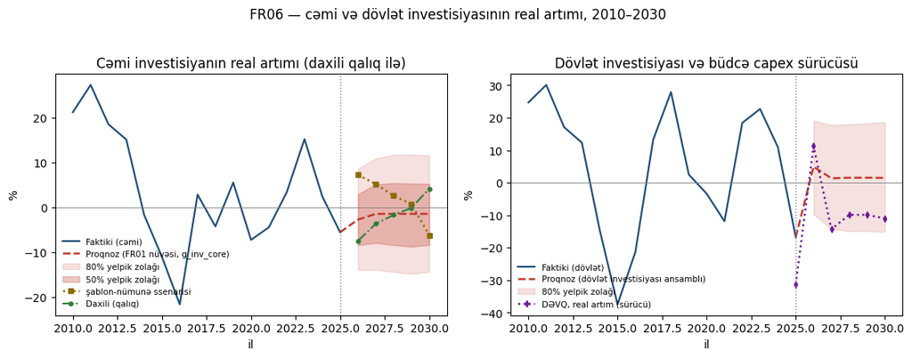

```python
import matplotlib.pyplot as plt

fig, axes = plt.subplots(1, 2, figsize=(11.5, 4.3))

ax = axes[0]
ax.plot(inv_total_g.loc[2010:].index, inv_total_g.loc[2010:].values, "-", color="#1f4e79", lw=1.6,
        label="Faktiki (cəmi)")
ax.plot([LA] + FY, [inv_total_g.loc[LA]] + list(total_g.values), "--", color="#c0392b", lw=1.8,
        label="Proqnoz (FR01 nüvəsi, g_inv_core)")
ax.fill_between(FY, bands_tot["lo80"], bands_tot["hi80"], color="#c0392b", alpha=0.15, label="80% yelpik zolağı")
ax.fill_between(FY, bands_tot["lo50"], bands_tot["hi50"], color="#c0392b", alpha=0.28, label="50% yelpik zolağı")
ax.plot(FY, mb_total_g.values, ":", color="#8e6b00", lw=1.8, marker="s", ms=4,
        label="şablon-nümunə ssenarisi")
ax.plot(FY, dom_g.values, "-.", color="#2e7d32", lw=1.5, marker="o", ms=3.5, label="Daxili (qalıq)")
ax.axvline(LA, color="grey", ls=":", lw=1); ax.axhline(0, color="grey", lw=0.6)
ax.set_title("Cəmi investisiyanın real artımı (daxili qalıq ilə)")
ax.set_ylabel("%"); ax.set_xlabel("il")
ax.legend(loc="lower left", frameon=False, fontsize=7.5)

ax = axes[1]
ax.plot(inv_state_g.loc[2010:].index, inv_state_g.loc[2010:].values, "-", color="#1f4e79", lw=1.6,
        label="Faktiki (dövlət)")
ax.plot([LA] + FY, [inv_state_g.loc[LA]] + list(state_g.values), "--", color="#c0392b", lw=1.8,
        label="Proqnoz (dövlət investisiyası ansamblı)")
ax.fill_between(FY, bands_state["lo80"], bands_state["hi80"], color="#c0392b", alpha=0.15,
                label="80% yelpik zolağı")
ax.plot([LA] + FY, [g_capex.loc[LA]] + [float(capex_realg.loc[y]) for y in FY], ":", color="#6a1b9a",
        lw=1.8, marker="d", ms=4, label="DƏVQ, real artım (sürücü)")
ax.axvline(LA, color="grey", ls=":", lw=1); ax.axhline(0, color="grey", lw=0.6)
ax.set_title("Dövlət investisiyası və büdcə capex sürücüsü")
ax.set_ylabel("%"); ax.set_xlabel("il")
ax.legend(loc="lower left", frameon=False, fontsize=7.5)

fig.suptitle("FR06 — cəmi və dövlət investisiyasının real artımı, 2010–2030", y=1.03)
fig.tight_layout()
fig.savefig(os.path.join(config.FIG, "FR06_investment_growth_forecast.png"), dpi=140, bbox_inches="tight")
plt.show()
```

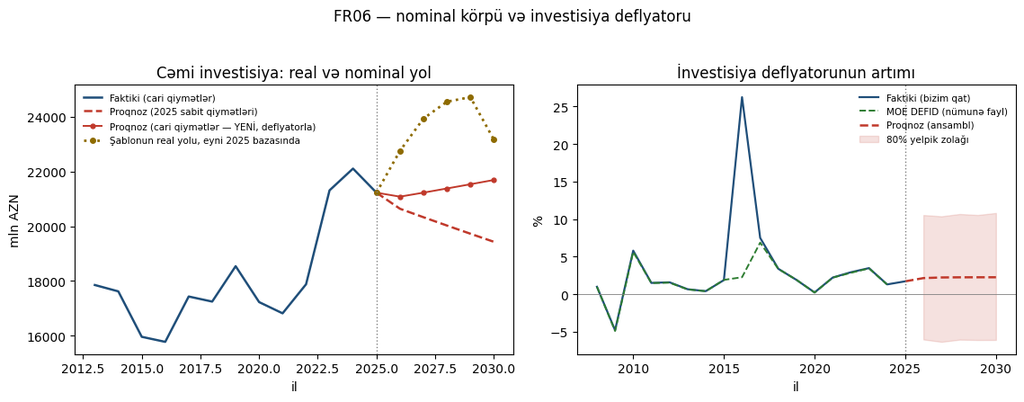

```python
fig, axes = plt.subplots(1, 2, figsize=(11.5, 4.3))

ax = axes[0]
hist = inv_total.loc[2013:]
ax.plot(hist.index, hist.values, "-", color="#1f4e79", lw=1.8, label="Faktiki (cari qiymətlər)")
ax.plot([LA] + FY, [inv_total.loc[LA]] + list(total_level.values), "--", color="#c0392b", lw=1.8,
        label="Proqnoz (2025 sabit qiymətləri)")
ax.plot([LA] + FY, [inv_total.loc[LA]] + list(total_nom_fc.values), "-", color="#c0392b", lw=1.4,
        marker="o", ms=3.5, label="Proqnoz (cari qiymətlər — YENİ, deflyatorla)")
ax.plot([LA] + FY, [inv_total.loc[LA]] + list(mb_total_rebased.values), ":", color="#8e6b00", lw=2.0,
        marker="o", ms=4, label="Şablonun real yolu, eyni 2025 bazasında")
ax.axvline(LA, color="grey", ls=":", lw=1)
ax.set_title("Cəmi investisiya: real və nominal yol")
ax.set_ylabel("mln AZN"); ax.set_xlabel("il")
ax.legend(loc="upper left", frameon=False, fontsize=7.5)

ax = axes[1]
ax.plot(d_inv_g.index, d_inv_g.values, "-", color="#1f4e79", lw=1.6, label="Faktiki (bizim qat)")
ax.plot(moe_defid_g.loc[2008:].index, moe_defid_g.loc[2008:].values, "--", color="#2e7d32", lw=1.4,
        label="MOE DEFID (nümunə fayl)")
ax.plot([LA] + FY, [d_inv_g.loc[LA]] + list(inv_defl_g.values), "--", color="#c0392b", lw=1.8,
        label="Proqnoz (ansambl)")
ax.fill_between(FY, bands_defl["lo80"], bands_defl["hi80"], color="#c0392b", alpha=0.15,
                label="80% yelpik zolağı")
ax.axvline(LA, color="grey", ls=":", lw=1); ax.axhline(0, color="grey", lw=0.6)
ax.set_title("İnvestisiya deflyatorunun artımı")
ax.set_ylabel("%"); ax.set_xlabel("il")
ax.legend(loc="upper right", frameon=False, fontsize=7.5)

fig.suptitle("FR06 — nominal körpü və investisiya deflyatoru", y=1.03)
fig.tight_layout()
fig.savefig(os.path.join(config.FIG, "FR06_ministry_comparison.png"), dpi=140, bbox_inches="tight")
plt.show()
```

## 8. Nəticələrin ixracı

```python
WB = "Statistik data dinamika 05.06.2026 +.xlsx"

cat_rows = pd.DataFrame([
    res_inv.catalog_row(
        eq_name="FR6_investisiya_kredit_kanali",
        description=("STRUKTUR (istifadə olunur): investisiyanın real artımı — real pul kütləsinin cari və "
                     "gecikmiş artımı, 2015-16 süni dəyişəni ilə; FR01-in g_inv_core yoluna eynidir və FR6-da "
                     "CƏMİ investisiyaya düzəlişsiz tətbiq olunur (daxili komponent qalıq kimi alınır)"),
        lhs="inv_total_g", series_code="inv_total_g", fr="FR6", workbook=WB, sheet="Monetar sektoru"),
    res_inv_nd.catalog_row(
        eq_name="FR6_investisiya_kredit_kanali_dummisiz_gecikmesiz",
        description="ROBUSTLİK: eyni kanal süni dəyişənsiz və gecikməsiz — əmsal 0,292-yə düşür",
        lhs="inv_total_g", series_code="inv_total_g", fr="FR6", workbook=WB, sheet="Monetar sektoru"),
    res_inv_d.catalog_row(
        eq_name="FR6_investisiya_kredit_kanali_sunili_gecikmesiz",
        description="ROBUSTLİK: süni dəyişənli, lakin gecikməsiz — süni dəyişənin işarəsi tərsinə dönür, əhəmiyyətsiz",
        lhs="inv_total_g", series_code="inv_total_g", fr="FR6", workbook=WB, sheet="Monetar sektoru"),
    res_inv_x.catalog_row(
        eq_name="FR6_investisiya_kredit_kanali_2015_16_cixarilib",
        description="ROBUSTLİK: 2015-2016 nümunədən tamamilə çıxarılıb — əmsal 0,563-ə qayıdır",
        lhs="inv_total_g", series_code="inv_total_g", fr="FR6", workbook=WB, sheet="Monetar sektoru"),
    res_st1.catalog_row(
        eq_name="FR6_dovlet_investisiyasi_devq",
        description=("Dövlət investisiyası tənliyi (birinci term): dövlət investisiyasının real artımı — büdcənin əsaslı vəsait "
                     "qoyuluşunun real artımı (fiscal_r019, 2022-2023 DİP r4-dən). icmalın tələb etdiyi "
                     f"kanal; sınaq RMSE {bt_state.rmse.get('DEVQ')}"),
        lhs="inv_state_g", series_code="inv_state_g", fr="FR6", workbook=WB, sheet="Fiskal sektor"),
    res_st2.catalog_row(
        eq_name="FR6_dovlet_investisiyasi_devq_d15",
        description=("Dövlət investisiyası tənliyi (İSTİFADƏ OLUNUR, ansamblın bir üzvü): DƏVQ + 2015-16 devalvasiya süni dəyişəni; "
                     f"qapı p={p_st:.4f}, β={b_st:+.3f} → {'keçir' if gate_state else 'keçmir'}; "
                     f"ansambl çəkisi {bt_state.weights.get('DEVQ_D15', 0.0):.3f}"),
        lhs="inv_state_g", series_code="inv_state_g", fr="FR6", workbook=WB, sheet="Fiskal sektor"),
    res_st3.catalog_row(
        eq_name="FR6_dovlet_investisiyasi_iki_termli",
        description=("Dövlət investisiyası tənliyi (iki termli, ƏVƏZEDİCİ ilə): DƏVQ + neft-qaz sektoruna investisiya; "
                     "əvvəlki buraxılışın həlli, müqayisə üçün saxlanılır; "
                     f"sınaq RMSE {bt_state.rmse.get('IKITERMLI')}"),
        lhs="inv_state_g", series_code="inv_state_g", fr="FR6", workbook=WB, sheet="Fiskal sektor"),
    res_st4.catalog_row(
        eq_name="FR6_dovlet_investisiyasi_iki_termli_oz_vesait",
        description=("İki termli forma (büdcə kapital xərcləri + müəssisələrin öz vəsaitləri, tam tarixçə ilə): DƏVQ + müəssisələrin öz "
                     "vəsaitləri ilə investisiyanın real artımı (1999-2025 birləşdirilmiş sıra; "
                     "əvvəlki buraxılışda n=3 olduğu üçün qiymətləndirilə bilmirdi). NƏTİCƏ AÇIQ "
                     f"VERİLİR: β₂={b_st4:+.3f}, p={p_st4:.3f} → qapı "
                     f"{'keçir' if gate_soe else 'KEÇMİR'}; sınaq RMSE "
                     f"{bt_state.rmse.get('IKITERMLI_OZ_VESAIT')} (RW {bt_state.rw_rmse}); "
                     "termin izahedici gücü yoxdur, çünki sıra maliyyələşmə mənbəyi üzrədir, "
                     "mülkiyyət üzrə deyil"),
        lhs="inv_state_g", series_code="inv_state_g", fr="FR6", workbook=WB, sheet="Fiskal sektor"),
    res_st5.catalog_row(
        eq_name="FR6_oz_vesait_tek_termli",
        description=("Dövlət investisiyası tənliyi (yalnız öz vəsaitləri, TAM nümunə n=26): dövlət investisiyasının real "
                     "artımı ~ öz vəsait investisiyasının real artımı; DƏVQ ilə məhdudlaşmayan "
                     f"ən uzun nümunə; β={b_st5:+.3f}, p={p_st5:.3f} — əlaqə yoxdur"),
        lhs="inv_state_g", series_code="inv_state_g", fr="FR6", workbook=WB, sheet="Fiskal sektor"),
] + [
    r.catalog_row(
        eq_name="FR6_neft_investisiyasi_" + {"HƏCM": "hecm", "QİYMƏT": "qiymet",
                                             "BRENT": "brent", "QİYMƏT(-1)": "qiymet_l1",
                                             "HƏCM+QİYMƏT": "hecm_qiymet"}[nm],
        description=("DİAQNOSTİK (qapıdan keçmir — əmsal gözlənilən müsbət işarəyə ziddir): neft-qaz "
                     f"sektoruna investisiyanın real artımı ~ {nm}; sabit pay qaydası ilə birlikdə "
                     "Bölmə 6.4-də yarışdırılır"),
        lhs="inv_oil_g", series_code="inv_oil_g", fr="FR6", workbook=WB, sheet="Neft-Qaz sektoru")
    for nm, r in oil_specs.items()
] + [
    r.catalog_row(
        eq_name="FR6_investisiya_deflyatoru_" + {"ONLARIN FORMASI (eq_defid)": "onlarin_formasi",
                                                 "PROXY DÜSTURU (qiymətləndirilmiş çəki)": "proxy_defl",
                                                 "TİKİNTİ + İDXAL": "tikinti_idxal",
                                                 "İQİ": "iqi"}[nm],
        description=({"ONLARIN FORMASI (eq_defid)":
                      ("Nazirliyin `eq_defid` tənliyi (MOE SNA `eq` r32) bizim qatda yenidən "
                       "qiymətləndirilib — öz gecikməsi + gecikmiş NEER; sınaqda RW-ni ÜSTƏLƏMİR, "
                       "nəticə olduğu kimi nəşr olunur"),
                      "PROXY DÜSTURU (qiymətləndirilmiş çəki)":
                      ("Tikinti deflyatoru ilə idxal qiymətlərinin çəkili düsturu (w_c·tikinti-deflyatoru + (1−w_c)·idxal qiymətləri), "
                       "çəki qiymətləndirilib"),
                      "TİKİNTİ + İDXAL":
                      ("İSTİFADƏ OLUNUR: KOMPOZİSİYA əlaqəsi — tikinti-quraşdırma deflyatoru cəmi "
                       "investisiya deflyatorunun 60-76 %-lik komponentidir, idxal qiymətləri isə "
                       "avadanlıq ayağıdır; davranış tənliyi kimi təqdim edilmir"),
                      "İQİ": "DİAQNOSTİK: yalnız İQİ ilə"}[nm]),
        lhs="inv_defl_g", series_code="inv_defl_g", fr="FR6", workbook=WB, sheet="Real sektor")
    for nm, r in defl_specs.items()
])
outputs.write_equations_catalog(cat_rows)
cat_rows[["eq_name", "lhs", "sample_start", "sample_end", "adj_r2", "se_regression"]]
```

|  | eq_name | lhs | sample_start | sample_end | adj_r2 | se_regression |
| --- | --- | --- | --- | --- | --- | --- |
| 0 | FR6_investisiya_kredit_kanali | inv_total_g | 2008 | 2025 | 0.5887 | 9.6636 |
| 1 | FR6_investisiya_kredit_kanali_dummisiz_gecikmesiz | inv_total_g | 2007 | 2025 | 0.1667 | 13.7811 |
| 2 | FR6_investisiya_kredit_kanali_sunili_gecikmesiz | inv_total_g | 2007 | 2025 | 0.2054 | 13.4573 |
| 3 | FR6_investisiya_kredit_kanali_2015_16_cixarilib | inv_total_g | 2007 | 2025 | 0.2713 | 11.7978 |
| 4 | FR6_dovlet_investisiyasi_devq | inv_state_g | 2011 | 2025 | 0.2634 | 17.2123 |
| 5 | FR6_dovlet_investisiyasi_devq_d15 | inv_state_g | 2011 | 2025 | 0.4649 | 14.6697 |
| 6 | FR6_dovlet_investisiyasi_iki_termli | inv_state_g | 2011 | 2025 | 0.2178 | 17.7370 |
| 7 | FR6_dovlet_investisiyasi_iki_termli_oz_vesait | inv_state_g | 2011 | 2025 | 0.2022 | 17.9131 |
| 8 | FR6_oz_vesait_tek_termli | inv_state_g | 2000 | 2025 | -0.0368 | 39.3303 |
| 9 | FR6_neft_investisiyasi_hecm | inv_oil_g | 2007 | 2025 | 0.0339 | 19.4810 |
| 10 | FR6_neft_investisiyasi_qiymet | inv_oil_g | 2006 | 2025 | 0.0192 | 19.3546 |
| 11 | FR6_neft_investisiyasi_brent | inv_oil_g | 2006 | 2025 | 0.0070 | 19.4751 |
| 12 | FR6_neft_investisiyasi_qiymet_l1 | inv_oil_g | 2006 | 2025 | 0.0114 | 19.4321 |
| 13 | FR6_neft_investisiyasi_hecm_qiymet | inv_oil_g | 2007 | 2025 | 0.0436 | 19.3828 |
| 14 | FR6_investisiya_deflyatoru_onlarin_formasi | inv_defl_g | 2009 | 2025 | -0.0463 | 6.5610 |
| 15 | FR6_investisiya_deflyatoru_proxy_defl | inv_defl_g | 2008 | 2025 | 0.5159 | 4.3479 |
| 16 | FR6_investisiya_deflyatoru_tikinti_idxal | inv_defl_g | 2008 | 2025 | 0.9999 | 0.0713 |
| 17 | FR6_investisiya_deflyatoru_iqi | inv_defl_g | 2008 | 2025 | 0.0992 | 5.9309 |

```python
def _rows(series_code, name_az, unit, actual_s=None, fc_path=None, fc_bands=None,
          fc_source="ours", ministry_s=None):
    """`fc_source` proqnoz sətirlərinin mənbəyini müəyyən edir. Qayda: bir rəqəm ancaq BİR mənbə
    adı altında göndərilir."""
    rows = []
    if actual_s is not None:
        for y, v in actual_s.items():
            if pd.isna(v):
                continue
            rows.append({"fr": "FR6", "series_code": series_code, "series_name_az": name_az, "unit": unit,
                        "year": int(y), "kind": "actual", "source": "ours", "value": float(v),
                        "lo80": None, "hi80": None, "lo50": None, "hi50": None})
    if fc_path is not None:
        for y in fc_path.index:
            b = fc_bands.loc[y] if fc_bands is not None else None
            rows.append({"fr": "FR6", "series_code": series_code, "series_name_az": name_az, "unit": unit,
                        "year": int(y), "kind": "forecast", "source": fc_source, "value": float(fc_path.loc[y]),
                        "lo80": (float(b["lo80"]) if b is not None else None),
                        "hi80": (float(b["hi80"]) if b is not None else None),
                        "lo50": (float(b["lo50"]) if b is not None else None),
                        "hi50": (float(b["hi50"]) if b is not None else None)})
    if ministry_s is not None:
        for y, v in ministry_s.items():
            if pd.isna(v):
                continue
            rows.append({"fr": "FR6", "series_code": series_code, "series_name_az": name_az, "unit": unit,
                        "year": int(y), "kind": "forecast", "source": "template_sample", "value": float(v),
                        "lo80": None, "hi80": None, "lo50": None, "hi50": None})
    return rows


fl_rows = []


def _rows_level(base_code, name_az, actual_s=None, fc_path=None, ministry_s=None, nom_fc=None):
    """Səviyyə sırası İKİ kodla nəşr olunur — qiymət bazası ADIN İÇİNDƏ görünür (D5):

      · `<kod>_nom`       — CARİ qiymətlər: faktiki müşahidələr, şablon-nümunə səviyyələri VƏ
        (bu buraxılışdan e'tibarən) bizim öz nominal proqnozumuz — deflyator yolu ilə qurulub;
      · `<kod>_real2025`  — 2025-ci ilin SABİT qiymətləri: proqnoz yolu + baza ili lövbəri.
    """
    rows = []
    if actual_s is not None:
        for y, v in actual_s.items():
            if pd.isna(v):
                continue
            rows.append({"fr": "FR6", "series_code": f"{base_code}_nom",
                        "series_name_az": f"{name_az} (cari qiymətlərlə)", "unit": "mln AZN",
                        "year": int(y), "kind": "actual", "source": "ours", "value": float(v),
                        "lo80": None, "hi80": None, "lo50": None, "hi50": None})
    if nom_fc is not None:
        for y in nom_fc.index:
            rows.append({"fr": "FR6", "series_code": f"{base_code}_nom",
                        "series_name_az": f"{name_az} (cari qiymətlərlə)", "unit": "mln AZN",
                        "year": int(y), "kind": "forecast", "source": "ours", "value": float(nom_fc.loc[y]),
                        "lo80": None, "hi80": None, "lo50": None, "hi50": None})
    if ministry_s is not None:
        for y, v in ministry_s.items():
            if pd.isna(v):
                continue
            rows.append({"fr": "FR6", "series_code": f"{base_code}_nom",
                        "series_name_az": f"{name_az} (cari qiymətlərlə)", "unit": "mln AZN",
                        "year": int(y), "kind": "forecast", "source": "template_sample",
                        "value": float(v), "lo80": None, "hi80": None, "lo50": None, "hi50": None})
    if fc_path is not None:
        nm_r = f"{name_az} (2025 sabit qiymətləri ilə)"
        if actual_s is not None and LA in actual_s.index and not pd.isna(actual_s.loc[LA]):
            rows.append({"fr": "FR6", "series_code": f"{base_code}_real2025",
                        "series_name_az": nm_r, "unit": "mln AZN", "year": int(LA),
                        "kind": "actual", "source": "ours", "value": float(actual_s.loc[LA]),
                        "lo80": None, "hi80": None, "lo50": None, "hi50": None})
        for y in fc_path.index:
            rows.append({"fr": "FR6", "series_code": f"{base_code}_real2025",
                        "series_name_az": nm_r, "unit": "mln AZN", "year": int(y),
                        "kind": "forecast", "source": "ours", "value": float(fc_path.loc[y]),
                        "lo80": None, "hi80": None, "lo50": None, "hi50": None})
    return rows


fl_rows += _rows_level("inv_total", "Əsas kapitala cəmi investisiya",
                       actual_s=inv_total, fc_path=total_level, ministry_s=mb_total, nom_fc=total_nom_fc)
fl_rows += _rows("inv_total_g", "Əsas kapitala investisiyaların real artım tempi", "%",
                 actual_s=inv_total_g, fc_path=total_g, fc_bands=bands_tot, ministry_s=mb_total_g)
fl_rows += _rows_level("inv_domestic", "Daxili investisiya",
                       actual_s=inv_dom, fc_path=dom_level, ministry_s=mb_dom, nom_fc=dom_nom_fc)
fl_rows += _rows("inv_domestic_g", "Daxili investisiyanın real artım tempi", "%",
                 actual_s=inv_dom_g, fc_path=dom_g)
fl_rows += _rows_level("inv_foreign", "Xarici investisiya",
                       actual_s=inv_for, fc_path=for_level, ministry_s=mb_for, nom_fc=for_nom_fc)
fl_rows += _rows("inv_foreign_g", "Xarici investisiyanın real artım tempi", "%",
                 actual_s=inv_for_g, fc_path=for_g, fc_source="template_sample")
fl_rows += _rows_level("inv_oil", "Neft-qaz sektoruna investisiyalar",
                       actual_s=inv_oil, fc_path=oil_level, nom_fc=oil_nom_fc)
fl_rows += _rows_level("inv_nonoil", "Qeyri neft-qaz sektoruna investisiyalar",
                       actual_s=inv_nonoil, fc_path=nonoil_level, nom_fc=nonoil_nom_fc)
fl_rows += _rows("inv_oil_g", "Neft-qaz sektoruna investisiyaların real artım tempi", "%",
                 actual_s=g_oil_inv, fc_path=oil_g, fc_bands=bands_oil)
fl_rows += _rows("inv_nonoil_g", "Qeyri neft-qaz sektoruna investisiyaların real artım tempi", "%",
                 actual_s=g_nonoil_inv, fc_path=nonoil_g)
fl_rows += _rows_level("inv_state", "Dövlət investisiyaları",
                       actual_s=inv_state, fc_path=state_level, nom_fc=state_nom_fc,
                       ministry_s=data_layer.ministry_baseline("inv_state"))
fl_rows += _rows("inv_state_g", "Dövlət investisiyalarının real artım tempi", "%",
                 actual_s=inv_state_g, fc_path=state_g, fc_bands=bands_state)
fl_rows += _rows_level("inv_nonstate", "Qeyri-dövlət investisiyaları",
                       actual_s=inv_nonst, fc_path=nonstate_level, nom_fc=nonstate_nom_fc,
                       ministry_s=data_layer.ministry_baseline("inv_nonstate"))
fl_rows += _rows("inv_nonstate_g", "Qeyri-dövlət investisiyalarının real artım tempi", "%",
                 actual_s=inv_nonst_g, fc_path=nonstate_g)
```

```python
# --- YENİ sıralar: qeyri-neft × mülkiyyət, deflyator, fiskal blok --------------------------------
nn_nom_fc = (nn_level * defl_index / 100.0)
nnst_nom_fc = (nnst_level * defl_index / 100.0)
fl_rows += _rows_level("inv_nonoil_nonstate", "Qeyri neft-qaz qeyri-dövlət investisiyaları",
                       actual_s=nonoil_nonstate, fc_path=nn_level, nom_fc=nn_nom_fc)
fl_rows += _rows_level("inv_nonoil_state", "Qeyri neft-qaz dövlət investisiyaları",
                       actual_s=nonoil_state, fc_path=nnst_level, nom_fc=nnst_nom_fc)
fl_rows += _rows("inv_nonoil_nonstate_g", "Qeyri neft-qaz qeyri-dövlət investisiyalarının real artımı",
                 "%", actual_s=NN["y"].dropna(), fc_path=nn_g)
# Dövlət ayağının ARTIM sırası da nəşr olunur (icmalın B10 qeydi): əvvəllər bu ayaq yalnız
# səviyyə (cari və 2025 sabit qiymətlər) kimi verilirdi, qeyri-dövlət ayağı isə artım tempi ilə —
# yəni bölgü ekranda simmetrik deyildi. Sıra EYNİLİK qalığıdır (qeyri-neft cəmi − qeyri-dövlət),
# ona görə öz tənliyi yoxdur; bu, sıra lüğətində və FR6 səhifəsində açıq yazılır.
fl_rows += _rows("inv_nonoil_state_g", "Qeyri neft-qaz dövlət investisiyalarının real artımı",
                 "%", actual_s=real_g(nonoil_state), fc_path=nnst_g)
fl_rows += _rows("inv_defl_g", "İnvestisiya deflyatorunun illik artımı", "%",
                 actual_s=d_inv_g, fc_path=inv_defl_g, fc_bands=bands_defl)
fl_rows += _rows("inv_defl", "İnvestisiya deflyatoru (indeks, 2025 = 100)", "indeks",
                 actual_s=pd.Series({LA: 100.0}), fc_path=defl_index)
# DƏVQ: faktiki (cari qiymətlər) + proqnoz yolu (cari qiymətlər, real artım × İQİ)
capex_nom_fc, _p = {}, float(capex.loc[LA])
for _y in FY:
    _p = _p * (1 + float(capex_realg.loc[_y]) / 100.0) * (1 + float(cpi_fc.loc[_y]) / 100.0)
    capex_nom_fc[_y] = _p
capex_nom_fc = pd.Series(capex_nom_fc, name="state_capex")
fl_rows += _rows("state_capex", "Dövlət büdcəsinin əsaslı vəsait qoyuluşu (DƏVQ)", "mln AZN",
                 actual_s=capex, fc_path=capex_nom_fc)
# --- FİSKAL PARAMETRLƏR VƏ QEYRİ-NEFT BAZA KƏSİRİNİN ÜFÜQƏ UZADILMASI (icmalın B18 qeydi) ------
# Qeyd üç şey istəyir: (i) fiskal parametrlərin görünməsi, (ii) xərclərin cari / əsaslı / borca
# xidmət ayrılığı, (iii) qeyri-neft baza kəsirinin qeyri-neft ÜDM-ə nisbətinin modelə daxil olması.
# (i) və (ii) məlumat qatında ONSUZ DA var idi, lakin `forecast_long`-a YAZILMIRDI — ona görə
# oxucu "fiskal məlumat yoxdur" nəticəsinə gəlirdi. İndi hamısı nəşr olunur.
# (iii) sıra yalnız TARİXDƏ mövcud idi (2010–2025); aşağıda üfüqə uzadılır.
#
# UZATMA QAYDASI — TƏNLİK DEYİL, KALİBRLƏNMİŞ PAY QAYDASIDIR və belə də etiketlənir:
# qeyri-neft büdcə gəlirləri və büdcə xərcləri son beş faktiki ilin qeyri-neft ÜDM-ə nisbətində
# saxlanılır, səviyyələr isə FR02-nin nəşr etdiyi NOMİNAL qeyri-neft ÜDM yolundan qurulur.
# Bu, siyasət proqnozu deyil — DƏYİŞMƏYƏN SİYASƏT PAYLARI altında baza yoludur; nisbətin özü
# demək olar ki, sabit çıxır və bu, qaydanın nəticəsidir, tapıntı deyil.
_nn_nom = (pd.read_csv(os.path.join(config.OUT, "forecast_long.csv"))
             .query("series_code == 'nonoil_nom' and source == 'ours'")
             .set_index("year")["value"].astype(float).sort_index())
# LÖVBƏR SON FAKTİKİ İLDİR, beş illik orta DEYİL. Səbəb ölçülüb: beş illik orta paylarla
# nisbət 2025-in faktiki −19,77 %-indən 2026-da −22,92 %-ə SIÇRAYIR, yəni 2025/2026 sərhədində
# süni qırılma yaranır — paketin D5 qaydası məhz bu növ qırılmanı qadağan edir. Son ilin payları
# ilə yol kəsilmədən davam edir. Beş illik orta variantı SİLİNMİR, aşağıda həssaslıq kimi çap olunur.
_SHARE_WIN = 5
_rev_share = float((nob["revenue_nonoil"] / nob["gdp_nonoil"]).loc[LA])
_exp_share = float((nob["expenditure"] / nob["gdp_nonoil"]).loc[LA])
_rev_share5 = float((nob["revenue_nonoil"] / nob["gdp_nonoil"]).loc[LA - _SHARE_WIN + 1:LA].mean())
_exp_share5 = float((nob["expenditure"] / nob["gdp_nonoil"]).loc[LA - _SHARE_WIN + 1:LA].mean())
_rev_fc = (_nn_nom.reindex(FY) * _rev_share).rename("revenue_nonoil")
_exp_fc = (_nn_nom.reindex(FY) * _exp_share).rename("expenditure")
_bal_fc = (_rev_fc - _exp_fc).rename("balance")
_ratio_fc = (_bal_fc / _nn_nom.reindex(FY) * 100.0).rename("ratio")
print(f"\nB18 — qeyri-neft baza kəsirinin üfüqə uzadılması (pay qaydası, lövbər {LA}):")
print(f"  qeyri-neft gəlirlərinin payı {_rev_share*100:.2f} % · büdcə xərclərinin payı "
      f"{_exp_share*100:.2f} % (qeyri-neft ÜDM-ə nisbətdə)")
print(pd.DataFrame({"qeyri-neft gəlir": _rev_fc.round(1), "büdcə xərcləri": _exp_fc.round(1),
                    "baza balansı": _bal_fc.round(1), "nisbət, %": _ratio_fc.round(2)}).to_string())
print(f"  faktiki {LA} nisbəti: {float(nob['ratio_nonoil_gdp'].loc[LA]):.2f} % — "
      f"yol kəsilmədən davam edir (qırılma yoxdur)")
print(f"  HƏSSASLIQ: beş illik orta paylarla ({_rev_share5*100:.2f} % / {_exp_share5*100:.2f} %) "
      f"nisbət {(_rev_share5 - _exp_share5) * 100:.2f} % olardı — {LA}-in faktiki dəyərindən "
      f"{abs((_rev_share5 - _exp_share5) * 100 - float(nob['ratio_nonoil_gdp'].loc[LA])):.2f} f.b. "
      "aralı; həmin variant süni sıçrayış yaratdığı üçün nəşr olunmur.")

# fiskal parametrlər — tarixi sıralar nəşr olunur (proqnoz yolu yalnız yuxarıdakı üç sıra üçün)
for _code, _nm, _col in [
        ("budget_revenue_total", "Dövlət büdcəsinin gəlirləri", "revenue_total"),
        ("budget_revenue_oil", "Dövlət büdcəsinin neft-qaz gəlirləri", "revenue_oil"),
        ("budget_revenue_nonoil", "Dövlət büdcəsinin qeyri-neft-qaz gəlirləri", "revenue_nonoil"),
        ("budget_expenditure", "Dövlət büdcəsinin xərcləri", "exp_total"),
        ("budget_exp_current", "Dövlət büdcəsinin cari xərcləri", "exp_current"),
        ("budget_exp_capital", "Dövlət büdcəsinin əsaslı xərcləri", "exp_capital"),
        ("budget_debt_service", "Borca xidmət xərcləri", "debt_service"),
        ("budget_balance", "Dövlət büdcəsinin kəsiri/profisiti", "balance")]:
    if _col in fisc:
        fl_rows += _rows(_code, _nm, "mln AZN", actual_s=fisc[_col].dropna())
```

```python
fl_rows += _rows("nonoil_base_balance_sb", "Dövlət büdcəsi üzrə qeyri-neft balansı", "mln AZN",
                 actual_s=nob["balance"], fc_path=_bal_fc)
fl_rows += _rows("nonoil_base_ratio_sb",
                 "Dövlət büdcəsi üzrə qeyri-neft balansı / qeyri-neft ÜDM", "%",
                 actual_s=nob["ratio_nonoil_gdp"], fc_path=_ratio_fc)

fl_df = pd.DataFrame(fl_rows)
_dup = (fl_df[fl_df.kind == "forecast"]
        .groupby(["series_code", "year"])["value"]
        .agg(lambda s: len(s) > 1 and s.round(6).nunique() == 1))
assert not _dup.any(), f"bit-bərabər dublikat mənbə: {sorted(_dup[_dup].index.tolist())}"
for _c in ("inv_total", "inv_domestic", "inv_foreign", "inv_oil", "inv_nonoil",
           "inv_state", "inv_nonstate", "inv_nonoil_nonstate", "inv_nonoil_state"):
    _n = fl_df[(fl_df.series_code == f"{_c}_nom") & (fl_df.year == LA) & (fl_df.kind == "actual")]
    _r = fl_df[(fl_df.series_code == f"{_c}_real2025") & (fl_df.year == LA)]
    assert len(_n) == 1 and len(_r) == 1 and abs(float(_n.value.iloc[0]) - float(_r.value.iloc[0])) < 1e-9, \
        f"{_c}: baza ilində (2025) cari və sabit qiymətli səviyyələr üst-üstə düşmür"
outputs.write_forecast_long(fl_df)
print(f"forecast_long.csv-ə {len(fl_df)} sətir yazıldı (FR6 əhatəsi); "
      f"o cümlədən şablon-nümunə mənbəli: {int((fl_df['source'] == 'template_sample').sum())}")
fl_df.groupby(["series_code", "kind"]).size().unstack(fill_value=0)
```

```
B18 — qeyri-neft baza kəsirinin üfüqə uzadılması (pay qaydası, lövbər 2025):
  qeyri-neft gəlirlərinin payı 22.05 % · büdcə xərclərinin payı 41.82 % (qeyri-neft ÜDM-ə nisbətdə)
      qeyri-neft gəlir  büdcə xərcləri  baza balansı  nisbət, %
year
2026           23450.8         44473.2      -21022.4     -19.77
2027           26661.0         50561.1      -23900.2     -19.77
2028           30318.7         57497.8      -27179.1     -19.77
2029           34499.4         65426.4      -30926.9     -19.77
2030           39249.1         74433.8      -35184.8     -19.77
  faktiki 2025 nisbəti: -19.77 % — yol kəsilmədən davam edir (qırılma yoxdur)
  HƏSSASLIQ: beş illik orta paylarla (22.16 % / 45.08 %) nisbət -22.92 % olardı — 2025-in faktiki dəyərindən 3.15 f.b. aralı; həmin variant süni sıçrayış yaratdığı üçün nəşr olunmur.
forecast_long.csv-ə 762 sətir yazıldı (FR6 əhatəsi); o cümlədən şablon-nümunə mənbəli: 27
```

| kind series_code | actual | forecast |
| --- | --- | --- |
| budget_balance | 16 | 0 |
| budget_debt_service | 16 | 0 |
| budget_exp_capital | 16 | 0 |
| budget_exp_current | 16 | 0 |
| budget_expenditure | 16 | 0 |
| budget_revenue_nonoil | 16 | 0 |
| budget_revenue_oil | 16 | 0 |
| budget_revenue_total | 16 | 0 |
| inv_defl | 1 | 5 |
| inv_defl_g | 18 | 5 |
| inv_domestic_g | 26 | 5 |
| inv_domestic_nom | 26 | 10 |
| inv_domestic_real2025 | 1 | 5 |
| inv_foreign_g | 26 | 5 |
| inv_foreign_nom | 26 | 10 |
| inv_foreign_real2025 | 1 | 5 |
| inv_nonoil_g | 20 | 5 |
| inv_nonoil_nom | 21 | 5 |
| inv_nonoil_nonstate_g | 7 | 5 |
| inv_nonoil_nonstate_nom | 8 | 5 |
| inv_nonoil_nonstate_real2025 | 1 | 5 |
| inv_nonoil_real2025 | 1 | 5 |
| inv_nonoil_state_g | 7 | 5 |
| inv_nonoil_state_nom | 8 | 5 |
| inv_nonoil_state_real2025 | 1 | 5 |
| inv_nonstate_g | 26 | 5 |
| inv_nonstate_nom | 26 | 6 |
| inv_nonstate_real2025 | 1 | 5 |
| inv_oil_g | 20 | 5 |
| inv_oil_nom | 21 | 5 |
| inv_oil_real2025 | 1 | 5 |
| inv_state_g | 26 | 5 |
| inv_state_nom | 26 | 6 |
| inv_state_real2025 | 1 | 5 |
| inv_total_g | 25 | 10 |
| inv_total_nom | 31 | 10 |
| inv_total_real2025 | 1 | 5 |
| nonoil_base_balance_sb | 16 | 5 |
| nonoil_base_ratio_sb | 16 | 5 |
| state_capex | 16 | 5 |

```python
# Bir model ümumi pəncərədə minimum nöqtə sayını doldura bilmirsə, onun RMSE-si təyin olunmur
# (None) — belə sətirlər çıxış müqaviləsinə yazılmır, lakin NEÇƏSİNİN atıldığı çap olunur ki,
# "sınandı, lakin ölçülə bilmədi" halı görünməz qalmasın.
def _wbt(res, label):
    t = res.table
    drop = int(t["rmse_h"].isna().sum())
    if drop:
        print(f"  {label}: {drop} sətir yazılmadı — modelin RMSE-si ümumi pəncərədə təyin olunmur "
              f"(minimum nöqtə sayı dolmayıb)")
    outputs.write_backtest(t.dropna(subset=["rmse_h"]))


_wbt(bt, "inv_total_g")
_wbt(bt2, "inv_foreign_g")
_wbt(bt_state, "inv_state_g")
_wbt(bt_oil, "inv_oil_g")
_wbt(bt_oil_used, "inv_oil_g_merkezi")
_wbt(bt_defl, "inv_defl_g")
_wbt(bt_nn, "inv_nonoil_nonstate_g")
print("validation_backtest.csv: FR6-nın yeddi yarışı yazıldı "
      "(inv_total_g, inv_foreign_g, inv_state_g, inv_oil_g, inv_oil_g_merkezi, inv_defl_g, "
      "inv_nonoil_nonstate_g)")
```

```
  inv_nonoil_nonstate_g: 2 sətir yazılmadı — modelin RMSE-si ümumi pəncərədə təyin olunmur (minimum nöqtə sayı dolmayıb)
validation_backtest.csv: FR6-nın yeddi yarışı yazıldı (inv_total_g, inv_foreign_g, inv_state_g, inv_oil_g, inv_oil_g_merkezi, inv_defl_g, inv_nonoil_nonstate_g)
```

### 8.1 Dinamiklik göstəricisi və D2 əsaslandırmaları

Göstərici bu dəftərin nəşr etdiyi hər temp sırası üçün hesablanır. Aralıqdan kənara düşən HƏR sıra üçün əsaslandırma **faktdır, təsvir deyil**: mərkəzi yolu hansı ansambl daşıyır, sürücünün yolu üfüq boyu nə qədər dəyişir. Əsaslandırma `series_dictionary.csv`-nin qeyd sütununa yazılır ki, dashboard-u oxuyan onu rəqəmin yanında görsün (aralığın özü nəşr olunmur — D2).

```python
def _wtxt(w):
    return ", ".join(f"{m} {v:.2f}" for m, v in w.items()) or "yoxdur"


def _span_txt(path):
    p = pd.Series(path).dropna()
    return f"{float(p.min()):.2f}-{float(p.max()):.2f} % ({float(p.max()-p.min()):.2f} f.b.)"


# Hər sıra üçün: (mexanizm sinfi, ölçülmüş əsaslandırma). Sinif `ek.DYN_CLASSES` açarlarındandır
# və qeyd sütununda əsaslandırma ilə birlikdə nəşr olunur (D2).
DYN_JUST_FR6 = {
    "inv_total_g": ("ekzogen",
                    "mərkəzi yol FR01 nüvəsinin g_inv_core həllidir; nüvənin sürücüsü real pul "
                    f"kütləsinin profilidir və onun proqnoz yolu {_span_txt(M2_PATH)} aralığındadır"),
    "inv_foreign_g": ("ekzogen",
                      "mərkəzi yol EKZOGEN fərziyyədir (Nazirliyin FDI layihə bazasının real artım "
                      "sətri), ona görə dəyişkənlik fərziyyənin öz profilindən gəlir, modeldən deyil"),
    "inv_state_g": ("ekzogen",
                    f"mərkəzi yolu daşıyan ansambl: {_wtxt(bt_state.weights)}; sürücü DƏVQ-in real "
                    f"artımıdır və onun proqnoz yolu {_span_txt(capex_realg)} aralığındadır "
                    "(2026 rəsmi plandan, 2027-2030 profil sınağından)"),
    # Neft-qaz investisiyası: heç bir struktur namizəd qapıdan keçmədi → yolu ETALON daşıyır.
    # Uduzan yarışın ünvanı göstərilir ki, "niyə hamardır" sualı rəqəmlə yoxlana bilsin.
    "inv_oil_g": ("etalon",
                  f"mərkəzi yolu daşıyan ansambl: {_wtxt(bt_oil_used.weights)}; heç bir struktur "
                  "sürücü qapıdan keçmədiyi üçün yol dinamik etalonlarla qurulur; uduzan yarış "
                  "`validation_backtest.csv`-də `inv_oil_g` sətirlərindədir "
                  "(NEFT_BRENT / NEFT_QIYMET / NEFT_HACM / V2_PAY3 namizədləri)"),
    "inv_defl_g": ("qiymet",
                   f"mərkəzi yolu daşıyan ansambl: {_wtxt(bt_defl.weights)}; sürücü tikinti-quraşdırma "
                   f"deflyatorunun FR02 yoludur, onun proqnoz aralığı {_span_txt(pdrv_constr_fc)}"),
}

_dyn6 = []
for _code, _lab, _fc, _hist in [
        ("inv_total_g", "Cəmi investisiyanın real artımı", total_g, inv_total_g),
        ("inv_foreign_g", "Xarici investisiyanın real artımı", for_g, inv_for_g),
        ("inv_state_g", "Dövlət investisiyasının real artımı", state_g, inv_state_g),
        ("inv_oil_g", "Neft-qaz sektoruna investisiyanın real artımı", oil_g, g_oil_inv),
        ("inv_defl_g", "İnvestisiya deflyatorunun artımı", inv_defl_g, d_inv_g)]:
    try:
        _cls6, _txt6 = DYN_JUST_FR6[_code]
        _dyn6.append(ek.sigma_ratio(pd.Series(_fc).reindex(FY), _hist, series_code=_code,
                                    label_az=_lab, justification=_txt6, dyn_class=_cls6))
    except Exception as _e:
        print(f"  DİQQƏT: {_code} — dinamiklik göstəricisi hesablanmadı ({_e})")
outputs.write_backtest(ek.dynamics_rows(_dyn6))
_band6 = ek.assert_dynamics_band(_dyn6, strict=False)
outputs.publish_dynamics_notes(_dyn6)
display(pd.DataFrame([{"sıra": r.series_code, "σ(faktiki)": round(r.sd_actual, 3),
                       "σ(proqnoz)": round(r.sd_forecast, 3),
                       "dinamiklik": round(r.ratio, 3)} for r in _dyn6]))
print(f"Daxili qəbul yoxlaması: {int(_band6['aralıqda'].sum())}/{len(_band6)} sıra aralıqdadır; "
      "kənarda qalan hər sıra üçün əsaslandırma seriya lüğətinə yazılır.")
```

```
D2: 5 sıra üçün dinamiklik əsaslandırması seriya lüğətinə yazıldı
```

|  | sıra | σ(faktiki) | σ(proqnoz) | dinamiklik |
| --- | --- | --- | --- | --- |
| 0 | inv_total_g | 9.700 | 0.509 | 0.052 |
| 1 | inv_foreign_g | 22.933 | 11.675 | 0.509 |
| 2 | inv_state_g | 18.801 | 1.378 | 0.073 |
| 3 | inv_oil_g | 15.612 | 1.283 | 0.082 |
| 4 | inv_defl_g | 6.629 | 0.042 | 0.006 |

```
Daxili qəbul yoxlaması: 1/5 sıra aralıqdadır; kənarda qalan hər sıra üçün əsaslandırma seriya lüğətinə yazılır.
```

```python
NOTE_AGG = ("törənmiş — cəmi = FR01 nüvəsinin yolu (g_inv_core), xarici komponent EKZOGEN fərziyyədir "
            "(inv_foreign_realg)")
NOTE_STATE = ("dövlət komponenti artıq SABİT PAY deyil: dövlət investisiyası ansamblı (büdcə capex tənliyi + v2 pay "
              "qaydası + dinamik etalonlar), çəkilər geriyə sınaqdan; qeyri-dövlət qalıqdır")
NOTE_OIL = ("neft-qaz komponenti artıq SABİT PAY deyil: yarışın ansamblı daşıyır (struktur sürücülər "
            "qapıdan keçmədi, sabit pay isə RW-ni üstələmədi); qeyri-neft qalıqdır")
NOTE_DEFL = ("nominal proqnoz yolu investisiya deflyatoru ilə qurulub (inv_defl); əvvəlki buraxılışda "
             "nominal proqnoz sətri ÜMUMİYYƏTLƏ yox idi — investisiyanın ayrıca qiymət indeksi")
LVL = [
    ("inv_total", "Əsas kapitala cəmi investisiyalar", "Total fixed capital investment",
     "8 vərəq, 2.4.1.5.-7.; " + NOTE_AGG),
    ("inv_domestic", "Daxili investisiya", "Domestic investment",
     "8 vərəq, 2.4.1.5.-7.; proqnoz QALIQ-dır (cəmi − xarici)"),
    ("inv_foreign", "Xarici investisiya", "Foreign investment",
     ("8 vərəq, 2.4.1.5.-7.; proqnoz = şablon-nümunə ssenarisinin REAL artım yolu iş kitabının "
      "2025 səviyyəsinə tətbiq edilib (vintaj yenidən bazalaşdırma)")),
    ("inv_oil", "Neft-qaz sektoruna investisiyalar", "Investment in oil and gas sector",
     "8 vərəq, 2.4.1.5.-7.; " + NOTE_OIL),
    ("inv_nonoil", "Qeyri neft-qaz sektoruna investisiyalar", "Investment in non-oil sectors",
     "8 vərəq, 2.4.1.5.-7.; " + NOTE_OIL),
    ("inv_state", "Dövlət investisiyaları", "State investment",
     "8 vərəq, 2.4.1.5.-7.; " + NOTE_STATE),
    ("inv_nonstate", "Qeyri-dövlət investisiyaları", "Non-state investment",
     "8 vərəq, 2.4.1.5.-7.; " + NOTE_STATE),
    ("inv_nonoil_nonstate", "Qeyri neft-qaz qeyri-dövlət investisiyaları",
     "Non-oil non-state investment",
     ("Real sektor, sətir 102 (2018-2025, n=8 — QISA NÜMUNƏ, D5); rəyin 'yoxdur' dediyi "
      "kəsişmə budur")),
    ("inv_nonoil_state", "Qeyri neft-qaz dövlət investisiyaları", "Non-oil state investment",
     ("EYNİLİK: Real sektor sətir 84 − sətir 102 (2018-2025, n=8); "
      "2025: 15 886,5 − 5 422,5 = 10 464,0")),
]
dict_list = []
for code, nm_az, nm_en, ref in LVL:
    dict_list.append({"series_code": f"{code}_nom", "name_az": f"{nm_az} (cari qiymətlərlə)",
                      "name_en": f"{nm_en} (current prices)", "unit": "mln AZN", "fr": "FR6",
                      "statutory_sheet_ref": ref + "; faktiki müşahidələr, şablon-nümunə səviyyələri "
                                                   "VƏ bizim nominal proqnozumuz cari qiymətlərlədir. "
                                                   + NOTE_DEFL,
                      "price_basis": "cari"})
    dict_list.append({"series_code": f"{code}_real2025",
                      "name_az": f"{nm_az} (2025 sabit qiymətləri ilə)",
                      "name_en": f"{nm_en} (constant 2025 prices)", "unit": "mln AZN", "fr": "FR6",
                      "statutory_sheet_ref": ref + "; proqnoz yolu 2025 sabit qiymətləri ilədir, "
                                                   "2025 sətri baza ili lövbəridir",
                      "price_basis": "sabit-2025"})
for code, nm_az, nm_en, _ref in LVL:
    dict_list.append({"series_code": code, "name_az": nm_az, "name_en": nm_en, "unit": "mln AZN",
                      "fr": "FR6",
                      "statutory_sheet_ref": (f"faktiki sıra (iş kitabı, cari qiymətlər). NƏŞRDƏ bu kod "
                                              f"iki kodla əvəzlənib: `{code}_nom` (cari qiymətlər) və "
                                              f"`{code}_real2025` (2025 sabit qiymətləri)"),
                      "price_basis": "cari"})

_J = {r.series_code: r for r in _dyn6}


def _dyn_note(code):
    # `note_text` — sinif izahı + ölçülmüş əsaslandırma; `publish_dynamics_notes` ilə EYNİ mətn,
    # ona görə bu dəftərin öz lüğət sətirləri ilə mərkəzi nəşr arasında fərq yaranmır.
    r = _J.get(code)
    return "" if r is None else f" DİNAMİKLİK {r.ratio:.3f}: {r.note_text}."


dict_list += [
    {"series_code": "inv_oil_g", "name_az": "Neft-qaz sektoruna investisiyaların real artım tempi",
     "name_en": "Investment in oil and gas sector, real growth", "unit": "%", "fr": "FR6",
     "statutory_sheet_ref": "Real sektor, sətir 82/83; " + NOTE_OIL + _dyn_note("inv_oil_g")},
    {"series_code": "inv_nonoil_g", "name_az": "Qeyri neft-qaz sektoruna investisiyaların real artım tempi",
     "name_en": "Investment in non-oil sectors, real growth", "unit": "%", "fr": "FR6",
     "statutory_sheet_ref": "Real sektor, sətir 84/85; qalıq (cəmi − neft-qaz); " + NOTE_OIL},
    {"series_code": "inv_total_g", "name_az": "Əsas kapitala investisiyaların real artım tempi",
     "name_en": "Fixed capital investment real growth", "unit": "%", "fr": "FR6",
     "statutory_sheet_ref": ("8 vərəq, 2.4.1.5.-7.; proqnoz = FR01 nüvəsinin g_inv_core yolu, "
                             "düzəlişsiz." + _dyn_note("inv_total_g"))},
    {"series_code": "inv_domestic_g", "name_az": "Daxili investisiyanın real artım tempi",
     "name_en": "Domestic investment real growth", "unit": "%", "fr": "FR6",
     "statutory_sheet_ref": "8 vərəq, 2.4.1.5.-7.; qalıq yoldan törənib, ayrıca yelpik zolağı yoxdur"},
    {"series_code": "inv_foreign_g", "name_az": "Xarici investisiyanın real artım tempi",
     "name_en": "Foreign investment real growth", "unit": "%", "fr": "FR6",
     "statutory_sheet_ref": ("8 vərəq, 2.4.1.5.-7., sətir 17; proqnoz sətirləri şablon-nümunə "
                             "ssenarisinin ÖZ rəqəmidir (source=template_sample), ekzogen fərziyyə "
                             "açarı: inv_foreign_realg." + _dyn_note("inv_foreign_g"))},
    {"series_code": "inv_state_g", "name_az": "Dövlət investisiyalarının real artım tempi",
     "name_en": "State investment real growth", "unit": "%", "fr": "FR6",
     "statutory_sheet_ref": "Real sektor, sətir 99; " + NOTE_STATE + "." + _dyn_note("inv_state_g")},
    {"series_code": "inv_nonstate_g", "name_az": "Qeyri-dövlət investisiyalarının real artım tempi",
     "name_en": "Non-state investment real growth", "unit": "%", "fr": "FR6",
     "statutory_sheet_ref": "Real sektor, sətir 101; qalıq (cəmi − dövlət); " + NOTE_STATE},
    {"series_code": "inv_nonoil_nonstate_g",
     "name_az": "Qeyri neft-qaz qeyri-dövlət investisiyalarının real artımı",
     "name_en": "Non-oil non-state investment, real growth", "unit": "%", "fr": "FR6",
     "statutory_sheet_ref": ("Real sektor 102/103; QISA NÜMUNƏ (n=8, sınaq pəncərəsi 3-4 il) — "
                             "nəticə qərar üçün istifadə olunur, ölçü isə hər yerdə göstərilir")},
    {"series_code": "inv_nonoil_state_g",
     "name_az": "Qeyri neft-qaz dövlət investisiyalarının real artımı",
     "name_en": "Non-oil state investment, real growth", "unit": "%", "fr": "FR6",
     "statutory_sheet_ref": ("Real sektor 102/103; EYNİLİK QALIĞI — qeyri-neft cəmi mənfi "
                             "qeyri-dövlət ayağı; öz tənliyi və öz sınağı YOXDUR, dəqiqliyi "
                             "onu təşkil edən iki sıradan gəlir")},
    {"series_code": "inv_defl_g", "name_az": "İnvestisiya deflyatorunun illik artımı",
     "name_en": "Investment deflator, annual growth", "unit": "%", "fr": "FR6",
     "statutory_sheet_ref": ("implisit deflyator: Real sektor sətir 80 (nominal) ÷ sətir 81 (real "
                             "indeks), 2008-2025. İnvestisiyanın ayrıca qiymət indeksi tələbinin cavabı. Nazirliyin öz DEFID sırası "
                             "(MOE SNA `Investisiya` r45) çarpaz yoxlamadır, giriş deyil."
                             + _dyn_note("inv_defl_g"))},
    {"series_code": "inv_defl", "name_az": "İnvestisiya deflyatoru (indeks, 2025 = 100)",
     "name_en": "Investment deflator (index, 2025 = 100)", "unit": "indeks", "fr": "FR6",
     "statutory_sheet_ref": ("inv_defl_g-dən zəncirlənib; nominal proqnoz səviyyələri bu indekslə "
                             "qurulur (investisiyanın ayrıca qiymət indeksi)"), "price_basis": "indeks"},
    {"series_code": "state_capex", "name_az": "Dövlət büdcəsinin əsaslı vəsait qoyuluşu (DƏVQ)",
     "name_en": "State budget capital investment", "unit": "mln AZN", "fr": "FR6",
     "statutory_sheet_ref": data_layer.STATE_CAPEX_SOURCE_NOTE, "price_basis": "cari"},
    {"series_code": "budget_revenue_total",
     "name_az": "Dövlət büdcəsinin gəlirləri",
     "name_en": "State budget revenue", "unit": "mln AZN", "fr": "FR6",
     "statutory_sheet_ref": ("Fiskal sektor, sətir 3; FAKTİKİ sıra — proqnoz yolu yoxdur, fiskal parametr kimi nəşr olunur")},
    {"series_code": "budget_revenue_oil",
     "name_az": "Dövlət büdcəsinin neft-qaz gəlirləri",
     "name_en": "State budget oil-gas revenue", "unit": "mln AZN", "fr": "FR6",
     "statutory_sheet_ref": ("Fiskal sektor, sətir 5; FAKTİKİ sıra — proqnoz yolu yoxdur, fiskal parametr kimi nəşr olunur")},
    {"series_code": "budget_revenue_nonoil",
     "name_az": "Dövlət büdcəsinin qeyri-neft-qaz gəlirləri",
     "name_en": "State budget non-oil revenue", "unit": "mln AZN", "fr": "FR6",
     "statutory_sheet_ref": ("Fiskal sektor, sətir 8; FAKTİKİ sıra — proqnoz yolu yoxdur, fiskal parametr kimi nəşr olunur")},
    {"series_code": "budget_expenditure",
     "name_az": "Dövlət büdcəsinin xərcləri",
     "name_en": "State budget expenditure", "unit": "mln AZN", "fr": "FR6",
     "statutory_sheet_ref": ("Fiskal sektor, sətir 16; FAKTİKİ sıra — proqnoz yolu yoxdur, fiskal parametr kimi nəşr olunur")},
    {"series_code": "budget_exp_current",
     "name_az": "Dövlət büdcəsinin cari xərcləri",
     "name_en": "State budget current expenditure", "unit": "mln AZN", "fr": "FR6",
     "statutory_sheet_ref": ("Fiskal sektor, sətir 17; FAKTİKİ sıra — proqnoz yolu yoxdur, fiskal parametr kimi nəşr olunur")},
    {"series_code": "budget_exp_capital",
     "name_az": "Dövlət büdcəsinin əsaslı xərcləri",
     "name_en": "State budget capital expenditure", "unit": "mln AZN", "fr": "FR6",
     "statutory_sheet_ref": ("Fiskal sektor, sətir 18; DƏVQ bu maddənin içindədir (`state_capex`); FAKTİKİ sıra — proqnoz yolu yoxdur, fiskal parametr kimi nəşr olunur")},
    {"series_code": "budget_debt_service",
     "name_az": "Borca xidmət xərcləri",
     "name_en": "Debt service expenditure", "unit": "mln AZN", "fr": "FR6",
     "statutory_sheet_ref": ("Fiskal sektor, sətir 20; FAKTİKİ sıra — proqnoz yolu yoxdur, fiskal parametr kimi nəşr olunur")},
    {"series_code": "budget_balance",
     "name_az": "Dövlət büdcəsinin kəsiri/profisiti",
     "name_en": "State budget balance", "unit": "mln AZN", "fr": "FR6",
     "statutory_sheet_ref": ("Fiskal sektor, sətir 21; FAKTİKİ sıra — proqnoz yolu yoxdur, fiskal parametr kimi nəşr olunur")},
    {"series_code": "nonoil_base_balance_sb", "name_az": "Dövlət büdcəsi üzrə qeyri-neft balansı",
     "name_en": "State budget non-oil balance", "unit": "mln AZN", "fr": "FR6",
     "statutory_sheet_ref": ("fiscal_r008 − fiscal_r016. " + data_layer.NONOIL_BASE_LABEL_AZ
                             + " İcmal perimetri əsas iş kitabında YOXDUR (S2 §4c); Nazirliyin "
                               "nümunə faylının icmal sırası yalnız çarpaz yoxlamadır."),
     "price_basis": "cari"},
    {"series_code": "nonoil_base_ratio_sb",
     "name_az": "Dövlət büdcəsi üzrə qeyri-neft balansı / qeyri-neft ÜDM",
     "name_en": "State budget non-oil balance, % of non-oil GDP", "unit": "%", "fr": "FR6",
     "statutory_sheet_ref": ("(fiscal_r008 − fiscal_r016) / real_r005. "
                             + data_layer.NONOIL_BASE_LABEL_AZ)},
]
dict_rows = pd.DataFrame(dict_list)
written = outputs.write_series_dictionary(dict_rows)
print(f"series_dictionary.csv: {len(dict_rows)} sıra yazıldı (qiymət bazası və D2 əsaslandırması "
      "hər sətirdə görünür)")
written[written.series_code.isin(dict_rows.series_code)][["series_code", "unit", "price_basis"]]
```

```
series_dictionary.csv: 49 sıra yazıldı (qiymət bazası və D2 əsaslandırması hər sətirdə görünür)
```

|  | series_code | unit | price_basis |
| --- | --- | --- | --- |
| 4 | budget_balance | mln AZN | cari |
| 5 | budget_debt_service | mln AZN | cari |
| 6 | budget_exp_capital | mln AZN | cari |
| 7 | budget_exp_current | mln AZN | cari |
| 8 | budget_expenditure | mln AZN | cari |
| 9 | budget_revenue_nonoil | mln AZN | cari |
| 10 | budget_revenue_oil | mln AZN | cari |
| 11 | budget_revenue_total | mln AZN | cari |
| 227 | inv_defl | indeks | indeks |
| 228 | inv_defl_g | % | indeks |
| 229 | inv_domestic | mln AZN | cari |
| 230 | inv_domestic_g | % | indeks |
| 231 | inv_domestic_nom | mln AZN | cari |
| 232 | inv_domestic_real2025 | mln AZN | sabit-2025 |
| 233 | inv_foreign | mln AZN | cari |
| 234 | inv_foreign_g | % | indeks |
| 235 | inv_foreign_nom | mln AZN | cari |
| 236 | inv_foreign_real2025 | mln AZN | sabit-2025 |
| 237 | inv_nonoil | mln AZN | cari |
| 238 | inv_nonoil_g | % | indeks |
| 239 | inv_nonoil_nom | mln AZN | cari |
| 240 | inv_nonoil_nonstate | mln AZN | cari |
| 241 | inv_nonoil_nonstate_g | % | indeks |
| 242 | inv_nonoil_nonstate_nom | mln AZN | cari |
| 243 | inv_nonoil_nonstate_real2025 | mln AZN | sabit-2025 |
| 244 | inv_nonoil_real2025 | mln AZN | sabit-2025 |
| 245 | inv_nonoil_state | mln AZN | cari |
| 246 | inv_nonoil_state_g | % | indeks |
| 247 | inv_nonoil_state_nom | mln AZN | cari |
| 248 | inv_nonoil_state_real2025 | mln AZN | sabit-2025 |
| 249 | inv_nonstate | mln AZN | cari |
| 250 | inv_nonstate_g | % | indeks |
| 251 | inv_nonstate_nom | mln AZN | cari |
| 252 | inv_nonstate_real2025 | mln AZN | sabit-2025 |
| 253 | inv_oil | mln AZN | cari |
| 254 | inv_oil_g | % | indeks |
| 255 | inv_oil_nom | mln AZN | cari |
| 256 | inv_oil_real2025 | mln AZN | sabit-2025 |
| 257 | inv_state | mln AZN | cari |
| 258 | inv_state_g | % | indeks |
| 259 | inv_state_nom | mln AZN | cari |
| 260 | inv_state_real2025 | mln AZN | sabit-2025 |
| 261 | inv_total | mln AZN | cari |
| 262 | inv_total_g | % | indeks |
| 263 | inv_total_nom | mln AZN | cari |
| 264 | inv_total_real2025 | mln AZN | sabit-2025 |
| 271 | nonoil_base_balance_sb | mln AZN | cari |
| 272 | nonoil_base_ratio_sb | % | indeks |
| 361 | state_capex | mln AZN | cari |

## 9. Eynilik və müstəqil yoxlama

```python
v = validate.Verifier("FR06 — İnvestisiyalar və fiskal blok")

# 0. ƏSAS UYĞUNLUQ (§D3): cəmi investisiya yolu = FR01 nüvəsinin yolu, HƏR il
core_path_level = {}
_p = float(inv_total.loc[LA])
for _y in FY:
    _p = _p * (1 + float(g_inv_core.loc[_y]) / 100.0)
    core_path_level[_y] = _p
core_path_level = pd.Series(core_path_level)
validate.identity_check("FR06 cəmi investisiya = FR01 nüvəsinin yolu (səviyyə, hər il)",
                        total_level, core_path_level, tol=1e-9, verbose=True)
v.identity("FR06 cəmi investisiya = FR01 nüvəsinin yolu (səviyyə, hər il)", total_level, core_path_level, tol=1e-9)
v.identity("FR06 cəmi artım tempi = g_inv_core (hər il)", total_g, g_inv_core.loc[FY], tol=1e-12)

# 1-3. proqnoz eynilikləri — HƏR il
v.identity("cəmi = daxili + xarici (2026-2030)", total_level, dom_level + for_level, tol=1e-9)
v.identity("xarici artım tempi = inv_foreign_realg fərziyyəsi", for_g, fdi_realg.loc[FY], tol=1e-12)
v.identity("cəmi = dövlət + qeyri-dövlət (2026-2030)", total_level, state_level + nonstate_level,
           tol=1e-6, rel_tol=1e-9)
v.identity("cəmi = neft-qaz + qeyri-neft-qaz (2026-2030)", total_level, oil_level + nonoil_level,
           tol=1e-6, rel_tol=1e-9)
v.identity("qeyri-neft = qeyri-neft dövlət + qeyri-neft qeyri-dövlət (2026-2030)",
           nonoil_level, nnst_level + nn_level, tol=1e-6, rel_tol=1e-9)

# 4. tarixi eyniliklər — HƏR il, 2006-2025 pəncərəsi
v.identity("tarixi: cəmi = daxili + xarici (2006-2025)", inv_total.loc[2006:2025],
           (inv_dom + inv_for).loc[2006:2025], tol=1e-6, rel_tol=1e-5)
v.identity("tarixi: cəmi = dövlət + qeyri-dövlət (2006-2025)", inv_total.loc[2006:2025],
           (inv_state + inv_nonst).loc[2006:2025], tol=1e-6, rel_tol=1e-5)
v.identity("tarixi: cəmi = neft-qaz + qeyri-neft-qaz (2006-2025)", inv_total.loc[2006:2025],
           (inv_oil + inv_nonoil).loc[2006:2025], tol=1e-6, rel_tol=1e-5)
v.identity("tarixi: qeyri-neft = dövlət + qeyri-dövlət (2018-2025)",
           nonoil_inv_wb.loc[2018:LA], (nonoil_state + nonoil_nonstate).loc[2018:LA], tol=1e-6)

# 5. nominal körpü eyniliyi: nominal = real × deflyator indeksi, HƏR il
v.identity("nominal körpü: inv_total_nom = inv_total_real2025 × deflyator indeksi",
           total_nom_fc, total_level * defl_index / 100.0, tol=1e-9)

# 6. fiskal blok eynilikləri — HƏR il
v.identity("qeyri-neft balansı = qeyri-neft gəlirlər − xərclər (hər il)",
           nob["balance"], nob["revenue_nonoil"] - nob["expenditure"], tol=1e-9)
v.identity("qeyri-neft nisbəti = balans / qeyri-neft ÜDM × 100 (hər il)",
           nob["ratio_nonoil_gdp"], nob["balance"] / nob["gdp_nonoil"] * 100.0, tol=1e-9)
# 6b. İKİ BÖLGÜ OXUNUN UZLAŞMASI: mülkiyyət və sektor bölgüləri müstəqil oxlardır, lakin
#     onların kəsişməsi mənfi ola bilməz — neft-qaz sektorundakı dövlət investisiyası
#     (cəmi dövlət − qeyri-neft dövlət) həm müsbət, həm də cəmi neft-qaz investisiyasından
#     kiçik olmalıdır. Bu, iki ayrı ansamblın bir-birindən ayrı düşmədiyinin yeganə yoxlamasıdır.
_oil_state_implied = (state_level - nnst_level)
v.ok("kəsişmə: neft-qaz sektorunda dövlət investisiyası ≥ 0 (hər il)",
     bool((_oil_state_implied.values >= -1e-9).all()),
     detail=f"min {float(_oil_state_implied.min()):.1f} mln AZN")
v.ok("kəsişmə: neft-qaz sektorunda dövlət investisiyası ≤ cəmi neft-qaz investisiyası (hər il)",
     bool((_oil_state_implied.values <= oil_level.values + 1e-9).all()),
     detail=f"maks. pay {float((_oil_state_implied / oil_level).max() * 100):.1f} %")

v.ok("DƏVQ birləşməsi 2022-2023 illərini doldurur",
     bool({2022, 2023} <= set(capex.index)))
v.ok("DƏVQ 2025 = fiscal_r019 2025 (birləşmə mənbəni əvəz etmir)",
     abs(float(capex.loc[LA]) - float(fisc["state_capex_fiscal"].loc[LA])) < 1e-9)

# 7. müstəqil yenidən hesablamalar
v.recompute("2026 xarici investisiya səviyyəsi (əl ilə)", shipped=float(for_level.loc[2026]),
            fn=lambda: float(inv_for.loc[LA]) * (1 + float(fdi_realg.loc[2026]) / 100.0), tol=1e-6)
# dözüm 1e-4: `assumptions.csv` dəyərləri dörd onluq rəqəmə yuvarlaqlaşdırılır (bütün açarlarda
# eyni konvensiya), ona görə geri oxunmuş dəyər ilə tam dəqiqlikli yenidən hesablama arasındakı
# fərq yuvarlaqlaşdırmanın özüdür.
v.recompute("2026 DƏVQ real artımı = DİP planından (əl ilə)",
            shipped=float(capex_realg.loc[FY[0]]),
            fn=lambda: ((dip_plan_2026 / float(capex.loc[LA])) /
                        (1 + float(cpi_fc.loc[FY[0]]) / 100.0) - 1) * 100, tol=1e-4)
v.recompute("2030 nominal cəmi investisiya (əl ilə)", shipped=float(total_nom_fc.loc[2030]),
            fn=lambda: float(total_level.loc[2030]) * float(defl_index.loc[2030]) / 100.0, tol=1e-9)

# 8. yelpik zolaqları mərkəzi yolu əhatə edir
for _nm, _b, _p in [("cəmi", bands_tot, total_g), ("xarici", bands_for, for_g),
                    ("dövlət", bands_state, state_g), ("neft-qaz", bands_oil, oil_g),
                    ("deflyator", bands_defl, inv_defl_g)]:
    v.ok(f"{_nm}: 80% zolağı mərkəzi yolu əhatə edir",
         bool(((_b["lo80"] < _p.values) & (_b["hi80"] > _p.values)).all()))

# 9. gələcəyə baxış yoxdur
for nm, idx in [("kredit kanalı (STRUKTUR)", sI.index), ("kredit kanalı (dummisiz)", sIu.index),
                ("kredit kanalı (2015-16 çıxarılıb)", sIx.index), ("dövlət payı trendi", sh_state.index),
                ("dövlət investisiyası tənliyi", _s2.index), ("neft investisiyası", OI.dropna(subset=["y"]).index),
                ("investisiya deflyatoru", DF.dropna(subset=["y"]).index),
                ("qeyri-neft mülkiyyət bölgüsü", NN.dropna(subset=["y"]).index)]:
    v.no_lookahead(nm, idx)

v.assert_all()
```

```
[PASS] eynilik «FR06 cəmi investisiya = FR01 nüvəsinin yolu (səviyyə, hər il)»: 5 il, maksimal mütləq fərq 0.000e+00 (2026), dözüm 1.0e-09
==============================================================
  YOXLAMA: FR06 — İnvestisiyalar və fiskal blok
==============================================================
  [PASS] eynilik: FR06 cəmi investisiya = FR01 nüvəsinin yolu (səviyyə, hər il)
         5 il, maksimal fərq 0.000e+00
  [PASS] eynilik: FR06 cəmi artım tempi = g_inv_core (hər il)
         5 il, maksimal fərq 0.000e+00
  [PASS] eynilik: cəmi = daxili + xarici (2026-2030)
         5 il, maksimal fərq 0.000e+00
  [PASS] eynilik: xarici artım tempi = inv_foreign_realg fərziyyəsi
         5 il, maksimal fərq 0.000e+00
  [PASS] eynilik: cəmi = dövlət + qeyri-dövlət (2026-2030)
         5 il, maksimal fərq 0.000e+00
  [PASS] eynilik: cəmi = neft-qaz + qeyri-neft-qaz (2026-2030)
         5 il, maksimal fərq 0.000e+00
  [PASS] eynilik: qeyri-neft = qeyri-neft dövlət + qeyri-neft qeyri-dövlət (2026-2030)
         5 il, maksimal fərq 0.000e+00
  [PASS] eynilik: tarixi: cəmi = daxili + xarici (2006-2025)
         20 il, maksimal fərq 2.400e-02
  [PASS] eynilik: tarixi: cəmi = dövlət + qeyri-dövlət (2006-2025)
         20 il, maksimal fərq 2.300e-02
  [PASS] eynilik: tarixi: cəmi = neft-qaz + qeyri-neft-qaz (2006-2025)
         20 il, maksimal fərq 2.400e-02
  [PASS] eynilik: tarixi: qeyri-neft = dövlət + qeyri-dövlət (2018-2025)
         8 il, maksimal fərq 1.819e-12
  [PASS] eynilik: nominal körpü: inv_total_nom = inv_total_real2025 × deflyator indeksi
         5 il, maksimal fərq 0.000e+00
  [PASS] eynilik: qeyri-neft balansı = qeyri-neft gəlirlər − xərclər (hər il)
         16 il, maksimal fərq 0.000e+00
  [PASS] eynilik: qeyri-neft nisbəti = balans / qeyri-neft ÜDM × 100 (hər il)
         16 il, maksimal fərq 0.000e+00
  [PASS] kəsişmə: neft-qaz sektorunda dövlət investisiyası ≥ 0 (hər il)
         min 1581.7 mln AZN
  [PASS] kəsişmə: neft-qaz sektorunda dövlət investisiyası ≤ cəmi neft-qaz investisiyası (hər il)
         maks. pay 60.6 %
  [PASS] DƏVQ birləşməsi 2022-2023 illərini doldurur
  [PASS] DƏVQ 2025 = fiscal_r019 2025 (birləşmə mənbəni əvəz etmir)
  [PASS] yenidən hesablama: 2026 xarici investisiya səviyyəsi (əl ilə)
         maksimal fərq 0.000e+00 ≤ 1.0e-06
```

[output cut: 12 more lines]

```
         nümunə 2025 ilində bitir
  [PASS] gələcəyə baxış yoxdur: kredit kanalı (2015-16 çıxarılıb)
         nümunə 2025 ilində bitir
  [PASS] gələcəyə baxış yoxdur: dövlət payı trendi
         nümunə 2025 ilində bitir
  [PASS] gələcəyə baxış yoxdur: dövlət investisiyası tənliyi
         nümunə 2025 ilində bitir
  [PASS] gələcəyə baxış yoxdur: neft investisiyası
         nümunə 2025 ilində bitir
  [PASS] gələcəyə baxış yoxdur: investisiya deflyatoru
         nümunə 2025 ilində bitir
  [PASS] gələcəyə baxış yoxdur: qeyri-neft mülkiyyət bölgüsü
         nümunə 2025 ilində bitir
--------------------------------------------------------------
  34/34 yoxlama uğurlu
```

```python
fl_disk = pd.read_csv(os.path.join(config.OUT, "forecast_long.csv"))
eq_disk = pd.read_csv(os.path.join(config.OUT, "equations_catalog.csv"))
bt_disk = pd.read_csv(os.path.join(config.OUT, "validation_backtest.csv"))
dict_disk = pd.read_csv(os.path.join(config.OUT, "series_dictionary.csv"))
as_disk = pd.read_csv(config.ASSUMPTIONS)

print("forecast_long.csv, FR6 sətirləri     :", int((fl_disk["fr"] == "FR6").sum()))
print("  o cümlədən şablon-nümunə mənbəli   :", int(((fl_disk["fr"] == "FR6") & (fl_disk["source"] == "template_sample")).sum()))
print("equations_catalog.csv, FR6 sətirləri :", int((eq_disk["fr"] == "FR6").sum()))
_codes = ["inv_total_g", "inv_foreign_g", "inv_state_g", "inv_oil_g", "inv_oil_g_merkezi",
          "inv_defl_g", "inv_nonoil_nonstate_g"]
print("validation_backtest.csv, FR6 sıraları:", int(bt_disk["series_code"].isin(_codes).sum()))
print("  DINAMIKLIK sətirləri               :",
      int(((bt_disk["model"] == "DINAMIKLIK") & (bt_disk["series_code"].isin(_codes))).sum()))
print("series_dictionary.csv, FR6 kodları   :",
      int(dict_disk["series_code"].isin(dict_rows["series_code"]).sum()), "/", len(dict_rows))
for _k in ("inv_foreign_realg", "state_capex_realg", "import_price_infl"):
    print(f"assumptions.csv, {_k:<20}:", int((as_disk["assumption_key"] == _k).sum()), "il")
    assert int((as_disk["assumption_key"] == _k).sum()) == len(FY)
```

```
forecast_long.csv, FR6 sətirləri     : 762
  o cümlədən şablon-nümunə mənbəli   : 27
equations_catalog.csv, FR6 sətirləri : 18
validation_backtest.csv, FR6 sıraları: 381
  DINAMIKLIK sətirləri               : 5
series_dictionary.csv, FR6 kodları   : 49 / 49
assumptions.csv, inv_foreign_realg   : 5 il
assumptions.csv, state_capex_realg   : 5 il
assumptions.csv, import_price_infl   : 5 il
```

## 10. Məhdudiyyətlər

**Şablon-nümunə sütunu iki sırada 2026-da bitir.** Statutar şablonun 2.4.1.5.-7. vərəqində investisiyanın dövlət/qeyri-dövlət bölgüsünü daşıyan sətir (r23, «Cəmi investisiyalarda xüsusi çəkisi») proqnoz blokunda YALNIZ 2025 və 2026 sütunlarını doldurub; 2027–2030 boşdur. Ona görə `inv_state_nom` və `inv_nonstate_nom` kodlarının **`source=template_sample`** sətirləri yalnız 2026-cı il üçün mövcuddur. Bu, paketin proqnozunda boşluq DEYİL — paketin öz yolu (`source=ours`) hər beş il üçün doludur; boşluq müqayisə mənbəyinin özündədir və doldurulmur, çünki Nazirliyin şablonunda olmayan rəqəmi uydurmaq olmaz. Ekranda müqayisə sütunu həmin sıralar üçün 2027–2030-da boş görünəcək və bu, gözlənilən davranışdır.

**DATA-GAP: 2000–2005 investisiya buraxılış fərqi.** `inv_total` (Real sektor sətir 80) 2000–2005 illərində üç bölgünün hər birinin cəmindən eyni ədədlə fərqlənir; komponent sıraları həmin illər üçün daha məhdud bir buraxılışa aiddir. 2006-cı ildən fərq praktik olaraq sıfırdır. Tarixi eynilik yoxlamaları 2006–2025 pəncərəsi ilə aparılır, 2000–2005 sətirləri isə `forecast_long.csv`-də faktiki olaraq qalır (məlumat gizlədilmir). 2025-ci ildə ~0,02 mln AZN qalıq fərq var (rəsmi məcmu göstərici komponentlərlə tam üst-üstə düşmür), ona görə `rel_tol=1e-5`.

**İki rəsmi mənbə DƏVQ üçün fərqli rəqəm verir.** `fiscal_r019` və `DİP 2016-2026` r4 2016–2020 və 2025-də üst-üstə düşür, 2021-də **46,4 %**, 2024-də **13,7 %** fərqlənir. Birləşdirmə yalnız `fiscal_r019`-un boş illərinə (2022, 2023) tətbiq olunur; fərq düzəldilmir və Bölmə 2.2-də cədvəl şəklində nəşr olunur. Hansı sıranın hansı anlayışı ölçdüyünün təsdiqi məlumat sorğusundadır.

**dövlət investisiyası tənliyinin ikinci termi artıq qiymətləndirilir — və nəticə mənfidir.** İki termli forma ikinci term üçün `real_r114`-ü göstərir; əvvəlki buraxılışda həmin sətrin illik sütunu yalnız 2023–2025 üçün dolu idi (n = 3) və term qiymətləndirilə bilmirdi. Bu buraxılışda eyni anlayışın 1999–2024 tarixçəsi açıq mənbədən (opendata.az, maliyyə mənbələri üzrə investisiyalar) əlavə edilib — üst-üstə düşən iki ildə iki sıra **dəqiq eynidir**, ona görə birləşdirmə miqyaslama tələb etmir. Tənlik quruldu və qiymətləndirildi: iki termli formada əmsal **sıfırdan ayırd edilə bilmir** (β₂ ≈ +0,02, p ≈ 0,95), düzəldilmiş R² tək termli formadan aşağı düşür, genişlənən pəncərəli sınaqda isə forma təsadüfi gəzişməni **üstələmir**. Tam 26 illik nümunədə tək başına da əlaqə yoxdur (β = −0,10, p = 0,73). Səbəb məlumatın azlığı deyil, **anlayış fərqidir**: sıra maliyyələşmə mənbəyi üzrə bölgüdür (bütün müəssisələrin öz vəsaitləri), mülkiyyət üzrə deyil. Nəticə hər üç yerdə — tənlik kataloqunda, sınaq cədvəlində və burada — olduğu kimi qeyd olunur; mərkəzi yola isə yalnız qapıdan və sınaqdan keçən modellər daxil olur.

**Dövlət investisiyası yarışının nəticəsi düzəldilmir.** Geriyə doğru sınaqda v2-nin üç illik pay qaydası dövlət investisiyası tənliyindən daha yaxşı nəticə verir; ona görə mərkəzi yolda hər ikisi iştirak edir və çəkiləri sınaqdan gəlir, iqtisadi mülahizədən yox. Rəyin tələb etdiyi kanal (büdcə capex) beləliklə modelə DAXİL OLUR, lakin ona sınağın verdiyindən artıq çəki verilmir.

**Dövlət komponentinin ayrıca tənliyi payın SÜRÜŞMƏSİNƏ gətirir.** Dövlət investisiyası artıq cəmi yolun sabit payı deyil, öz ansamblının yoludur; qeyri-dövlət isə qalıqdır. Nəticədə dövlətin cəmi investisiyadakı payı üfüq boyu artır (rəqəm Bölmə 7.2-də çap olunur) və bütün fərqi qeyri-dövlət komponenti udur. Bu, icmalın tələb etdiyi bölgünün mexaniki nəticəsidir və hamarlaşdırılmır: qalığa süni düzəliş vermək iki şəffaf girişdən birini gizlədərdi. Oxunuşda nəzərə alınmalıdır ki, qeyri-dövlət investisiyasının illik profili müstəqil bir qiymətləndirmə deyil, iki verilmiş yolun fərqidir. İki bölgü oxunun (mülkiyyət və sektor) kəsişməsi Bölmə 9-da yoxlanılır: neft-qaz sektorundakı dövlət investisiyası hər il həm müsbət, həm də cəmi neft-qaz investisiyasından kiçik qalmalıdır.

**Neft-qaz investisiyasında struktur sürücü tapılmadı.** Neft qiyməti, çəkili qiymət indeksi və əmtəəlik həcm indeksinin əmsalları hamısı MƏNFİ və (biri istisna olmaqla) əhəmiyyətsizdir — yəni gözlənilən iqtisadi işarəyə ziddir. Post-hoc izah verilmir; qapı bağlanır və mərkəzi yol dinamik etalonlara keçir. Eyni yarışda sabit 27,07 %-lik pay qaydası **təsadüfi gəzişmədən də pis** nəticə verir, ona görə o da mərkəzi yolu daşımır. Nəticə: bölgü artıq sabit pay deyil, lakin onu daşıyan da struktur tənlik deyil — bu, məlumatın verdiyi cavabdır.

**İnvestisiya deflyatoru davranış tənliyi deyil, kompozisiya əlaqəsidir.** Qazanan spesifikasiyanın sürücüsü (tikinti-quraşdırma işlərinin implisit deflyatoru) cəmi investisiya deflyatorunun 60–76 %-lik komponentidir; düzəldilmiş R²-nin 1-ə yaxın olması buna görədir və tapıntı kimi təqdim edilmir. **Bunun iki ölçmə nəticəsi var və hər ikisi açıq deyilməlidir.** Birincisi, sınaq cədvəlindəki ~99 %-lik "bacarıq" rəqəmi proqnoz bacarığı deyil: sınaqda modelə hədəf ilin faktiki tikinti deflyatoru verilir, yəni hədəf öz komponentindən bərpa olunur (RMSE 0,08 f.b.). İkincisi — və bu buraxılışda **düzəldilib** — həmin rəqəm əvvəllər yelpik zolağının da əsası idi və nəşr olunan 80 % zolaq ±0,1 f.b. çıxırdı, halbuki sıranın tarixi σ-sı 6,1 f.b.-dir (2008–2025). Proqnozda giriş FR02-nin `pdrv_constr` yoludur və öz xətasını daşıyır; həmin xəta ölçüdə yoxdur. İndi zolağın σ₁-i şərtsiz RW etalonundan götürülür (mərkəzi yol dəyişmir) — FR01, Bölmə 7.3-ün eyni presedenti. Yolun özü isə FR02-nin `pdrv_constr` yolundan gəlir, yəni deflyatorun qeyri-müəyyənliyi FR02-nin tikinti qiymət yolunun qeyri-müəyyənliyidir. Nazirliyin `eq_defid` tənliyi qəbul edilib, bizim qatda yenidən qiymətləndirilib və sınaqda RW-ni üstələmədiyi olduğu kimi nəşr olunur.

**İnvestisiya deflyatorunun 2016 müşahidəsi mənbələr arasında ziddiyyətlidir.** Bizim qatın implisit deflyatoru 2016-cı ildə +26,24 % verir (Nazirliyin öz CƏMİ deflyator sətri ilə eyni: 26,23964), onların `DEFID` (yalnız DAXİLİ investisiya) sırası isə +2,26 %. Fərq tərif fərqidir: nümunə faylı devalvasiyanın qiymət effektini xarici investisiya ayağına yükləyir. Düzəliş aparılmır; hər iki sıra çap olunur.

**Qeyri-neft × mülkiyyət bölgüsü səkkiz müşahidəlidir.** `real_r102` 2018-ci ildən mövcuddur, sınaq pəncərəsi isə üç-dörd ildir. Nəticə qərar üçün istifadə olunur, lakin nümunə ölçüsü cədvəldə, kataloqda və seriya lüğətində açıq göstərilir; 2010–2017 üçün geriyə tarixçə məlumat sorğusundadır.

**Qeyri-neft balansı göstəricisi İCMAL BÜDCƏ DEYİL.** Nəşr olunan sıra dövlət büdcəsi analoqudur (`fiscal_r008 − fiscal_r016`), çünki icmal perimetri (DSMF, İSF, İTSF, Naxçıvan MR) əsas iş kitabında ümumiyyətlə yoxdur və rəsmi "baza" düzəliş qaydası bizdə deyil. Nazirliyin nümunə faylındakı icmal sırası yalnız **çarpaz yoxlama** kimi çap olunur (2015–2024; həmin faylın 41-ci sətrinin məxrəci 2015-ə qədər sınıqdır) və heç bir çıxış faylına yazılmır. İki perimetr eyni böyüklük sırasındadır (2024: −21,0 % və −20,1 %), lakin eyni deyil — ona görə etiket bunu deyir.

**Büdcənin gələcək yolu üçün rəsmi mənbə yoxdur.** İş kitabında yeganə irəliyə baxan xana DİP-in 2026 "Nəzərdə tutulmuş vəsait" rəqəmidir (2 700,0 mln AZN). 2027–2030 üçün DƏVQ yolu sıranın öz tarixçəsinə kalibrlənmiş profil sınağından gəlir və bu, `state_capex_realg` açarının qeydində yazılıb. Rəsmi orta müddətli büdcə çərçivəsi daxil olduqda bir açar dəyişməklə bütün dövlət investisiyası yolu yenilənir.

**Xarici investisiya ekzogen fərziyyədir, model deyil.** Mərkəzi yol Nazirliyin FDI baza ssenarisinin real artım tempi ilə eynidir. Nazirliyin nominal səviyyə sütunu istifadə edilmir: implisit 2025 bazası (5 222,6 mln AZN) iş kitabının dəyərindən (4 203,0 mln AZN) 24,3 % yuxarıdır.

**Nüvənin investisiya yolu real pul kütləsi fərziyyəsinə həssasdır — İŞARƏ səviyyəsində.** `g_inv_core` FR01-in kredit kanalı tənliyindən gəlir; tənliyin sabit vəziyyətdəki sıfır nöqtəsi 7,48 %-dir və elan olunmuş həssaslıq aralığının (3,23–9,24 %) daxilindədir. Yəni enən investisiya yolu bir fərziyyənin nəticəsidir, məlumatın məcburi nəticəsi deyil.

**Kiçik nümunə, geniş etimad intervalları.** Kredit kanalı tənliyi n = 18, dövlət investisiyası tənliyi n = 15, deflyator tənliyi n = 18 müşahidə ilə qiymətləndirilir; 2015–2016 süni dəyişəni iki müşahidəyə əsaslanır. Zolaqlar müvafiq şəkildə enlidir.